# Feature Importance for LTV

```python
import numpy as np
import pandas as pd
import io
import numpy as np
import matplotlib.pyplot as plt
import matplotlib.style as style
import matplotlib
import seaborn as sns
import datetime as dt
from IPython.display import Image
from datetime import datetime
from dateutil import relativedelta
import dill
from mpl_toolkits.mplot3d import Axes3D
import plotly.graph_objs as go
import plotly as py
import warnings
warnings.filterwarnings('ignore')
py.offline.init_notebook_mode(connected = True)
from sklearn.model_selection import train_test_split
```

```python
df1 = pd.read_csv("fact_bill_ltv_smry_data_0819_1.txt",sep = '|')
df2 = pd.read_csv("fact_bill_ltv_smry_data_0819_2.txt",sep = '|')
df3 = pd.read_csv("fact_bill_ltv_smry_data_0819_3.txt",sep = '|')
df4 = pd.read_csv("fact_bill_ltv_smry_data_0819_4.txt",sep = '|')
df5 = pd.read_csv("fact_bill_ltv_smry_data_0819_5.txt",sep = '|')
df6 = pd.read_csv("fact_bill_ltv_smry_data_0819_6.txt",sep = '|')
df7 = pd.read_csv("fact_bill_ltv_smry_data_0819_7.txt",sep = '|')
df8 = pd.read_csv("fact_bill_ltv_smry_data_0819_8.txt",sep = '|')
df9 = pd.read_csv("fact_bill_ltv_smry_data_0819_9.txt",sep = '|')
df10 = pd.read_csv("fact_bill_ltv_smry_data_0819_10.txt",sep = '|')
df11 = pd.read_csv("fact_bill_ltv_smry_data_0819_11.txt",sep = '|')
df12 = pd.read_csv("fact_bill_ltv_smry_data_0819_12.txt",sep = '|')
df13 = pd.read_csv("fact_bill_ltv_smry_data_0819_13.txt",sep = '|')
df14 = pd.read_csv("fact_bill_ltv_smry_data_0819_14.txt",sep = '|')
df15 = pd.read_csv("fact_bill_ltv_smry_data_0819_15.txt",sep = '|')
df16 = pd.read_csv("fact_bill_ltv_smry_data_0819_16.txt",sep = '|')
```

```python
df1.head()
```

|  | Unnamed: 0 | 973290277 | 17/01/01 | 93722 | 1 | 0 | 0.1 | 99/12/31 | 1996 | 0.2 | ... | 0.70 | 0.71 | .00.15 | 0.72 | 0.73 | .00.16 | 0.74 | 0.75 | 17/01/28 | 0.76 |
| --- | --- | --- | --- | --- | --- | --- | --- | --- | --- | --- | --- | --- | --- | --- | --- | --- | --- | --- | --- | --- | --- |
| 0 | NaN | 873284714 | 17/01/01 | 91204 | 4 | 0 | 0 | 99/12/31 | 1979 | 0 | ... | 0 | 0 | 0.0 | 0 | 0 | 0.0 | 0 | 0 | 17/01/13 | 0 |
| 1 | NaN | 988895414 | 17/01/01 | 19103 | 0 | 1 | 0 | 17/01/09 | 1988 | 0 | ... | 0 | 0 | 0.0 | 0 | 0 | 0.0 | 0 | 0 | 17/01/07 | 1 |
| 2 | NaN | 625265314 | 17/01/01 | 75070 | 0 | 0 | 1 | 99/12/31 | 1984 | 0 | ... | 0 | 0 | 0.0 | 0 | 0 | 0.0 | 0 | 0 | 17/01/22 | 1 |
| 3 | NaN | 473291754 | 17/01/01 | 95219 | 2 | 0 | 0 | 99/12/31 | 1985 | 0 | ... | 0 | 0 | 0.0 | 0 | 0 | 0.0 | 0 | 0 | 17/01/31 | 0 |
| 4 | NaN | 988892955 | 17/01/01 | 11379 | 0 | 2 | 0 | 99/12/31 | 1942 | 0 | ... | 0 | 0 | 0.0 | 0 | 0 | 0.0 | 0 | 0 | 17/01/03 | 1 |

5 rows × 132 columns

```python
df1.columns = ['Unnamed: 0','cust_id','last_cycle_dt','zip5_cd','CA_state_cd','NY_state_cd','TX_state_cd','last_pymnt_dt','birth_year','lang_pref_Yes_cnt','lang_pref_No_cnt','late_fee_sprss_Yes_cnt','late_fee_sprss_No_cnt','line_disc_Yes_cnt','line_disc_No_cnt','Edge_contract_cnt','MTM_contract_cnt','TwoYear_contract_cnt','Outof_contract_cnt','OneYear_contract_cnt','Others_contract_term_cnt','recurring_paychnl_cnt','handset_paychnl_cnt','ivr_paychnl_cnt','myaccount_paychnl_cnt','pos_paychnl_cnt','NoPayment_paychnl_cnt','Others_paychnl_cnt','VoiceTextData_pplangrp_cnt','VoiceOnly_pplangrp_cnt','MessagingData_pplangrp_cnt','DataOnly_pplangrp_cnt','VoiceText_pplangrp_cnt','Others_pplangrp_cnt','VerizonUNL_plan_cnt','NewVZPlan_plan_cnt','GoUnlimit_plan_cnt','BeyondUnlmtd_plan_cnt','SingleLine_plan_cnt','Other_plan_cnt','T_Mobile_port_cnt','ATT_port_cnt','Sprint_port_cnt','MetroPCS_port_cnt','VZW_port_cnt','Other_port_cnt','Purch_equip_cnt','Ownd_equip_cnt','Loand_equip_cnt','Other_equip_cnt','Apple_cnt','Google_cnt','LG_cnt','HTC_cnt','Samsung_cnt','Motorola_cnt','Other_DevManf_cnt','AppleDev_cnt','AndroidDev_cnt','TabletDev_cnt','WearablDev_cnt','HotSpotDev_cnt','AutomativeDev_cnt','BasicDev_cnt','OtherDev_cnt','FamTeens_cnt','FamChdrn_cnt','YngAdult_cnt','SngleCpleKids_cnt','MatureAdults_cnt','Other_lifestg_cnt','Hispanic_ethnicity_cnt','Asian_ethnicity_cnt','African_ethnicity_cnt','Others_ethnicity_cnt','DataOnly_Revtype_cnt','No_Revtype_cnt','voiceOnly_revtype_cnt','VoiceData_revtype_cnt','data_ovrg_Yes_cnt','data_ovrg_No_cnt','voice_ovrg_Yes_cnt','voice_ovrg_No_cnt','LocalRetailer_chnl_cnt','LocalAgent_chnl_cnt','CommunicStore_chnl_cnt','Internet_chnl_cnt','NonComm_chnl_cnt','NTLRetailer_chnl_cnt','TeleMrkt_chnl_cnt','Other_chnl_cnt','New_Cust_cnt','Exist_Cust_cnt','active_loan_cnt','acct_non_pay_disconnect_cnt','upgrade_line_cnt','new_line_cnt','billed_acct_size','c_plan_access_amt','arpu_amt','gl_affiliate_amt','gl_late_fees_amt','gl_oth_rev_admin_amt','gl_oth_misc_amt','gl_etf_amt','gl_tot_service_rev_amt','gl_tot_svc_rev_plus_dp_amt','gl_tot_invoice_amt','gl_recur_rev_amt','gl_nonrecur_rev_amt','gl_tax_amt','gl_mms_ovrg_amt','gl_sms_ovrg_amt','intl_voice_ovrg_mou','p_plan_access_amt','tot_revenue_acrtn','access_rev_acrtn','eqp_rev_acrtn','occ_rev_acrtn','svc_line_rev_acrtn','svc_prod_rev_acrtn','usage_rev_acrtn','data_usage','data_overage','data_overage_amt','total_minutes_used','voice_overage','voice_overage_amt','no_of_incoming_calls','no_of_unique_incoming_calls','cust_estb_dt','cust_status_ind']
df2.columns = ['Unnamed: 0','cust_id','last_cycle_dt','zip5_cd','CA_state_cd','NY_state_cd','TX_state_cd','last_pymnt_dt','birth_year','lang_pref_Yes_cnt','lang_pref_No_cnt','late_fee_sprss_Yes_cnt','late_fee_sprss_No_cnt','line_disc_Yes_cnt','line_disc_No_cnt','Edge_contract_cnt','MTM_contract_cnt','TwoYear_contract_cnt','Outof_contract_cnt','OneYear_contract_cnt','Others_contract_term_cnt','recurring_paychnl_cnt','handset_paychnl_cnt','ivr_paychnl_cnt','myaccount_paychnl_cnt','pos_paychnl_cnt','NoPayment_paychnl_cnt','Others_paychnl_cnt','VoiceTextData_pplangrp_cnt','VoiceOnly_pplangrp_cnt','MessagingData_pplangrp_cnt','DataOnly_pplangrp_cnt','VoiceText_pplangrp_cnt','Others_pplangrp_cnt','VerizonUNL_plan_cnt','NewVZPlan_plan_cnt','GoUnlimit_plan_cnt','BeyondUnlmtd_plan_cnt','SingleLine_plan_cnt','Other_plan_cnt','T_Mobile_port_cnt','ATT_port_cnt','Sprint_port_cnt','MetroPCS_port_cnt','VZW_port_cnt','Other_port_cnt','Purch_equip_cnt','Ownd_equip_cnt','Loand_equip_cnt','Other_equip_cnt','Apple_cnt','Google_cnt','LG_cnt','HTC_cnt','Samsung_cnt','Motorola_cnt','Other_DevManf_cnt','AppleDev_cnt','AndroidDev_cnt','TabletDev_cnt','WearablDev_cnt','HotSpotDev_cnt','AutomativeDev_cnt','BasicDev_cnt','OtherDev_cnt','FamTeens_cnt','FamChdrn_cnt','YngAdult_cnt','SngleCpleKids_cnt','MatureAdults_cnt','Other_lifestg_cnt','Hispanic_ethnicity_cnt','Asian_ethnicity_cnt','African_ethnicity_cnt','Others_ethnicity_cnt','DataOnly_Revtype_cnt','No_Revtype_cnt','voiceOnly_revtype_cnt','VoiceData_revtype_cnt','data_ovrg_Yes_cnt','data_ovrg_No_cnt','voice_ovrg_Yes_cnt','voice_ovrg_No_cnt','LocalRetailer_chnl_cnt','LocalAgent_chnl_cnt','CommunicStore_chnl_cnt','Internet_chnl_cnt','NonComm_chnl_cnt','NTLRetailer_chnl_cnt','TeleMrkt_chnl_cnt','Other_chnl_cnt','New_Cust_cnt','Exist_Cust_cnt','active_loan_cnt','acct_non_pay_disconnect_cnt','upgrade_line_cnt','new_line_cnt','billed_acct_size','c_plan_access_amt','arpu_amt','gl_affiliate_amt','gl_late_fees_amt','gl_oth_rev_admin_amt','gl_oth_misc_amt','gl_etf_amt','gl_tot_service_rev_amt','gl_tot_svc_rev_plus_dp_amt','gl_tot_invoice_amt','gl_recur_rev_amt','gl_nonrecur_rev_amt','gl_tax_amt','gl_mms_ovrg_amt','gl_sms_ovrg_amt','intl_voice_ovrg_mou','p_plan_access_amt','tot_revenue_acrtn','access_rev_acrtn','eqp_rev_acrtn','occ_rev_acrtn','svc_line_rev_acrtn','svc_prod_rev_acrtn','usage_rev_acrtn','data_usage','data_overage','data_overage_amt','total_minutes_used','voice_overage','voice_overage_amt','no_of_incoming_calls','no_of_unique_incoming_calls','cust_estb_dt','cust_status_ind']
df3.columns = ['Unnamed: 0','cust_id','last_cycle_dt','zip5_cd','CA_state_cd','NY_state_cd','TX_state_cd','last_pymnt_dt','birth_year','lang_pref_Yes_cnt','lang_pref_No_cnt','late_fee_sprss_Yes_cnt','late_fee_sprss_No_cnt','line_disc_Yes_cnt','line_disc_No_cnt','Edge_contract_cnt','MTM_contract_cnt','TwoYear_contract_cnt','Outof_contract_cnt','OneYear_contract_cnt','Others_contract_term_cnt','recurring_paychnl_cnt','handset_paychnl_cnt','ivr_paychnl_cnt','myaccount_paychnl_cnt','pos_paychnl_cnt','NoPayment_paychnl_cnt','Others_paychnl_cnt','VoiceTextData_pplangrp_cnt','VoiceOnly_pplangrp_cnt','MessagingData_pplangrp_cnt','DataOnly_pplangrp_cnt','VoiceText_pplangrp_cnt','Others_pplangrp_cnt','VerizonUNL_plan_cnt','NewVZPlan_plan_cnt','GoUnlimit_plan_cnt','BeyondUnlmtd_plan_cnt','SingleLine_plan_cnt','Other_plan_cnt','T_Mobile_port_cnt','ATT_port_cnt','Sprint_port_cnt','MetroPCS_port_cnt','VZW_port_cnt','Other_port_cnt','Purch_equip_cnt','Ownd_equip_cnt','Loand_equip_cnt','Other_equip_cnt','Apple_cnt','Google_cnt','LG_cnt','HTC_cnt','Samsung_cnt','Motorola_cnt','Other_DevManf_cnt','AppleDev_cnt','AndroidDev_cnt','TabletDev_cnt','WearablDev_cnt','HotSpotDev_cnt','AutomativeDev_cnt','BasicDev_cnt','OtherDev_cnt','FamTeens_cnt','FamChdrn_cnt','YngAdult_cnt','SngleCpleKids_cnt','MatureAdults_cnt','Other_lifestg_cnt','Hispanic_ethnicity_cnt','Asian_ethnicity_cnt','African_ethnicity_cnt','Others_ethnicity_cnt','DataOnly_Revtype_cnt','No_Revtype_cnt','voiceOnly_revtype_cnt','VoiceData_revtype_cnt','data_ovrg_Yes_cnt','data_ovrg_No_cnt','voice_ovrg_Yes_cnt','voice_ovrg_No_cnt','LocalRetailer_chnl_cnt','LocalAgent_chnl_cnt','CommunicStore_chnl_cnt','Internet_chnl_cnt','NonComm_chnl_cnt','NTLRetailer_chnl_cnt','TeleMrkt_chnl_cnt','Other_chnl_cnt','New_Cust_cnt','Exist_Cust_cnt','active_loan_cnt','acct_non_pay_disconnect_cnt','upgrade_line_cnt','new_line_cnt','billed_acct_size','c_plan_access_amt','arpu_amt','gl_affiliate_amt','gl_late_fees_amt','gl_oth_rev_admin_amt','gl_oth_misc_amt','gl_etf_amt','gl_tot_service_rev_amt','gl_tot_svc_rev_plus_dp_amt','gl_tot_invoice_amt','gl_recur_rev_amt','gl_nonrecur_rev_amt','gl_tax_amt','gl_mms_ovrg_amt','gl_sms_ovrg_amt','intl_voice_ovrg_mou','p_plan_access_amt','tot_revenue_acrtn','access_rev_acrtn','eqp_rev_acrtn','occ_rev_acrtn','svc_line_rev_acrtn','svc_prod_rev_acrtn','usage_rev_acrtn','data_usage','data_overage','data_overage_amt','total_minutes_used','voice_overage','voice_overage_amt','no_of_incoming_calls','no_of_unique_incoming_calls','cust_estb_dt','cust_status_ind']
df4.columns = ['Unnamed: 0','cust_id','last_cycle_dt','zip5_cd','CA_state_cd','NY_state_cd','TX_state_cd','last_pymnt_dt','birth_year','lang_pref_Yes_cnt','lang_pref_No_cnt','late_fee_sprss_Yes_cnt','late_fee_sprss_No_cnt','line_disc_Yes_cnt','line_disc_No_cnt','Edge_contract_cnt','MTM_contract_cnt','TwoYear_contract_cnt','Outof_contract_cnt','OneYear_contract_cnt','Others_contract_term_cnt','recurring_paychnl_cnt','handset_paychnl_cnt','ivr_paychnl_cnt','myaccount_paychnl_cnt','pos_paychnl_cnt','NoPayment_paychnl_cnt','Others_paychnl_cnt','VoiceTextData_pplangrp_cnt','VoiceOnly_pplangrp_cnt','MessagingData_pplangrp_cnt','DataOnly_pplangrp_cnt','VoiceText_pplangrp_cnt','Others_pplangrp_cnt','VerizonUNL_plan_cnt','NewVZPlan_plan_cnt','GoUnlimit_plan_cnt','BeyondUnlmtd_plan_cnt','SingleLine_plan_cnt','Other_plan_cnt','T_Mobile_port_cnt','ATT_port_cnt','Sprint_port_cnt','MetroPCS_port_cnt','VZW_port_cnt','Other_port_cnt','Purch_equip_cnt','Ownd_equip_cnt','Loand_equip_cnt','Other_equip_cnt','Apple_cnt','Google_cnt','LG_cnt','HTC_cnt','Samsung_cnt','Motorola_cnt','Other_DevManf_cnt','AppleDev_cnt','AndroidDev_cnt','TabletDev_cnt','WearablDev_cnt','HotSpotDev_cnt','AutomativeDev_cnt','BasicDev_cnt','OtherDev_cnt','FamTeens_cnt','FamChdrn_cnt','YngAdult_cnt','SngleCpleKids_cnt','MatureAdults_cnt','Other_lifestg_cnt','Hispanic_ethnicity_cnt','Asian_ethnicity_cnt','African_ethnicity_cnt','Others_ethnicity_cnt','DataOnly_Revtype_cnt','No_Revtype_cnt','voiceOnly_revtype_cnt','VoiceData_revtype_cnt','data_ovrg_Yes_cnt','data_ovrg_No_cnt','voice_ovrg_Yes_cnt','voice_ovrg_No_cnt','LocalRetailer_chnl_cnt','LocalAgent_chnl_cnt','CommunicStore_chnl_cnt','Internet_chnl_cnt','NonComm_chnl_cnt','NTLRetailer_chnl_cnt','TeleMrkt_chnl_cnt','Other_chnl_cnt','New_Cust_cnt','Exist_Cust_cnt','active_loan_cnt','acct_non_pay_disconnect_cnt','upgrade_line_cnt','new_line_cnt','billed_acct_size','c_plan_access_amt','arpu_amt','gl_affiliate_amt','gl_late_fees_amt','gl_oth_rev_admin_amt','gl_oth_misc_amt','gl_etf_amt','gl_tot_service_rev_amt','gl_tot_svc_rev_plus_dp_amt','gl_tot_invoice_amt','gl_recur_rev_amt','gl_nonrecur_rev_amt','gl_tax_amt','gl_mms_ovrg_amt','gl_sms_ovrg_amt','intl_voice_ovrg_mou','p_plan_access_amt','tot_revenue_acrtn','access_rev_acrtn','eqp_rev_acrtn','occ_rev_acrtn','svc_line_rev_acrtn','svc_prod_rev_acrtn','usage_rev_acrtn','data_usage','data_overage','data_overage_amt','total_minutes_used','voice_overage','voice_overage_amt','no_of_incoming_calls','no_of_unique_incoming_calls','cust_estb_dt','cust_status_ind']
df5.columns = ['Unnamed: 0','cust_id','last_cycle_dt','zip5_cd','CA_state_cd','NY_state_cd','TX_state_cd','last_pymnt_dt','birth_year','lang_pref_Yes_cnt','lang_pref_No_cnt','late_fee_sprss_Yes_cnt','late_fee_sprss_No_cnt','line_disc_Yes_cnt','line_disc_No_cnt','Edge_contract_cnt','MTM_contract_cnt','TwoYear_contract_cnt','Outof_contract_cnt','OneYear_contract_cnt','Others_contract_term_cnt','recurring_paychnl_cnt','handset_paychnl_cnt','ivr_paychnl_cnt','myaccount_paychnl_cnt','pos_paychnl_cnt','NoPayment_paychnl_cnt','Others_paychnl_cnt','VoiceTextData_pplangrp_cnt','VoiceOnly_pplangrp_cnt','MessagingData_pplangrp_cnt','DataOnly_pplangrp_cnt','VoiceText_pplangrp_cnt','Others_pplangrp_cnt','VerizonUNL_plan_cnt','NewVZPlan_plan_cnt','GoUnlimit_plan_cnt','BeyondUnlmtd_plan_cnt','SingleLine_plan_cnt','Other_plan_cnt','T_Mobile_port_cnt','ATT_port_cnt','Sprint_port_cnt','MetroPCS_port_cnt','VZW_port_cnt','Other_port_cnt','Purch_equip_cnt','Ownd_equip_cnt','Loand_equip_cnt','Other_equip_cnt','Apple_cnt','Google_cnt','LG_cnt','HTC_cnt','Samsung_cnt','Motorola_cnt','Other_DevManf_cnt','AppleDev_cnt','AndroidDev_cnt','TabletDev_cnt','WearablDev_cnt','HotSpotDev_cnt','AutomativeDev_cnt','BasicDev_cnt','OtherDev_cnt','FamTeens_cnt','FamChdrn_cnt','YngAdult_cnt','SngleCpleKids_cnt','MatureAdults_cnt','Other_lifestg_cnt','Hispanic_ethnicity_cnt','Asian_ethnicity_cnt','African_ethnicity_cnt','Others_ethnicity_cnt','DataOnly_Revtype_cnt','No_Revtype_cnt','voiceOnly_revtype_cnt','VoiceData_revtype_cnt','data_ovrg_Yes_cnt','data_ovrg_No_cnt','voice_ovrg_Yes_cnt','voice_ovrg_No_cnt','LocalRetailer_chnl_cnt','LocalAgent_chnl_cnt','CommunicStore_chnl_cnt','Internet_chnl_cnt','NonComm_chnl_cnt','NTLRetailer_chnl_cnt','TeleMrkt_chnl_cnt','Other_chnl_cnt','New_Cust_cnt','Exist_Cust_cnt','active_loan_cnt','acct_non_pay_disconnect_cnt','upgrade_line_cnt','new_line_cnt','billed_acct_size','c_plan_access_amt','arpu_amt','gl_affiliate_amt','gl_late_fees_amt','gl_oth_rev_admin_amt','gl_oth_misc_amt','gl_etf_amt','gl_tot_service_rev_amt','gl_tot_svc_rev_plus_dp_amt','gl_tot_invoice_amt','gl_recur_rev_amt','gl_nonrecur_rev_amt','gl_tax_amt','gl_mms_ovrg_amt','gl_sms_ovrg_amt','intl_voice_ovrg_mou','p_plan_access_amt','tot_revenue_acrtn','access_rev_acrtn','eqp_rev_acrtn','occ_rev_acrtn','svc_line_rev_acrtn','svc_prod_rev_acrtn','usage_rev_acrtn','data_usage','data_overage','data_overage_amt','total_minutes_used','voice_overage','voice_overage_amt','no_of_incoming_calls','no_of_unique_incoming_calls','cust_estb_dt','cust_status_ind']
```

```python
df6.columns = ['Unnamed: 0','cust_id','last_cycle_dt','zip5_cd','CA_state_cd','NY_state_cd','TX_state_cd','last_pymnt_dt','birth_year','lang_pref_Yes_cnt','lang_pref_No_cnt','late_fee_sprss_Yes_cnt','late_fee_sprss_No_cnt','line_disc_Yes_cnt','line_disc_No_cnt','Edge_contract_cnt','MTM_contract_cnt','TwoYear_contract_cnt','Outof_contract_cnt','OneYear_contract_cnt','Others_contract_term_cnt','recurring_paychnl_cnt','handset_paychnl_cnt','ivr_paychnl_cnt','myaccount_paychnl_cnt','pos_paychnl_cnt','NoPayment_paychnl_cnt','Others_paychnl_cnt','VoiceTextData_pplangrp_cnt','VoiceOnly_pplangrp_cnt','MessagingData_pplangrp_cnt','DataOnly_pplangrp_cnt','VoiceText_pplangrp_cnt','Others_pplangrp_cnt','VerizonUNL_plan_cnt','NewVZPlan_plan_cnt','GoUnlimit_plan_cnt','BeyondUnlmtd_plan_cnt','SingleLine_plan_cnt','Other_plan_cnt','T_Mobile_port_cnt','ATT_port_cnt','Sprint_port_cnt','MetroPCS_port_cnt','VZW_port_cnt','Other_port_cnt','Purch_equip_cnt','Ownd_equip_cnt','Loand_equip_cnt','Other_equip_cnt','Apple_cnt','Google_cnt','LG_cnt','HTC_cnt','Samsung_cnt','Motorola_cnt','Other_DevManf_cnt','AppleDev_cnt','AndroidDev_cnt','TabletDev_cnt','WearablDev_cnt','HotSpotDev_cnt','AutomativeDev_cnt','BasicDev_cnt','OtherDev_cnt','FamTeens_cnt','FamChdrn_cnt','YngAdult_cnt','SngleCpleKids_cnt','MatureAdults_cnt','Other_lifestg_cnt','Hispanic_ethnicity_cnt','Asian_ethnicity_cnt','African_ethnicity_cnt','Others_ethnicity_cnt','DataOnly_Revtype_cnt','No_Revtype_cnt','voiceOnly_revtype_cnt','VoiceData_revtype_cnt','data_ovrg_Yes_cnt','data_ovrg_No_cnt','voice_ovrg_Yes_cnt','voice_ovrg_No_cnt','LocalRetailer_chnl_cnt','LocalAgent_chnl_cnt','CommunicStore_chnl_cnt','Internet_chnl_cnt','NonComm_chnl_cnt','NTLRetailer_chnl_cnt','TeleMrkt_chnl_cnt','Other_chnl_cnt','New_Cust_cnt','Exist_Cust_cnt','active_loan_cnt','acct_non_pay_disconnect_cnt','upgrade_line_cnt','new_line_cnt','billed_acct_size','c_plan_access_amt','arpu_amt','gl_affiliate_amt','gl_late_fees_amt','gl_oth_rev_admin_amt','gl_oth_misc_amt','gl_etf_amt','gl_tot_service_rev_amt','gl_tot_svc_rev_plus_dp_amt','gl_tot_invoice_amt','gl_recur_rev_amt','gl_nonrecur_rev_amt','gl_tax_amt','gl_mms_ovrg_amt','gl_sms_ovrg_amt','intl_voice_ovrg_mou','p_plan_access_amt','tot_revenue_acrtn','access_rev_acrtn','eqp_rev_acrtn','occ_rev_acrtn','svc_line_rev_acrtn','svc_prod_rev_acrtn','usage_rev_acrtn','data_usage','data_overage','data_overage_amt','total_minutes_used','voice_overage','voice_overage_amt','no_of_incoming_calls','no_of_unique_incoming_calls','cust_estb_dt','cust_status_ind']
df7.columns = ['Unnamed: 0','cust_id','last_cycle_dt','zip5_cd','CA_state_cd','NY_state_cd','TX_state_cd','last_pymnt_dt','birth_year','lang_pref_Yes_cnt','lang_pref_No_cnt','late_fee_sprss_Yes_cnt','late_fee_sprss_No_cnt','line_disc_Yes_cnt','line_disc_No_cnt','Edge_contract_cnt','MTM_contract_cnt','TwoYear_contract_cnt','Outof_contract_cnt','OneYear_contract_cnt','Others_contract_term_cnt','recurring_paychnl_cnt','handset_paychnl_cnt','ivr_paychnl_cnt','myaccount_paychnl_cnt','pos_paychnl_cnt','NoPayment_paychnl_cnt','Others_paychnl_cnt','VoiceTextData_pplangrp_cnt','VoiceOnly_pplangrp_cnt','MessagingData_pplangrp_cnt','DataOnly_pplangrp_cnt','VoiceText_pplangrp_cnt','Others_pplangrp_cnt','VerizonUNL_plan_cnt','NewVZPlan_plan_cnt','GoUnlimit_plan_cnt','BeyondUnlmtd_plan_cnt','SingleLine_plan_cnt','Other_plan_cnt','T_Mobile_port_cnt','ATT_port_cnt','Sprint_port_cnt','MetroPCS_port_cnt','VZW_port_cnt','Other_port_cnt','Purch_equip_cnt','Ownd_equip_cnt','Loand_equip_cnt','Other_equip_cnt','Apple_cnt','Google_cnt','LG_cnt','HTC_cnt','Samsung_cnt','Motorola_cnt','Other_DevManf_cnt','AppleDev_cnt','AndroidDev_cnt','TabletDev_cnt','WearablDev_cnt','HotSpotDev_cnt','AutomativeDev_cnt','BasicDev_cnt','OtherDev_cnt','FamTeens_cnt','FamChdrn_cnt','YngAdult_cnt','SngleCpleKids_cnt','MatureAdults_cnt','Other_lifestg_cnt','Hispanic_ethnicity_cnt','Asian_ethnicity_cnt','African_ethnicity_cnt','Others_ethnicity_cnt','DataOnly_Revtype_cnt','No_Revtype_cnt','voiceOnly_revtype_cnt','VoiceData_revtype_cnt','data_ovrg_Yes_cnt','data_ovrg_No_cnt','voice_ovrg_Yes_cnt','voice_ovrg_No_cnt','LocalRetailer_chnl_cnt','LocalAgent_chnl_cnt','CommunicStore_chnl_cnt','Internet_chnl_cnt','NonComm_chnl_cnt','NTLRetailer_chnl_cnt','TeleMrkt_chnl_cnt','Other_chnl_cnt','New_Cust_cnt','Exist_Cust_cnt','active_loan_cnt','acct_non_pay_disconnect_cnt','upgrade_line_cnt','new_line_cnt','billed_acct_size','c_plan_access_amt','arpu_amt','gl_affiliate_amt','gl_late_fees_amt','gl_oth_rev_admin_amt','gl_oth_misc_amt','gl_etf_amt','gl_tot_service_rev_amt','gl_tot_svc_rev_plus_dp_amt','gl_tot_invoice_amt','gl_recur_rev_amt','gl_nonrecur_rev_amt','gl_tax_amt','gl_mms_ovrg_amt','gl_sms_ovrg_amt','intl_voice_ovrg_mou','p_plan_access_amt','tot_revenue_acrtn','access_rev_acrtn','eqp_rev_acrtn','occ_rev_acrtn','svc_line_rev_acrtn','svc_prod_rev_acrtn','usage_rev_acrtn','data_usage','data_overage','data_overage_amt','total_minutes_used','voice_overage','voice_overage_amt','no_of_incoming_calls','no_of_unique_incoming_calls','cust_estb_dt','cust_status_ind']
df8.columns = ['Unnamed: 0','cust_id','last_cycle_dt','zip5_cd','CA_state_cd','NY_state_cd','TX_state_cd','last_pymnt_dt','birth_year','lang_pref_Yes_cnt','lang_pref_No_cnt','late_fee_sprss_Yes_cnt','late_fee_sprss_No_cnt','line_disc_Yes_cnt','line_disc_No_cnt','Edge_contract_cnt','MTM_contract_cnt','TwoYear_contract_cnt','Outof_contract_cnt','OneYear_contract_cnt','Others_contract_term_cnt','recurring_paychnl_cnt','handset_paychnl_cnt','ivr_paychnl_cnt','myaccount_paychnl_cnt','pos_paychnl_cnt','NoPayment_paychnl_cnt','Others_paychnl_cnt','VoiceTextData_pplangrp_cnt','VoiceOnly_pplangrp_cnt','MessagingData_pplangrp_cnt','DataOnly_pplangrp_cnt','VoiceText_pplangrp_cnt','Others_pplangrp_cnt','VerizonUNL_plan_cnt','NewVZPlan_plan_cnt','GoUnlimit_plan_cnt','BeyondUnlmtd_plan_cnt','SingleLine_plan_cnt','Other_plan_cnt','T_Mobile_port_cnt','ATT_port_cnt','Sprint_port_cnt','MetroPCS_port_cnt','VZW_port_cnt','Other_port_cnt','Purch_equip_cnt','Ownd_equip_cnt','Loand_equip_cnt','Other_equip_cnt','Apple_cnt','Google_cnt','LG_cnt','HTC_cnt','Samsung_cnt','Motorola_cnt','Other_DevManf_cnt','AppleDev_cnt','AndroidDev_cnt','TabletDev_cnt','WearablDev_cnt','HotSpotDev_cnt','AutomativeDev_cnt','BasicDev_cnt','OtherDev_cnt','FamTeens_cnt','FamChdrn_cnt','YngAdult_cnt','SngleCpleKids_cnt','MatureAdults_cnt','Other_lifestg_cnt','Hispanic_ethnicity_cnt','Asian_ethnicity_cnt','African_ethnicity_cnt','Others_ethnicity_cnt','DataOnly_Revtype_cnt','No_Revtype_cnt','voiceOnly_revtype_cnt','VoiceData_revtype_cnt','data_ovrg_Yes_cnt','data_ovrg_No_cnt','voice_ovrg_Yes_cnt','voice_ovrg_No_cnt','LocalRetailer_chnl_cnt','LocalAgent_chnl_cnt','CommunicStore_chnl_cnt','Internet_chnl_cnt','NonComm_chnl_cnt','NTLRetailer_chnl_cnt','TeleMrkt_chnl_cnt','Other_chnl_cnt','New_Cust_cnt','Exist_Cust_cnt','active_loan_cnt','acct_non_pay_disconnect_cnt','upgrade_line_cnt','new_line_cnt','billed_acct_size','c_plan_access_amt','arpu_amt','gl_affiliate_amt','gl_late_fees_amt','gl_oth_rev_admin_amt','gl_oth_misc_amt','gl_etf_amt','gl_tot_service_rev_amt','gl_tot_svc_rev_plus_dp_amt','gl_tot_invoice_amt','gl_recur_rev_amt','gl_nonrecur_rev_amt','gl_tax_amt','gl_mms_ovrg_amt','gl_sms_ovrg_amt','intl_voice_ovrg_mou','p_plan_access_amt','tot_revenue_acrtn','access_rev_acrtn','eqp_rev_acrtn','occ_rev_acrtn','svc_line_rev_acrtn','svc_prod_rev_acrtn','usage_rev_acrtn','data_usage','data_overage','data_overage_amt','total_minutes_used','voice_overage','voice_overage_amt','no_of_incoming_calls','no_of_unique_incoming_calls','cust_estb_dt','cust_status_ind']
df9.columns = ['Unnamed: 0','cust_id','last_cycle_dt','zip5_cd','CA_state_cd','NY_state_cd','TX_state_cd','last_pymnt_dt','birth_year','lang_pref_Yes_cnt','lang_pref_No_cnt','late_fee_sprss_Yes_cnt','late_fee_sprss_No_cnt','line_disc_Yes_cnt','line_disc_No_cnt','Edge_contract_cnt','MTM_contract_cnt','TwoYear_contract_cnt','Outof_contract_cnt','OneYear_contract_cnt','Others_contract_term_cnt','recurring_paychnl_cnt','handset_paychnl_cnt','ivr_paychnl_cnt','myaccount_paychnl_cnt','pos_paychnl_cnt','NoPayment_paychnl_cnt','Others_paychnl_cnt','VoiceTextData_pplangrp_cnt','VoiceOnly_pplangrp_cnt','MessagingData_pplangrp_cnt','DataOnly_pplangrp_cnt','VoiceText_pplangrp_cnt','Others_pplangrp_cnt','VerizonUNL_plan_cnt','NewVZPlan_plan_cnt','GoUnlimit_plan_cnt','BeyondUnlmtd_plan_cnt','SingleLine_plan_cnt','Other_plan_cnt','T_Mobile_port_cnt','ATT_port_cnt','Sprint_port_cnt','MetroPCS_port_cnt','VZW_port_cnt','Other_port_cnt','Purch_equip_cnt','Ownd_equip_cnt','Loand_equip_cnt','Other_equip_cnt','Apple_cnt','Google_cnt','LG_cnt','HTC_cnt','Samsung_cnt','Motorola_cnt','Other_DevManf_cnt','AppleDev_cnt','AndroidDev_cnt','TabletDev_cnt','WearablDev_cnt','HotSpotDev_cnt','AutomativeDev_cnt','BasicDev_cnt','OtherDev_cnt','FamTeens_cnt','FamChdrn_cnt','YngAdult_cnt','SngleCpleKids_cnt','MatureAdults_cnt','Other_lifestg_cnt','Hispanic_ethnicity_cnt','Asian_ethnicity_cnt','African_ethnicity_cnt','Others_ethnicity_cnt','DataOnly_Revtype_cnt','No_Revtype_cnt','voiceOnly_revtype_cnt','VoiceData_revtype_cnt','data_ovrg_Yes_cnt','data_ovrg_No_cnt','voice_ovrg_Yes_cnt','voice_ovrg_No_cnt','LocalRetailer_chnl_cnt','LocalAgent_chnl_cnt','CommunicStore_chnl_cnt','Internet_chnl_cnt','NonComm_chnl_cnt','NTLRetailer_chnl_cnt','TeleMrkt_chnl_cnt','Other_chnl_cnt','New_Cust_cnt','Exist_Cust_cnt','active_loan_cnt','acct_non_pay_disconnect_cnt','upgrade_line_cnt','new_line_cnt','billed_acct_size','c_plan_access_amt','arpu_amt','gl_affiliate_amt','gl_late_fees_amt','gl_oth_rev_admin_amt','gl_oth_misc_amt','gl_etf_amt','gl_tot_service_rev_amt','gl_tot_svc_rev_plus_dp_amt','gl_tot_invoice_amt','gl_recur_rev_amt','gl_nonrecur_rev_amt','gl_tax_amt','gl_mms_ovrg_amt','gl_sms_ovrg_amt','intl_voice_ovrg_mou','p_plan_access_amt','tot_revenue_acrtn','access_rev_acrtn','eqp_rev_acrtn','occ_rev_acrtn','svc_line_rev_acrtn','svc_prod_rev_acrtn','usage_rev_acrtn','data_usage','data_overage','data_overage_amt','total_minutes_used','voice_overage','voice_overage_amt','no_of_incoming_calls','no_of_unique_incoming_calls','cust_estb_dt','cust_status_ind']
df10.columns = ['Unnamed: 0','cust_id','last_cycle_dt','zip5_cd','CA_state_cd','NY_state_cd','TX_state_cd','last_pymnt_dt','birth_year','lang_pref_Yes_cnt','lang_pref_No_cnt','late_fee_sprss_Yes_cnt','late_fee_sprss_No_cnt','line_disc_Yes_cnt','line_disc_No_cnt','Edge_contract_cnt','MTM_contract_cnt','TwoYear_contract_cnt','Outof_contract_cnt','OneYear_contract_cnt','Others_contract_term_cnt','recurring_paychnl_cnt','handset_paychnl_cnt','ivr_paychnl_cnt','myaccount_paychnl_cnt','pos_paychnl_cnt','NoPayment_paychnl_cnt','Others_paychnl_cnt','VoiceTextData_pplangrp_cnt','VoiceOnly_pplangrp_cnt','MessagingData_pplangrp_cnt','DataOnly_pplangrp_cnt','VoiceText_pplangrp_cnt','Others_pplangrp_cnt','VerizonUNL_plan_cnt','NewVZPlan_plan_cnt','GoUnlimit_plan_cnt','BeyondUnlmtd_plan_cnt','SingleLine_plan_cnt','Other_plan_cnt','T_Mobile_port_cnt','ATT_port_cnt','Sprint_port_cnt','MetroPCS_port_cnt','VZW_port_cnt','Other_port_cnt','Purch_equip_cnt','Ownd_equip_cnt','Loand_equip_cnt','Other_equip_cnt','Apple_cnt','Google_cnt','LG_cnt','HTC_cnt','Samsung_cnt','Motorola_cnt','Other_DevManf_cnt','AppleDev_cnt','AndroidDev_cnt','TabletDev_cnt','WearablDev_cnt','HotSpotDev_cnt','AutomativeDev_cnt','BasicDev_cnt','OtherDev_cnt','FamTeens_cnt','FamChdrn_cnt','YngAdult_cnt','SngleCpleKids_cnt','MatureAdults_cnt','Other_lifestg_cnt','Hispanic_ethnicity_cnt','Asian_ethnicity_cnt','African_ethnicity_cnt','Others_ethnicity_cnt','DataOnly_Revtype_cnt','No_Revtype_cnt','voiceOnly_revtype_cnt','VoiceData_revtype_cnt','data_ovrg_Yes_cnt','data_ovrg_No_cnt','voice_ovrg_Yes_cnt','voice_ovrg_No_cnt','LocalRetailer_chnl_cnt','LocalAgent_chnl_cnt','CommunicStore_chnl_cnt','Internet_chnl_cnt','NonComm_chnl_cnt','NTLRetailer_chnl_cnt','TeleMrkt_chnl_cnt','Other_chnl_cnt','New_Cust_cnt','Exist_Cust_cnt','active_loan_cnt','acct_non_pay_disconnect_cnt','upgrade_line_cnt','new_line_cnt','billed_acct_size','c_plan_access_amt','arpu_amt','gl_affiliate_amt','gl_late_fees_amt','gl_oth_rev_admin_amt','gl_oth_misc_amt','gl_etf_amt','gl_tot_service_rev_amt','gl_tot_svc_rev_plus_dp_amt','gl_tot_invoice_amt','gl_recur_rev_amt','gl_nonrecur_rev_amt','gl_tax_amt','gl_mms_ovrg_amt','gl_sms_ovrg_amt','intl_voice_ovrg_mou','p_plan_access_amt','tot_revenue_acrtn','access_rev_acrtn','eqp_rev_acrtn','occ_rev_acrtn','svc_line_rev_acrtn','svc_prod_rev_acrtn','usage_rev_acrtn','data_usage','data_overage','data_overage_amt','total_minutes_used','voice_overage','voice_overage_amt','no_of_incoming_calls','no_of_unique_incoming_calls','cust_estb_dt','cust_status_ind']
```

```python
df11.columns = ['Unnamed: 0','cust_id','last_cycle_dt','zip5_cd','CA_state_cd','NY_state_cd','TX_state_cd','last_pymnt_dt','birth_year','lang_pref_Yes_cnt','lang_pref_No_cnt','late_fee_sprss_Yes_cnt','late_fee_sprss_No_cnt','line_disc_Yes_cnt','line_disc_No_cnt','Edge_contract_cnt','MTM_contract_cnt','TwoYear_contract_cnt','Outof_contract_cnt','OneYear_contract_cnt','Others_contract_term_cnt','recurring_paychnl_cnt','handset_paychnl_cnt','ivr_paychnl_cnt','myaccount_paychnl_cnt','pos_paychnl_cnt','NoPayment_paychnl_cnt','Others_paychnl_cnt','VoiceTextData_pplangrp_cnt','VoiceOnly_pplangrp_cnt','MessagingData_pplangrp_cnt','DataOnly_pplangrp_cnt','VoiceText_pplangrp_cnt','Others_pplangrp_cnt','VerizonUNL_plan_cnt','NewVZPlan_plan_cnt','GoUnlimit_plan_cnt','BeyondUnlmtd_plan_cnt','SingleLine_plan_cnt','Other_plan_cnt','T_Mobile_port_cnt','ATT_port_cnt','Sprint_port_cnt','MetroPCS_port_cnt','VZW_port_cnt','Other_port_cnt','Purch_equip_cnt','Ownd_equip_cnt','Loand_equip_cnt','Other_equip_cnt','Apple_cnt','Google_cnt','LG_cnt','HTC_cnt','Samsung_cnt','Motorola_cnt','Other_DevManf_cnt','AppleDev_cnt','AndroidDev_cnt','TabletDev_cnt','WearablDev_cnt','HotSpotDev_cnt','AutomativeDev_cnt','BasicDev_cnt','OtherDev_cnt','FamTeens_cnt','FamChdrn_cnt','YngAdult_cnt','SngleCpleKids_cnt','MatureAdults_cnt','Other_lifestg_cnt','Hispanic_ethnicity_cnt','Asian_ethnicity_cnt','African_ethnicity_cnt','Others_ethnicity_cnt','DataOnly_Revtype_cnt','No_Revtype_cnt','voiceOnly_revtype_cnt','VoiceData_revtype_cnt','data_ovrg_Yes_cnt','data_ovrg_No_cnt','voice_ovrg_Yes_cnt','voice_ovrg_No_cnt','LocalRetailer_chnl_cnt','LocalAgent_chnl_cnt','CommunicStore_chnl_cnt','Internet_chnl_cnt','NonComm_chnl_cnt','NTLRetailer_chnl_cnt','TeleMrkt_chnl_cnt','Other_chnl_cnt','New_Cust_cnt','Exist_Cust_cnt','active_loan_cnt','acct_non_pay_disconnect_cnt','upgrade_line_cnt','new_line_cnt','billed_acct_size','c_plan_access_amt','arpu_amt','gl_affiliate_amt','gl_late_fees_amt','gl_oth_rev_admin_amt','gl_oth_misc_amt','gl_etf_amt','gl_tot_service_rev_amt','gl_tot_svc_rev_plus_dp_amt','gl_tot_invoice_amt','gl_recur_rev_amt','gl_nonrecur_rev_amt','gl_tax_amt','gl_mms_ovrg_amt','gl_sms_ovrg_amt','intl_voice_ovrg_mou','p_plan_access_amt','tot_revenue_acrtn','access_rev_acrtn','eqp_rev_acrtn','occ_rev_acrtn','svc_line_rev_acrtn','svc_prod_rev_acrtn','usage_rev_acrtn','data_usage','data_overage','data_overage_amt','total_minutes_used','voice_overage','voice_overage_amt','no_of_incoming_calls','no_of_unique_incoming_calls','cust_estb_dt','cust_status_ind']
df12.columns = ['Unnamed: 0','cust_id','last_cycle_dt','zip5_cd','CA_state_cd','NY_state_cd','TX_state_cd','last_pymnt_dt','birth_year','lang_pref_Yes_cnt','lang_pref_No_cnt','late_fee_sprss_Yes_cnt','late_fee_sprss_No_cnt','line_disc_Yes_cnt','line_disc_No_cnt','Edge_contract_cnt','MTM_contract_cnt','TwoYear_contract_cnt','Outof_contract_cnt','OneYear_contract_cnt','Others_contract_term_cnt','recurring_paychnl_cnt','handset_paychnl_cnt','ivr_paychnl_cnt','myaccount_paychnl_cnt','pos_paychnl_cnt','NoPayment_paychnl_cnt','Others_paychnl_cnt','VoiceTextData_pplangrp_cnt','VoiceOnly_pplangrp_cnt','MessagingData_pplangrp_cnt','DataOnly_pplangrp_cnt','VoiceText_pplangrp_cnt','Others_pplangrp_cnt','VerizonUNL_plan_cnt','NewVZPlan_plan_cnt','GoUnlimit_plan_cnt','BeyondUnlmtd_plan_cnt','SingleLine_plan_cnt','Other_plan_cnt','T_Mobile_port_cnt','ATT_port_cnt','Sprint_port_cnt','MetroPCS_port_cnt','VZW_port_cnt','Other_port_cnt','Purch_equip_cnt','Ownd_equip_cnt','Loand_equip_cnt','Other_equip_cnt','Apple_cnt','Google_cnt','LG_cnt','HTC_cnt','Samsung_cnt','Motorola_cnt','Other_DevManf_cnt','AppleDev_cnt','AndroidDev_cnt','TabletDev_cnt','WearablDev_cnt','HotSpotDev_cnt','AutomativeDev_cnt','BasicDev_cnt','OtherDev_cnt','FamTeens_cnt','FamChdrn_cnt','YngAdult_cnt','SngleCpleKids_cnt','MatureAdults_cnt','Other_lifestg_cnt','Hispanic_ethnicity_cnt','Asian_ethnicity_cnt','African_ethnicity_cnt','Others_ethnicity_cnt','DataOnly_Revtype_cnt','No_Revtype_cnt','voiceOnly_revtype_cnt','VoiceData_revtype_cnt','data_ovrg_Yes_cnt','data_ovrg_No_cnt','voice_ovrg_Yes_cnt','voice_ovrg_No_cnt','LocalRetailer_chnl_cnt','LocalAgent_chnl_cnt','CommunicStore_chnl_cnt','Internet_chnl_cnt','NonComm_chnl_cnt','NTLRetailer_chnl_cnt','TeleMrkt_chnl_cnt','Other_chnl_cnt','New_Cust_cnt','Exist_Cust_cnt','active_loan_cnt','acct_non_pay_disconnect_cnt','upgrade_line_cnt','new_line_cnt','billed_acct_size','c_plan_access_amt','arpu_amt','gl_affiliate_amt','gl_late_fees_amt','gl_oth_rev_admin_amt','gl_oth_misc_amt','gl_etf_amt','gl_tot_service_rev_amt','gl_tot_svc_rev_plus_dp_amt','gl_tot_invoice_amt','gl_recur_rev_amt','gl_nonrecur_rev_amt','gl_tax_amt','gl_mms_ovrg_amt','gl_sms_ovrg_amt','intl_voice_ovrg_mou','p_plan_access_amt','tot_revenue_acrtn','access_rev_acrtn','eqp_rev_acrtn','occ_rev_acrtn','svc_line_rev_acrtn','svc_prod_rev_acrtn','usage_rev_acrtn','data_usage','data_overage','data_overage_amt','total_minutes_used','voice_overage','voice_overage_amt','no_of_incoming_calls','no_of_unique_incoming_calls','cust_estb_dt','cust_status_ind']
df13.columns = ['Unnamed: 0','cust_id','last_cycle_dt','zip5_cd','CA_state_cd','NY_state_cd','TX_state_cd','last_pymnt_dt','birth_year','lang_pref_Yes_cnt','lang_pref_No_cnt','late_fee_sprss_Yes_cnt','late_fee_sprss_No_cnt','line_disc_Yes_cnt','line_disc_No_cnt','Edge_contract_cnt','MTM_contract_cnt','TwoYear_contract_cnt','Outof_contract_cnt','OneYear_contract_cnt','Others_contract_term_cnt','recurring_paychnl_cnt','handset_paychnl_cnt','ivr_paychnl_cnt','myaccount_paychnl_cnt','pos_paychnl_cnt','NoPayment_paychnl_cnt','Others_paychnl_cnt','VoiceTextData_pplangrp_cnt','VoiceOnly_pplangrp_cnt','MessagingData_pplangrp_cnt','DataOnly_pplangrp_cnt','VoiceText_pplangrp_cnt','Others_pplangrp_cnt','VerizonUNL_plan_cnt','NewVZPlan_plan_cnt','GoUnlimit_plan_cnt','BeyondUnlmtd_plan_cnt','SingleLine_plan_cnt','Other_plan_cnt','T_Mobile_port_cnt','ATT_port_cnt','Sprint_port_cnt','MetroPCS_port_cnt','VZW_port_cnt','Other_port_cnt','Purch_equip_cnt','Ownd_equip_cnt','Loand_equip_cnt','Other_equip_cnt','Apple_cnt','Google_cnt','LG_cnt','HTC_cnt','Samsung_cnt','Motorola_cnt','Other_DevManf_cnt','AppleDev_cnt','AndroidDev_cnt','TabletDev_cnt','WearablDev_cnt','HotSpotDev_cnt','AutomativeDev_cnt','BasicDev_cnt','OtherDev_cnt','FamTeens_cnt','FamChdrn_cnt','YngAdult_cnt','SngleCpleKids_cnt','MatureAdults_cnt','Other_lifestg_cnt','Hispanic_ethnicity_cnt','Asian_ethnicity_cnt','African_ethnicity_cnt','Others_ethnicity_cnt','DataOnly_Revtype_cnt','No_Revtype_cnt','voiceOnly_revtype_cnt','VoiceData_revtype_cnt','data_ovrg_Yes_cnt','data_ovrg_No_cnt','voice_ovrg_Yes_cnt','voice_ovrg_No_cnt','LocalRetailer_chnl_cnt','LocalAgent_chnl_cnt','CommunicStore_chnl_cnt','Internet_chnl_cnt','NonComm_chnl_cnt','NTLRetailer_chnl_cnt','TeleMrkt_chnl_cnt','Other_chnl_cnt','New_Cust_cnt','Exist_Cust_cnt','active_loan_cnt','acct_non_pay_disconnect_cnt','upgrade_line_cnt','new_line_cnt','billed_acct_size','c_plan_access_amt','arpu_amt','gl_affiliate_amt','gl_late_fees_amt','gl_oth_rev_admin_amt','gl_oth_misc_amt','gl_etf_amt','gl_tot_service_rev_amt','gl_tot_svc_rev_plus_dp_amt','gl_tot_invoice_amt','gl_recur_rev_amt','gl_nonrecur_rev_amt','gl_tax_amt','gl_mms_ovrg_amt','gl_sms_ovrg_amt','intl_voice_ovrg_mou','p_plan_access_amt','tot_revenue_acrtn','access_rev_acrtn','eqp_rev_acrtn','occ_rev_acrtn','svc_line_rev_acrtn','svc_prod_rev_acrtn','usage_rev_acrtn','data_usage','data_overage','data_overage_amt','total_minutes_used','voice_overage','voice_overage_amt','no_of_incoming_calls','no_of_unique_incoming_calls','cust_estb_dt','cust_status_ind']
df14.columns = ['Unnamed: 0','cust_id','last_cycle_dt','zip5_cd','CA_state_cd','NY_state_cd','TX_state_cd','last_pymnt_dt','birth_year','lang_pref_Yes_cnt','lang_pref_No_cnt','late_fee_sprss_Yes_cnt','late_fee_sprss_No_cnt','line_disc_Yes_cnt','line_disc_No_cnt','Edge_contract_cnt','MTM_contract_cnt','TwoYear_contract_cnt','Outof_contract_cnt','OneYear_contract_cnt','Others_contract_term_cnt','recurring_paychnl_cnt','handset_paychnl_cnt','ivr_paychnl_cnt','myaccount_paychnl_cnt','pos_paychnl_cnt','NoPayment_paychnl_cnt','Others_paychnl_cnt','VoiceTextData_pplangrp_cnt','VoiceOnly_pplangrp_cnt','MessagingData_pplangrp_cnt','DataOnly_pplangrp_cnt','VoiceText_pplangrp_cnt','Others_pplangrp_cnt','VerizonUNL_plan_cnt','NewVZPlan_plan_cnt','GoUnlimit_plan_cnt','BeyondUnlmtd_plan_cnt','SingleLine_plan_cnt','Other_plan_cnt','T_Mobile_port_cnt','ATT_port_cnt','Sprint_port_cnt','MetroPCS_port_cnt','VZW_port_cnt','Other_port_cnt','Purch_equip_cnt','Ownd_equip_cnt','Loand_equip_cnt','Other_equip_cnt','Apple_cnt','Google_cnt','LG_cnt','HTC_cnt','Samsung_cnt','Motorola_cnt','Other_DevManf_cnt','AppleDev_cnt','AndroidDev_cnt','TabletDev_cnt','WearablDev_cnt','HotSpotDev_cnt','AutomativeDev_cnt','BasicDev_cnt','OtherDev_cnt','FamTeens_cnt','FamChdrn_cnt','YngAdult_cnt','SngleCpleKids_cnt','MatureAdults_cnt','Other_lifestg_cnt','Hispanic_ethnicity_cnt','Asian_ethnicity_cnt','African_ethnicity_cnt','Others_ethnicity_cnt','DataOnly_Revtype_cnt','No_Revtype_cnt','voiceOnly_revtype_cnt','VoiceData_revtype_cnt','data_ovrg_Yes_cnt','data_ovrg_No_cnt','voice_ovrg_Yes_cnt','voice_ovrg_No_cnt','LocalRetailer_chnl_cnt','LocalAgent_chnl_cnt','CommunicStore_chnl_cnt','Internet_chnl_cnt','NonComm_chnl_cnt','NTLRetailer_chnl_cnt','TeleMrkt_chnl_cnt','Other_chnl_cnt','New_Cust_cnt','Exist_Cust_cnt','active_loan_cnt','acct_non_pay_disconnect_cnt','upgrade_line_cnt','new_line_cnt','billed_acct_size','c_plan_access_amt','arpu_amt','gl_affiliate_amt','gl_late_fees_amt','gl_oth_rev_admin_amt','gl_oth_misc_amt','gl_etf_amt','gl_tot_service_rev_amt','gl_tot_svc_rev_plus_dp_amt','gl_tot_invoice_amt','gl_recur_rev_amt','gl_nonrecur_rev_amt','gl_tax_amt','gl_mms_ovrg_amt','gl_sms_ovrg_amt','intl_voice_ovrg_mou','p_plan_access_amt','tot_revenue_acrtn','access_rev_acrtn','eqp_rev_acrtn','occ_rev_acrtn','svc_line_rev_acrtn','svc_prod_rev_acrtn','usage_rev_acrtn','data_usage','data_overage','data_overage_amt','total_minutes_used','voice_overage','voice_overage_amt','no_of_incoming_calls','no_of_unique_incoming_calls','cust_estb_dt','cust_status_ind']
df15.columns = ['Unnamed: 0','cust_id','last_cycle_dt','zip5_cd','CA_state_cd','NY_state_cd','TX_state_cd','last_pymnt_dt','birth_year','lang_pref_Yes_cnt','lang_pref_No_cnt','late_fee_sprss_Yes_cnt','late_fee_sprss_No_cnt','line_disc_Yes_cnt','line_disc_No_cnt','Edge_contract_cnt','MTM_contract_cnt','TwoYear_contract_cnt','Outof_contract_cnt','OneYear_contract_cnt','Others_contract_term_cnt','recurring_paychnl_cnt','handset_paychnl_cnt','ivr_paychnl_cnt','myaccount_paychnl_cnt','pos_paychnl_cnt','NoPayment_paychnl_cnt','Others_paychnl_cnt','VoiceTextData_pplangrp_cnt','VoiceOnly_pplangrp_cnt','MessagingData_pplangrp_cnt','DataOnly_pplangrp_cnt','VoiceText_pplangrp_cnt','Others_pplangrp_cnt','VerizonUNL_plan_cnt','NewVZPlan_plan_cnt','GoUnlimit_plan_cnt','BeyondUnlmtd_plan_cnt','SingleLine_plan_cnt','Other_plan_cnt','T_Mobile_port_cnt','ATT_port_cnt','Sprint_port_cnt','MetroPCS_port_cnt','VZW_port_cnt','Other_port_cnt','Purch_equip_cnt','Ownd_equip_cnt','Loand_equip_cnt','Other_equip_cnt','Apple_cnt','Google_cnt','LG_cnt','HTC_cnt','Samsung_cnt','Motorola_cnt','Other_DevManf_cnt','AppleDev_cnt','AndroidDev_cnt','TabletDev_cnt','WearablDev_cnt','HotSpotDev_cnt','AutomativeDev_cnt','BasicDev_cnt','OtherDev_cnt','FamTeens_cnt','FamChdrn_cnt','YngAdult_cnt','SngleCpleKids_cnt','MatureAdults_cnt','Other_lifestg_cnt','Hispanic_ethnicity_cnt','Asian_ethnicity_cnt','African_ethnicity_cnt','Others_ethnicity_cnt','DataOnly_Revtype_cnt','No_Revtype_cnt','voiceOnly_revtype_cnt','VoiceData_revtype_cnt','data_ovrg_Yes_cnt','data_ovrg_No_cnt','voice_ovrg_Yes_cnt','voice_ovrg_No_cnt','LocalRetailer_chnl_cnt','LocalAgent_chnl_cnt','CommunicStore_chnl_cnt','Internet_chnl_cnt','NonComm_chnl_cnt','NTLRetailer_chnl_cnt','TeleMrkt_chnl_cnt','Other_chnl_cnt','New_Cust_cnt','Exist_Cust_cnt','active_loan_cnt','acct_non_pay_disconnect_cnt','upgrade_line_cnt','new_line_cnt','billed_acct_size','c_plan_access_amt','arpu_amt','gl_affiliate_amt','gl_late_fees_amt','gl_oth_rev_admin_amt','gl_oth_misc_amt','gl_etf_amt','gl_tot_service_rev_amt','gl_tot_svc_rev_plus_dp_amt','gl_tot_invoice_amt','gl_recur_rev_amt','gl_nonrecur_rev_amt','gl_tax_amt','gl_mms_ovrg_amt','gl_sms_ovrg_amt','intl_voice_ovrg_mou','p_plan_access_amt','tot_revenue_acrtn','access_rev_acrtn','eqp_rev_acrtn','occ_rev_acrtn','svc_line_rev_acrtn','svc_prod_rev_acrtn','usage_rev_acrtn','data_usage','data_overage','data_overage_amt','total_minutes_used','voice_overage','voice_overage_amt','no_of_incoming_calls','no_of_unique_incoming_calls','cust_estb_dt','cust_status_ind']
```

```python
df16.columns = ['Unnamed: 0','cust_id','last_cycle_dt','zip5_cd','CA_state_cd','NY_state_cd','TX_state_cd','last_pymnt_dt','birth_year','lang_pref_Yes_cnt','lang_pref_No_cnt','late_fee_sprss_Yes_cnt','late_fee_sprss_No_cnt','line_disc_Yes_cnt','line_disc_No_cnt','Edge_contract_cnt','MTM_contract_cnt','TwoYear_contract_cnt','Outof_contract_cnt','OneYear_contract_cnt','Others_contract_term_cnt','recurring_paychnl_cnt','handset_paychnl_cnt','ivr_paychnl_cnt','myaccount_paychnl_cnt','pos_paychnl_cnt','NoPayment_paychnl_cnt','Others_paychnl_cnt','VoiceTextData_pplangrp_cnt','VoiceOnly_pplangrp_cnt','MessagingData_pplangrp_cnt','DataOnly_pplangrp_cnt','VoiceText_pplangrp_cnt','Others_pplangrp_cnt','VerizonUNL_plan_cnt','NewVZPlan_plan_cnt','GoUnlimit_plan_cnt','BeyondUnlmtd_plan_cnt','SingleLine_plan_cnt','Other_plan_cnt','T_Mobile_port_cnt','ATT_port_cnt','Sprint_port_cnt','MetroPCS_port_cnt','VZW_port_cnt','Other_port_cnt','Purch_equip_cnt','Ownd_equip_cnt','Loand_equip_cnt','Other_equip_cnt','Apple_cnt','Google_cnt','LG_cnt','HTC_cnt','Samsung_cnt','Motorola_cnt','Other_DevManf_cnt','AppleDev_cnt','AndroidDev_cnt','TabletDev_cnt','WearablDev_cnt','HotSpotDev_cnt','AutomativeDev_cnt','BasicDev_cnt','OtherDev_cnt','FamTeens_cnt','FamChdrn_cnt','YngAdult_cnt','SngleCpleKids_cnt','MatureAdults_cnt','Other_lifestg_cnt','Hispanic_ethnicity_cnt','Asian_ethnicity_cnt','African_ethnicity_cnt','Others_ethnicity_cnt','DataOnly_Revtype_cnt','No_Revtype_cnt','voiceOnly_revtype_cnt','VoiceData_revtype_cnt','data_ovrg_Yes_cnt','data_ovrg_No_cnt','voice_ovrg_Yes_cnt','voice_ovrg_No_cnt','LocalRetailer_chnl_cnt','LocalAgent_chnl_cnt','CommunicStore_chnl_cnt','Internet_chnl_cnt','NonComm_chnl_cnt','NTLRetailer_chnl_cnt','TeleMrkt_chnl_cnt','Other_chnl_cnt','New_Cust_cnt','Exist_Cust_cnt','active_loan_cnt','acct_non_pay_disconnect_cnt','upgrade_line_cnt','new_line_cnt','billed_acct_size','c_plan_access_amt','arpu_amt','gl_affiliate_amt','gl_late_fees_amt','gl_oth_rev_admin_amt','gl_oth_misc_amt','gl_etf_amt','gl_tot_service_rev_amt','gl_tot_svc_rev_plus_dp_amt','gl_tot_invoice_amt','gl_recur_rev_amt','gl_nonrecur_rev_amt','gl_tax_amt','gl_mms_ovrg_amt','gl_sms_ovrg_amt','intl_voice_ovrg_mou','p_plan_access_amt','tot_revenue_acrtn','access_rev_acrtn','eqp_rev_acrtn','occ_rev_acrtn','svc_line_rev_acrtn','svc_prod_rev_acrtn','usage_rev_acrtn','data_usage','data_overage','data_overage_amt','total_minutes_used','voice_overage','voice_overage_amt','no_of_incoming_calls','no_of_unique_incoming_calls','cust_estb_dt','cust_status_ind']
```

```python
#df = pd.concat([df1, df2, df3, df4, df5, df6, df7, df8, df9, df10, df11, df12, df13, df14, df15, df16], axis=0, sort=False)
```

```python
df1.info()
```

```
<class 'pandas.core.frame.DataFrame'>
RangeIndex: 999999 entries, 0 to 999998
Columns: 132 entries, Unnamed: 0 to cust_status_ind
dtypes: float64(25), int64(103), object(4)
memory usage: 1007.1+ MB
```

## Type Casting columns to int8:

```python
df1[['CA_state_cd', 'NY_state_cd', 'TX_state_cd', 'lang_pref_Yes_cnt', 'lang_pref_No_cnt', 'late_fee_sprss_Yes_cnt', 'late_fee_sprss_No_cnt', 'line_disc_Yes_cnt', 'line_disc_No_cnt', 'Edge_contract_cnt', 'MTM_contract_cnt', 'TwoYear_contract_cnt', 'Outof_contract_cnt','OneYear_contract_cnt','Others_contract_term_cnt','recurring_paychnl_cnt','handset_paychnl_cnt','ivr_paychnl_cnt','myaccount_paychnl_cnt','pos_paychnl_cnt','NoPayment_paychnl_cnt','Others_paychnl_cnt','VoiceTextData_pplangrp_cnt','VoiceOnly_pplangrp_cnt','MessagingData_pplangrp_cnt','DataOnly_pplangrp_cnt','VoiceText_pplangrp_cnt','Others_pplangrp_cnt','VerizonUNL_plan_cnt','NewVZPlan_plan_cnt','GoUnlimit_plan_cnt','BeyondUnlmtd_plan_cnt','SingleLine_plan_cnt','Other_plan_cnt','T_Mobile_port_cnt','ATT_port_cnt','Sprint_port_cnt','MetroPCS_port_cnt','VZW_port_cnt','Other_port_cnt','Purch_equip_cnt','Ownd_equip_cnt','Loand_equip_cnt','Other_equip_cnt','Apple_cnt','Google_cnt','LG_cnt','HTC_cnt','Samsung_cnt','Motorola_cnt','Other_DevManf_cnt','AppleDev_cnt','AndroidDev_cnt','TabletDev_cnt','WearablDev_cnt','HotSpotDev_cnt','AutomativeDev_cnt','BasicDev_cnt','OtherDev_cnt','FamTeens_cnt','FamChdrn_cnt','YngAdult_cnt','SngleCpleKids_cnt','MatureAdults_cnt','Other_lifestg_cnt','Hispanic_ethnicity_cnt','Asian_ethnicity_cnt','African_ethnicity_cnt','Others_ethnicity_cnt','DataOnly_Revtype_cnt','No_Revtype_cnt','voiceOnly_revtype_cnt','VoiceData_revtype_cnt','data_ovrg_Yes_cnt','data_ovrg_No_cnt','voice_ovrg_Yes_cnt','voice_ovrg_No_cnt','LocalRetailer_chnl_cnt','LocalAgent_chnl_cnt','CommunicStore_chnl_cnt','Internet_chnl_cnt','NonComm_chnl_cnt','NTLRetailer_chnl_cnt','TeleMrkt_chnl_cnt','Other_chnl_cnt','New_Cust_cnt','Exist_Cust_cnt','active_loan_cnt','acct_non_pay_disconnect_cnt','upgrade_line_cnt','new_line_cnt','cust_status_ind']] = df1[['CA_state_cd', 'NY_state_cd', 'TX_state_cd', 'lang_pref_Yes_cnt', 'lang_pref_No_cnt', 'late_fee_sprss_Yes_cnt', 'late_fee_sprss_No_cnt', 'line_disc_Yes_cnt', 'line_disc_No_cnt', 'Edge_contract_cnt', 'MTM_contract_cnt', 'TwoYear_contract_cnt', 'Outof_contract_cnt','OneYear_contract_cnt','Others_contract_term_cnt','recurring_paychnl_cnt','handset_paychnl_cnt','ivr_paychnl_cnt','myaccount_paychnl_cnt','pos_paychnl_cnt','NoPayment_paychnl_cnt','Others_paychnl_cnt','VoiceTextData_pplangrp_cnt','VoiceOnly_pplangrp_cnt','MessagingData_pplangrp_cnt','DataOnly_pplangrp_cnt','VoiceText_pplangrp_cnt','Others_pplangrp_cnt','VerizonUNL_plan_cnt','NewVZPlan_plan_cnt','GoUnlimit_plan_cnt','BeyondUnlmtd_plan_cnt','SingleLine_plan_cnt','Other_plan_cnt','T_Mobile_port_cnt','ATT_port_cnt','Sprint_port_cnt','MetroPCS_port_cnt','VZW_port_cnt','Other_port_cnt','Purch_equip_cnt','Ownd_equip_cnt','Loand_equip_cnt','Other_equip_cnt','Apple_cnt','Google_cnt','LG_cnt','HTC_cnt','Samsung_cnt','Motorola_cnt','Other_DevManf_cnt','AppleDev_cnt','AndroidDev_cnt','TabletDev_cnt','WearablDev_cnt','HotSpotDev_cnt','AutomativeDev_cnt','BasicDev_cnt','OtherDev_cnt','FamTeens_cnt','FamChdrn_cnt','YngAdult_cnt','SngleCpleKids_cnt','MatureAdults_cnt','Other_lifestg_cnt','Hispanic_ethnicity_cnt','Asian_ethnicity_cnt','African_ethnicity_cnt','Others_ethnicity_cnt','DataOnly_Revtype_cnt','No_Revtype_cnt','voiceOnly_revtype_cnt','VoiceData_revtype_cnt','data_ovrg_Yes_cnt','data_ovrg_No_cnt','voice_ovrg_Yes_cnt','voice_ovrg_No_cnt','LocalRetailer_chnl_cnt','LocalAgent_chnl_cnt','CommunicStore_chnl_cnt','Internet_chnl_cnt','NonComm_chnl_cnt','NTLRetailer_chnl_cnt','TeleMrkt_chnl_cnt','Other_chnl_cnt','New_Cust_cnt','Exist_Cust_cnt','active_loan_cnt','acct_non_pay_disconnect_cnt','upgrade_line_cnt','new_line_cnt','cust_status_ind']].astype(np.int8)
```

```python
df2[['CA_state_cd', 'NY_state_cd', 'TX_state_cd', 'lang_pref_Yes_cnt', 'lang_pref_No_cnt', 'late_fee_sprss_Yes_cnt', 'late_fee_sprss_No_cnt', 'line_disc_Yes_cnt', 'line_disc_No_cnt', 'Edge_contract_cnt', 'MTM_contract_cnt', 'TwoYear_contract_cnt', 'Outof_contract_cnt','OneYear_contract_cnt','Others_contract_term_cnt','recurring_paychnl_cnt','handset_paychnl_cnt','ivr_paychnl_cnt','myaccount_paychnl_cnt','pos_paychnl_cnt','NoPayment_paychnl_cnt','Others_paychnl_cnt','VoiceTextData_pplangrp_cnt','VoiceOnly_pplangrp_cnt','MessagingData_pplangrp_cnt','DataOnly_pplangrp_cnt','VoiceText_pplangrp_cnt','Others_pplangrp_cnt','VerizonUNL_plan_cnt','NewVZPlan_plan_cnt','GoUnlimit_plan_cnt','BeyondUnlmtd_plan_cnt','SingleLine_plan_cnt','Other_plan_cnt','T_Mobile_port_cnt','ATT_port_cnt','Sprint_port_cnt','MetroPCS_port_cnt','VZW_port_cnt','Other_port_cnt','Purch_equip_cnt','Ownd_equip_cnt','Loand_equip_cnt','Other_equip_cnt','Apple_cnt','Google_cnt','LG_cnt','HTC_cnt','Samsung_cnt','Motorola_cnt','Other_DevManf_cnt','AppleDev_cnt','AndroidDev_cnt','TabletDev_cnt','WearablDev_cnt','HotSpotDev_cnt','AutomativeDev_cnt','BasicDev_cnt','OtherDev_cnt','FamTeens_cnt','FamChdrn_cnt','YngAdult_cnt','SngleCpleKids_cnt','MatureAdults_cnt','Other_lifestg_cnt','Hispanic_ethnicity_cnt','Asian_ethnicity_cnt','African_ethnicity_cnt','Others_ethnicity_cnt','DataOnly_Revtype_cnt','No_Revtype_cnt','voiceOnly_revtype_cnt','VoiceData_revtype_cnt','data_ovrg_Yes_cnt','data_ovrg_No_cnt','voice_ovrg_Yes_cnt','voice_ovrg_No_cnt','LocalRetailer_chnl_cnt','LocalAgent_chnl_cnt','CommunicStore_chnl_cnt','Internet_chnl_cnt','NonComm_chnl_cnt','NTLRetailer_chnl_cnt','TeleMrkt_chnl_cnt','Other_chnl_cnt','New_Cust_cnt','Exist_Cust_cnt','active_loan_cnt','acct_non_pay_disconnect_cnt','upgrade_line_cnt','new_line_cnt','cust_status_ind']] = df2[['CA_state_cd', 'NY_state_cd', 'TX_state_cd', 'lang_pref_Yes_cnt', 'lang_pref_No_cnt', 'late_fee_sprss_Yes_cnt', 'late_fee_sprss_No_cnt', 'line_disc_Yes_cnt', 'line_disc_No_cnt', 'Edge_contract_cnt', 'MTM_contract_cnt', 'TwoYear_contract_cnt', 'Outof_contract_cnt','OneYear_contract_cnt','Others_contract_term_cnt','recurring_paychnl_cnt','handset_paychnl_cnt','ivr_paychnl_cnt','myaccount_paychnl_cnt','pos_paychnl_cnt','NoPayment_paychnl_cnt','Others_paychnl_cnt','VoiceTextData_pplangrp_cnt','VoiceOnly_pplangrp_cnt','MessagingData_pplangrp_cnt','DataOnly_pplangrp_cnt','VoiceText_pplangrp_cnt','Others_pplangrp_cnt','VerizonUNL_plan_cnt','NewVZPlan_plan_cnt','GoUnlimit_plan_cnt','BeyondUnlmtd_plan_cnt','SingleLine_plan_cnt','Other_plan_cnt','T_Mobile_port_cnt','ATT_port_cnt','Sprint_port_cnt','MetroPCS_port_cnt','VZW_port_cnt','Other_port_cnt','Purch_equip_cnt','Ownd_equip_cnt','Loand_equip_cnt','Other_equip_cnt','Apple_cnt','Google_cnt','LG_cnt','HTC_cnt','Samsung_cnt','Motorola_cnt','Other_DevManf_cnt','AppleDev_cnt','AndroidDev_cnt','TabletDev_cnt','WearablDev_cnt','HotSpotDev_cnt','AutomativeDev_cnt','BasicDev_cnt','OtherDev_cnt','FamTeens_cnt','FamChdrn_cnt','YngAdult_cnt','SngleCpleKids_cnt','MatureAdults_cnt','Other_lifestg_cnt','Hispanic_ethnicity_cnt','Asian_ethnicity_cnt','African_ethnicity_cnt','Others_ethnicity_cnt','DataOnly_Revtype_cnt','No_Revtype_cnt','voiceOnly_revtype_cnt','VoiceData_revtype_cnt','data_ovrg_Yes_cnt','data_ovrg_No_cnt','voice_ovrg_Yes_cnt','voice_ovrg_No_cnt','LocalRetailer_chnl_cnt','LocalAgent_chnl_cnt','CommunicStore_chnl_cnt','Internet_chnl_cnt','NonComm_chnl_cnt','NTLRetailer_chnl_cnt','TeleMrkt_chnl_cnt','Other_chnl_cnt','New_Cust_cnt','Exist_Cust_cnt','active_loan_cnt','acct_non_pay_disconnect_cnt','upgrade_line_cnt','new_line_cnt','cust_status_ind']].astype(np.int8)
```

```python
df3[['CA_state_cd', 'NY_state_cd', 'TX_state_cd', 'lang_pref_Yes_cnt', 'lang_pref_No_cnt', 'late_fee_sprss_Yes_cnt', 'late_fee_sprss_No_cnt', 'line_disc_Yes_cnt', 'line_disc_No_cnt', 'Edge_contract_cnt', 'MTM_contract_cnt', 'TwoYear_contract_cnt', 'Outof_contract_cnt','OneYear_contract_cnt','Others_contract_term_cnt','recurring_paychnl_cnt','handset_paychnl_cnt','ivr_paychnl_cnt','myaccount_paychnl_cnt','pos_paychnl_cnt','NoPayment_paychnl_cnt','Others_paychnl_cnt','VoiceTextData_pplangrp_cnt','VoiceOnly_pplangrp_cnt','MessagingData_pplangrp_cnt','DataOnly_pplangrp_cnt','VoiceText_pplangrp_cnt','Others_pplangrp_cnt','VerizonUNL_plan_cnt','NewVZPlan_plan_cnt','GoUnlimit_plan_cnt','BeyondUnlmtd_plan_cnt','SingleLine_plan_cnt','Other_plan_cnt','T_Mobile_port_cnt','ATT_port_cnt','Sprint_port_cnt','MetroPCS_port_cnt','VZW_port_cnt','Other_port_cnt','Purch_equip_cnt','Ownd_equip_cnt','Loand_equip_cnt','Other_equip_cnt','Apple_cnt','Google_cnt','LG_cnt','HTC_cnt','Samsung_cnt','Motorola_cnt','Other_DevManf_cnt','AppleDev_cnt','AndroidDev_cnt','TabletDev_cnt','WearablDev_cnt','HotSpotDev_cnt','AutomativeDev_cnt','BasicDev_cnt','OtherDev_cnt','FamTeens_cnt','FamChdrn_cnt','YngAdult_cnt','SngleCpleKids_cnt','MatureAdults_cnt','Other_lifestg_cnt','Hispanic_ethnicity_cnt','Asian_ethnicity_cnt','African_ethnicity_cnt','Others_ethnicity_cnt','DataOnly_Revtype_cnt','No_Revtype_cnt','voiceOnly_revtype_cnt','VoiceData_revtype_cnt','data_ovrg_Yes_cnt','data_ovrg_No_cnt','voice_ovrg_Yes_cnt','voice_ovrg_No_cnt','LocalRetailer_chnl_cnt','LocalAgent_chnl_cnt','CommunicStore_chnl_cnt','Internet_chnl_cnt','NonComm_chnl_cnt','NTLRetailer_chnl_cnt','TeleMrkt_chnl_cnt','Other_chnl_cnt','New_Cust_cnt','Exist_Cust_cnt','active_loan_cnt','acct_non_pay_disconnect_cnt','upgrade_line_cnt','new_line_cnt','cust_status_ind']] = df3[['CA_state_cd', 'NY_state_cd', 'TX_state_cd', 'lang_pref_Yes_cnt', 'lang_pref_No_cnt', 'late_fee_sprss_Yes_cnt', 'late_fee_sprss_No_cnt', 'line_disc_Yes_cnt', 'line_disc_No_cnt', 'Edge_contract_cnt', 'MTM_contract_cnt', 'TwoYear_contract_cnt', 'Outof_contract_cnt','OneYear_contract_cnt','Others_contract_term_cnt','recurring_paychnl_cnt','handset_paychnl_cnt','ivr_paychnl_cnt','myaccount_paychnl_cnt','pos_paychnl_cnt','NoPayment_paychnl_cnt','Others_paychnl_cnt','VoiceTextData_pplangrp_cnt','VoiceOnly_pplangrp_cnt','MessagingData_pplangrp_cnt','DataOnly_pplangrp_cnt','VoiceText_pplangrp_cnt','Others_pplangrp_cnt','VerizonUNL_plan_cnt','NewVZPlan_plan_cnt','GoUnlimit_plan_cnt','BeyondUnlmtd_plan_cnt','SingleLine_plan_cnt','Other_plan_cnt','T_Mobile_port_cnt','ATT_port_cnt','Sprint_port_cnt','MetroPCS_port_cnt','VZW_port_cnt','Other_port_cnt','Purch_equip_cnt','Ownd_equip_cnt','Loand_equip_cnt','Other_equip_cnt','Apple_cnt','Google_cnt','LG_cnt','HTC_cnt','Samsung_cnt','Motorola_cnt','Other_DevManf_cnt','AppleDev_cnt','AndroidDev_cnt','TabletDev_cnt','WearablDev_cnt','HotSpotDev_cnt','AutomativeDev_cnt','BasicDev_cnt','OtherDev_cnt','FamTeens_cnt','FamChdrn_cnt','YngAdult_cnt','SngleCpleKids_cnt','MatureAdults_cnt','Other_lifestg_cnt','Hispanic_ethnicity_cnt','Asian_ethnicity_cnt','African_ethnicity_cnt','Others_ethnicity_cnt','DataOnly_Revtype_cnt','No_Revtype_cnt','voiceOnly_revtype_cnt','VoiceData_revtype_cnt','data_ovrg_Yes_cnt','data_ovrg_No_cnt','voice_ovrg_Yes_cnt','voice_ovrg_No_cnt','LocalRetailer_chnl_cnt','LocalAgent_chnl_cnt','CommunicStore_chnl_cnt','Internet_chnl_cnt','NonComm_chnl_cnt','NTLRetailer_chnl_cnt','TeleMrkt_chnl_cnt','Other_chnl_cnt','New_Cust_cnt','Exist_Cust_cnt','active_loan_cnt','acct_non_pay_disconnect_cnt','upgrade_line_cnt','new_line_cnt','cust_status_ind']].astype(np.int8)
```

```python
df4[['CA_state_cd', 'NY_state_cd', 'TX_state_cd', 'lang_pref_Yes_cnt', 'lang_pref_No_cnt', 'late_fee_sprss_Yes_cnt', 'late_fee_sprss_No_cnt', 'line_disc_Yes_cnt', 'line_disc_No_cnt', 'Edge_contract_cnt', 'MTM_contract_cnt', 'TwoYear_contract_cnt', 'Outof_contract_cnt','OneYear_contract_cnt','Others_contract_term_cnt','recurring_paychnl_cnt','handset_paychnl_cnt','ivr_paychnl_cnt','myaccount_paychnl_cnt','pos_paychnl_cnt','NoPayment_paychnl_cnt','Others_paychnl_cnt','VoiceTextData_pplangrp_cnt','VoiceOnly_pplangrp_cnt','MessagingData_pplangrp_cnt','DataOnly_pplangrp_cnt','VoiceText_pplangrp_cnt','Others_pplangrp_cnt','VerizonUNL_plan_cnt','NewVZPlan_plan_cnt','GoUnlimit_plan_cnt','BeyondUnlmtd_plan_cnt','SingleLine_plan_cnt','Other_plan_cnt','T_Mobile_port_cnt','ATT_port_cnt','Sprint_port_cnt','MetroPCS_port_cnt','VZW_port_cnt','Other_port_cnt','Purch_equip_cnt','Ownd_equip_cnt','Loand_equip_cnt','Other_equip_cnt','Apple_cnt','Google_cnt','LG_cnt','HTC_cnt','Samsung_cnt','Motorola_cnt','Other_DevManf_cnt','AppleDev_cnt','AndroidDev_cnt','TabletDev_cnt','WearablDev_cnt','HotSpotDev_cnt','AutomativeDev_cnt','BasicDev_cnt','OtherDev_cnt','FamTeens_cnt','FamChdrn_cnt','YngAdult_cnt','SngleCpleKids_cnt','MatureAdults_cnt','Other_lifestg_cnt','Hispanic_ethnicity_cnt','Asian_ethnicity_cnt','African_ethnicity_cnt','Others_ethnicity_cnt','DataOnly_Revtype_cnt','No_Revtype_cnt','voiceOnly_revtype_cnt','VoiceData_revtype_cnt','data_ovrg_Yes_cnt','data_ovrg_No_cnt','voice_ovrg_Yes_cnt','voice_ovrg_No_cnt','LocalRetailer_chnl_cnt','LocalAgent_chnl_cnt','CommunicStore_chnl_cnt','Internet_chnl_cnt','NonComm_chnl_cnt','NTLRetailer_chnl_cnt','TeleMrkt_chnl_cnt','Other_chnl_cnt','New_Cust_cnt','Exist_Cust_cnt','active_loan_cnt','acct_non_pay_disconnect_cnt','upgrade_line_cnt','new_line_cnt','cust_status_ind']] = df4[['CA_state_cd', 'NY_state_cd', 'TX_state_cd', 'lang_pref_Yes_cnt', 'lang_pref_No_cnt', 'late_fee_sprss_Yes_cnt', 'late_fee_sprss_No_cnt', 'line_disc_Yes_cnt', 'line_disc_No_cnt', 'Edge_contract_cnt', 'MTM_contract_cnt', 'TwoYear_contract_cnt', 'Outof_contract_cnt','OneYear_contract_cnt','Others_contract_term_cnt','recurring_paychnl_cnt','handset_paychnl_cnt','ivr_paychnl_cnt','myaccount_paychnl_cnt','pos_paychnl_cnt','NoPayment_paychnl_cnt','Others_paychnl_cnt','VoiceTextData_pplangrp_cnt','VoiceOnly_pplangrp_cnt','MessagingData_pplangrp_cnt','DataOnly_pplangrp_cnt','VoiceText_pplangrp_cnt','Others_pplangrp_cnt','VerizonUNL_plan_cnt','NewVZPlan_plan_cnt','GoUnlimit_plan_cnt','BeyondUnlmtd_plan_cnt','SingleLine_plan_cnt','Other_plan_cnt','T_Mobile_port_cnt','ATT_port_cnt','Sprint_port_cnt','MetroPCS_port_cnt','VZW_port_cnt','Other_port_cnt','Purch_equip_cnt','Ownd_equip_cnt','Loand_equip_cnt','Other_equip_cnt','Apple_cnt','Google_cnt','LG_cnt','HTC_cnt','Samsung_cnt','Motorola_cnt','Other_DevManf_cnt','AppleDev_cnt','AndroidDev_cnt','TabletDev_cnt','WearablDev_cnt','HotSpotDev_cnt','AutomativeDev_cnt','BasicDev_cnt','OtherDev_cnt','FamTeens_cnt','FamChdrn_cnt','YngAdult_cnt','SngleCpleKids_cnt','MatureAdults_cnt','Other_lifestg_cnt','Hispanic_ethnicity_cnt','Asian_ethnicity_cnt','African_ethnicity_cnt','Others_ethnicity_cnt','DataOnly_Revtype_cnt','No_Revtype_cnt','voiceOnly_revtype_cnt','VoiceData_revtype_cnt','data_ovrg_Yes_cnt','data_ovrg_No_cnt','voice_ovrg_Yes_cnt','voice_ovrg_No_cnt','LocalRetailer_chnl_cnt','LocalAgent_chnl_cnt','CommunicStore_chnl_cnt','Internet_chnl_cnt','NonComm_chnl_cnt','NTLRetailer_chnl_cnt','TeleMrkt_chnl_cnt','Other_chnl_cnt','New_Cust_cnt','Exist_Cust_cnt','active_loan_cnt','acct_non_pay_disconnect_cnt','upgrade_line_cnt','new_line_cnt','cust_status_ind']].astype(np.int8)
```

```python
df5[['CA_state_cd', 'NY_state_cd', 'TX_state_cd', 'lang_pref_Yes_cnt', 'lang_pref_No_cnt', 'late_fee_sprss_Yes_cnt', 'late_fee_sprss_No_cnt', 'line_disc_Yes_cnt', 'line_disc_No_cnt', 'Edge_contract_cnt', 'MTM_contract_cnt', 'TwoYear_contract_cnt', 'Outof_contract_cnt','OneYear_contract_cnt','Others_contract_term_cnt','recurring_paychnl_cnt','handset_paychnl_cnt','ivr_paychnl_cnt','myaccount_paychnl_cnt','pos_paychnl_cnt','NoPayment_paychnl_cnt','Others_paychnl_cnt','VoiceTextData_pplangrp_cnt','VoiceOnly_pplangrp_cnt','MessagingData_pplangrp_cnt','DataOnly_pplangrp_cnt','VoiceText_pplangrp_cnt','Others_pplangrp_cnt','VerizonUNL_plan_cnt','NewVZPlan_plan_cnt','GoUnlimit_plan_cnt','BeyondUnlmtd_plan_cnt','SingleLine_plan_cnt','Other_plan_cnt','T_Mobile_port_cnt','ATT_port_cnt','Sprint_port_cnt','MetroPCS_port_cnt','VZW_port_cnt','Other_port_cnt','Purch_equip_cnt','Ownd_equip_cnt','Loand_equip_cnt','Other_equip_cnt','Apple_cnt','Google_cnt','LG_cnt','HTC_cnt','Samsung_cnt','Motorola_cnt','Other_DevManf_cnt','AppleDev_cnt','AndroidDev_cnt','TabletDev_cnt','WearablDev_cnt','HotSpotDev_cnt','AutomativeDev_cnt','BasicDev_cnt','OtherDev_cnt','FamTeens_cnt','FamChdrn_cnt','YngAdult_cnt','SngleCpleKids_cnt','MatureAdults_cnt','Other_lifestg_cnt','Hispanic_ethnicity_cnt','Asian_ethnicity_cnt','African_ethnicity_cnt','Others_ethnicity_cnt','DataOnly_Revtype_cnt','No_Revtype_cnt','voiceOnly_revtype_cnt','VoiceData_revtype_cnt','data_ovrg_Yes_cnt','data_ovrg_No_cnt','voice_ovrg_Yes_cnt','voice_ovrg_No_cnt','LocalRetailer_chnl_cnt','LocalAgent_chnl_cnt','CommunicStore_chnl_cnt','Internet_chnl_cnt','NonComm_chnl_cnt','NTLRetailer_chnl_cnt','TeleMrkt_chnl_cnt','Other_chnl_cnt','New_Cust_cnt','Exist_Cust_cnt','active_loan_cnt','acct_non_pay_disconnect_cnt','upgrade_line_cnt','new_line_cnt','cust_status_ind']] = df5[['CA_state_cd', 'NY_state_cd', 'TX_state_cd', 'lang_pref_Yes_cnt', 'lang_pref_No_cnt', 'late_fee_sprss_Yes_cnt', 'late_fee_sprss_No_cnt', 'line_disc_Yes_cnt', 'line_disc_No_cnt', 'Edge_contract_cnt', 'MTM_contract_cnt', 'TwoYear_contract_cnt', 'Outof_contract_cnt','OneYear_contract_cnt','Others_contract_term_cnt','recurring_paychnl_cnt','handset_paychnl_cnt','ivr_paychnl_cnt','myaccount_paychnl_cnt','pos_paychnl_cnt','NoPayment_paychnl_cnt','Others_paychnl_cnt','VoiceTextData_pplangrp_cnt','VoiceOnly_pplangrp_cnt','MessagingData_pplangrp_cnt','DataOnly_pplangrp_cnt','VoiceText_pplangrp_cnt','Others_pplangrp_cnt','VerizonUNL_plan_cnt','NewVZPlan_plan_cnt','GoUnlimit_plan_cnt','BeyondUnlmtd_plan_cnt','SingleLine_plan_cnt','Other_plan_cnt','T_Mobile_port_cnt','ATT_port_cnt','Sprint_port_cnt','MetroPCS_port_cnt','VZW_port_cnt','Other_port_cnt','Purch_equip_cnt','Ownd_equip_cnt','Loand_equip_cnt','Other_equip_cnt','Apple_cnt','Google_cnt','LG_cnt','HTC_cnt','Samsung_cnt','Motorola_cnt','Other_DevManf_cnt','AppleDev_cnt','AndroidDev_cnt','TabletDev_cnt','WearablDev_cnt','HotSpotDev_cnt','AutomativeDev_cnt','BasicDev_cnt','OtherDev_cnt','FamTeens_cnt','FamChdrn_cnt','YngAdult_cnt','SngleCpleKids_cnt','MatureAdults_cnt','Other_lifestg_cnt','Hispanic_ethnicity_cnt','Asian_ethnicity_cnt','African_ethnicity_cnt','Others_ethnicity_cnt','DataOnly_Revtype_cnt','No_Revtype_cnt','voiceOnly_revtype_cnt','VoiceData_revtype_cnt','data_ovrg_Yes_cnt','data_ovrg_No_cnt','voice_ovrg_Yes_cnt','voice_ovrg_No_cnt','LocalRetailer_chnl_cnt','LocalAgent_chnl_cnt','CommunicStore_chnl_cnt','Internet_chnl_cnt','NonComm_chnl_cnt','NTLRetailer_chnl_cnt','TeleMrkt_chnl_cnt','Other_chnl_cnt','New_Cust_cnt','Exist_Cust_cnt','active_loan_cnt','acct_non_pay_disconnect_cnt','upgrade_line_cnt','new_line_cnt','cust_status_ind']].astype(np.int8)
```

```python
df6[['CA_state_cd', 'NY_state_cd', 'TX_state_cd', 'lang_pref_Yes_cnt', 'lang_pref_No_cnt', 'late_fee_sprss_Yes_cnt', 'late_fee_sprss_No_cnt', 'line_disc_Yes_cnt', 'line_disc_No_cnt', 'Edge_contract_cnt', 'MTM_contract_cnt', 'TwoYear_contract_cnt', 'Outof_contract_cnt','OneYear_contract_cnt','Others_contract_term_cnt','recurring_paychnl_cnt','handset_paychnl_cnt','ivr_paychnl_cnt','myaccount_paychnl_cnt','pos_paychnl_cnt','NoPayment_paychnl_cnt','Others_paychnl_cnt','VoiceTextData_pplangrp_cnt','VoiceOnly_pplangrp_cnt','MessagingData_pplangrp_cnt','DataOnly_pplangrp_cnt','VoiceText_pplangrp_cnt','Others_pplangrp_cnt','VerizonUNL_plan_cnt','NewVZPlan_plan_cnt','GoUnlimit_plan_cnt','BeyondUnlmtd_plan_cnt','SingleLine_plan_cnt','Other_plan_cnt','T_Mobile_port_cnt','ATT_port_cnt','Sprint_port_cnt','MetroPCS_port_cnt','VZW_port_cnt','Other_port_cnt','Purch_equip_cnt','Ownd_equip_cnt','Loand_equip_cnt','Other_equip_cnt','Apple_cnt','Google_cnt','LG_cnt','HTC_cnt','Samsung_cnt','Motorola_cnt','Other_DevManf_cnt','AppleDev_cnt','AndroidDev_cnt','TabletDev_cnt','WearablDev_cnt','HotSpotDev_cnt','AutomativeDev_cnt','BasicDev_cnt','OtherDev_cnt','FamTeens_cnt','FamChdrn_cnt','YngAdult_cnt','SngleCpleKids_cnt','MatureAdults_cnt','Other_lifestg_cnt','Hispanic_ethnicity_cnt','Asian_ethnicity_cnt','African_ethnicity_cnt','Others_ethnicity_cnt','DataOnly_Revtype_cnt','No_Revtype_cnt','voiceOnly_revtype_cnt','VoiceData_revtype_cnt','data_ovrg_Yes_cnt','data_ovrg_No_cnt','voice_ovrg_Yes_cnt','voice_ovrg_No_cnt','LocalRetailer_chnl_cnt','LocalAgent_chnl_cnt','CommunicStore_chnl_cnt','Internet_chnl_cnt','NonComm_chnl_cnt','NTLRetailer_chnl_cnt','TeleMrkt_chnl_cnt','Other_chnl_cnt','New_Cust_cnt','Exist_Cust_cnt','active_loan_cnt','acct_non_pay_disconnect_cnt','upgrade_line_cnt','new_line_cnt','cust_status_ind']] = df6[['CA_state_cd', 'NY_state_cd', 'TX_state_cd', 'lang_pref_Yes_cnt', 'lang_pref_No_cnt', 'late_fee_sprss_Yes_cnt', 'late_fee_sprss_No_cnt', 'line_disc_Yes_cnt', 'line_disc_No_cnt', 'Edge_contract_cnt', 'MTM_contract_cnt', 'TwoYear_contract_cnt', 'Outof_contract_cnt','OneYear_contract_cnt','Others_contract_term_cnt','recurring_paychnl_cnt','handset_paychnl_cnt','ivr_paychnl_cnt','myaccount_paychnl_cnt','pos_paychnl_cnt','NoPayment_paychnl_cnt','Others_paychnl_cnt','VoiceTextData_pplangrp_cnt','VoiceOnly_pplangrp_cnt','MessagingData_pplangrp_cnt','DataOnly_pplangrp_cnt','VoiceText_pplangrp_cnt','Others_pplangrp_cnt','VerizonUNL_plan_cnt','NewVZPlan_plan_cnt','GoUnlimit_plan_cnt','BeyondUnlmtd_plan_cnt','SingleLine_plan_cnt','Other_plan_cnt','T_Mobile_port_cnt','ATT_port_cnt','Sprint_port_cnt','MetroPCS_port_cnt','VZW_port_cnt','Other_port_cnt','Purch_equip_cnt','Ownd_equip_cnt','Loand_equip_cnt','Other_equip_cnt','Apple_cnt','Google_cnt','LG_cnt','HTC_cnt','Samsung_cnt','Motorola_cnt','Other_DevManf_cnt','AppleDev_cnt','AndroidDev_cnt','TabletDev_cnt','WearablDev_cnt','HotSpotDev_cnt','AutomativeDev_cnt','BasicDev_cnt','OtherDev_cnt','FamTeens_cnt','FamChdrn_cnt','YngAdult_cnt','SngleCpleKids_cnt','MatureAdults_cnt','Other_lifestg_cnt','Hispanic_ethnicity_cnt','Asian_ethnicity_cnt','African_ethnicity_cnt','Others_ethnicity_cnt','DataOnly_Revtype_cnt','No_Revtype_cnt','voiceOnly_revtype_cnt','VoiceData_revtype_cnt','data_ovrg_Yes_cnt','data_ovrg_No_cnt','voice_ovrg_Yes_cnt','voice_ovrg_No_cnt','LocalRetailer_chnl_cnt','LocalAgent_chnl_cnt','CommunicStore_chnl_cnt','Internet_chnl_cnt','NonComm_chnl_cnt','NTLRetailer_chnl_cnt','TeleMrkt_chnl_cnt','Other_chnl_cnt','New_Cust_cnt','Exist_Cust_cnt','active_loan_cnt','acct_non_pay_disconnect_cnt','upgrade_line_cnt','new_line_cnt','cust_status_ind']].astype(np.int8)
```

```python
df7[['CA_state_cd', 'NY_state_cd', 'TX_state_cd', 'lang_pref_Yes_cnt', 'lang_pref_No_cnt', 'late_fee_sprss_Yes_cnt', 'late_fee_sprss_No_cnt', 'line_disc_Yes_cnt', 'line_disc_No_cnt', 'Edge_contract_cnt', 'MTM_contract_cnt', 'TwoYear_contract_cnt', 'Outof_contract_cnt','OneYear_contract_cnt','Others_contract_term_cnt','recurring_paychnl_cnt','handset_paychnl_cnt','ivr_paychnl_cnt','myaccount_paychnl_cnt','pos_paychnl_cnt','NoPayment_paychnl_cnt','Others_paychnl_cnt','VoiceTextData_pplangrp_cnt','VoiceOnly_pplangrp_cnt','MessagingData_pplangrp_cnt','DataOnly_pplangrp_cnt','VoiceText_pplangrp_cnt','Others_pplangrp_cnt','VerizonUNL_plan_cnt','NewVZPlan_plan_cnt','GoUnlimit_plan_cnt','BeyondUnlmtd_plan_cnt','SingleLine_plan_cnt','Other_plan_cnt','T_Mobile_port_cnt','ATT_port_cnt','Sprint_port_cnt','MetroPCS_port_cnt','VZW_port_cnt','Other_port_cnt','Purch_equip_cnt','Ownd_equip_cnt','Loand_equip_cnt','Other_equip_cnt','Apple_cnt','Google_cnt','LG_cnt','HTC_cnt','Samsung_cnt','Motorola_cnt','Other_DevManf_cnt','AppleDev_cnt','AndroidDev_cnt','TabletDev_cnt','WearablDev_cnt','HotSpotDev_cnt','AutomativeDev_cnt','BasicDev_cnt','OtherDev_cnt','FamTeens_cnt','FamChdrn_cnt','YngAdult_cnt','SngleCpleKids_cnt','MatureAdults_cnt','Other_lifestg_cnt','Hispanic_ethnicity_cnt','Asian_ethnicity_cnt','African_ethnicity_cnt','Others_ethnicity_cnt','DataOnly_Revtype_cnt','No_Revtype_cnt','voiceOnly_revtype_cnt','VoiceData_revtype_cnt','data_ovrg_Yes_cnt','data_ovrg_No_cnt','voice_ovrg_Yes_cnt','voice_ovrg_No_cnt','LocalRetailer_chnl_cnt','LocalAgent_chnl_cnt','CommunicStore_chnl_cnt','Internet_chnl_cnt','NonComm_chnl_cnt','NTLRetailer_chnl_cnt','TeleMrkt_chnl_cnt','Other_chnl_cnt','New_Cust_cnt','Exist_Cust_cnt','active_loan_cnt','acct_non_pay_disconnect_cnt','upgrade_line_cnt','new_line_cnt','cust_status_ind']] = df7[['CA_state_cd', 'NY_state_cd', 'TX_state_cd', 'lang_pref_Yes_cnt', 'lang_pref_No_cnt', 'late_fee_sprss_Yes_cnt', 'late_fee_sprss_No_cnt', 'line_disc_Yes_cnt', 'line_disc_No_cnt', 'Edge_contract_cnt', 'MTM_contract_cnt', 'TwoYear_contract_cnt', 'Outof_contract_cnt','OneYear_contract_cnt','Others_contract_term_cnt','recurring_paychnl_cnt','handset_paychnl_cnt','ivr_paychnl_cnt','myaccount_paychnl_cnt','pos_paychnl_cnt','NoPayment_paychnl_cnt','Others_paychnl_cnt','VoiceTextData_pplangrp_cnt','VoiceOnly_pplangrp_cnt','MessagingData_pplangrp_cnt','DataOnly_pplangrp_cnt','VoiceText_pplangrp_cnt','Others_pplangrp_cnt','VerizonUNL_plan_cnt','NewVZPlan_plan_cnt','GoUnlimit_plan_cnt','BeyondUnlmtd_plan_cnt','SingleLine_plan_cnt','Other_plan_cnt','T_Mobile_port_cnt','ATT_port_cnt','Sprint_port_cnt','MetroPCS_port_cnt','VZW_port_cnt','Other_port_cnt','Purch_equip_cnt','Ownd_equip_cnt','Loand_equip_cnt','Other_equip_cnt','Apple_cnt','Google_cnt','LG_cnt','HTC_cnt','Samsung_cnt','Motorola_cnt','Other_DevManf_cnt','AppleDev_cnt','AndroidDev_cnt','TabletDev_cnt','WearablDev_cnt','HotSpotDev_cnt','AutomativeDev_cnt','BasicDev_cnt','OtherDev_cnt','FamTeens_cnt','FamChdrn_cnt','YngAdult_cnt','SngleCpleKids_cnt','MatureAdults_cnt','Other_lifestg_cnt','Hispanic_ethnicity_cnt','Asian_ethnicity_cnt','African_ethnicity_cnt','Others_ethnicity_cnt','DataOnly_Revtype_cnt','No_Revtype_cnt','voiceOnly_revtype_cnt','VoiceData_revtype_cnt','data_ovrg_Yes_cnt','data_ovrg_No_cnt','voice_ovrg_Yes_cnt','voice_ovrg_No_cnt','LocalRetailer_chnl_cnt','LocalAgent_chnl_cnt','CommunicStore_chnl_cnt','Internet_chnl_cnt','NonComm_chnl_cnt','NTLRetailer_chnl_cnt','TeleMrkt_chnl_cnt','Other_chnl_cnt','New_Cust_cnt','Exist_Cust_cnt','active_loan_cnt','acct_non_pay_disconnect_cnt','upgrade_line_cnt','new_line_cnt','cust_status_ind']].astype(np.int8)
```

```python
df8[['CA_state_cd', 'NY_state_cd', 'TX_state_cd', 'lang_pref_Yes_cnt', 'lang_pref_No_cnt', 'late_fee_sprss_Yes_cnt', 'late_fee_sprss_No_cnt', 'line_disc_Yes_cnt', 'line_disc_No_cnt', 'Edge_contract_cnt', 'MTM_contract_cnt', 'TwoYear_contract_cnt', 'Outof_contract_cnt','OneYear_contract_cnt','Others_contract_term_cnt','recurring_paychnl_cnt','handset_paychnl_cnt','ivr_paychnl_cnt','myaccount_paychnl_cnt','pos_paychnl_cnt','NoPayment_paychnl_cnt','Others_paychnl_cnt','VoiceTextData_pplangrp_cnt','VoiceOnly_pplangrp_cnt','MessagingData_pplangrp_cnt','DataOnly_pplangrp_cnt','VoiceText_pplangrp_cnt','Others_pplangrp_cnt','VerizonUNL_plan_cnt','NewVZPlan_plan_cnt','GoUnlimit_plan_cnt','BeyondUnlmtd_plan_cnt','SingleLine_plan_cnt','Other_plan_cnt','T_Mobile_port_cnt','ATT_port_cnt','Sprint_port_cnt','MetroPCS_port_cnt','VZW_port_cnt','Other_port_cnt','Purch_equip_cnt','Ownd_equip_cnt','Loand_equip_cnt','Other_equip_cnt','Apple_cnt','Google_cnt','LG_cnt','HTC_cnt','Samsung_cnt','Motorola_cnt','Other_DevManf_cnt','AppleDev_cnt','AndroidDev_cnt','TabletDev_cnt','WearablDev_cnt','HotSpotDev_cnt','AutomativeDev_cnt','BasicDev_cnt','OtherDev_cnt','FamTeens_cnt','FamChdrn_cnt','YngAdult_cnt','SngleCpleKids_cnt','MatureAdults_cnt','Other_lifestg_cnt','Hispanic_ethnicity_cnt','Asian_ethnicity_cnt','African_ethnicity_cnt','Others_ethnicity_cnt','DataOnly_Revtype_cnt','No_Revtype_cnt','voiceOnly_revtype_cnt','VoiceData_revtype_cnt','data_ovrg_Yes_cnt','data_ovrg_No_cnt','voice_ovrg_Yes_cnt','voice_ovrg_No_cnt','LocalRetailer_chnl_cnt','LocalAgent_chnl_cnt','CommunicStore_chnl_cnt','Internet_chnl_cnt','NonComm_chnl_cnt','NTLRetailer_chnl_cnt','TeleMrkt_chnl_cnt','Other_chnl_cnt','New_Cust_cnt','Exist_Cust_cnt','active_loan_cnt','acct_non_pay_disconnect_cnt','upgrade_line_cnt','new_line_cnt','cust_status_ind']] = df8[['CA_state_cd', 'NY_state_cd', 'TX_state_cd', 'lang_pref_Yes_cnt', 'lang_pref_No_cnt', 'late_fee_sprss_Yes_cnt', 'late_fee_sprss_No_cnt', 'line_disc_Yes_cnt', 'line_disc_No_cnt', 'Edge_contract_cnt', 'MTM_contract_cnt', 'TwoYear_contract_cnt', 'Outof_contract_cnt','OneYear_contract_cnt','Others_contract_term_cnt','recurring_paychnl_cnt','handset_paychnl_cnt','ivr_paychnl_cnt','myaccount_paychnl_cnt','pos_paychnl_cnt','NoPayment_paychnl_cnt','Others_paychnl_cnt','VoiceTextData_pplangrp_cnt','VoiceOnly_pplangrp_cnt','MessagingData_pplangrp_cnt','DataOnly_pplangrp_cnt','VoiceText_pplangrp_cnt','Others_pplangrp_cnt','VerizonUNL_plan_cnt','NewVZPlan_plan_cnt','GoUnlimit_plan_cnt','BeyondUnlmtd_plan_cnt','SingleLine_plan_cnt','Other_plan_cnt','T_Mobile_port_cnt','ATT_port_cnt','Sprint_port_cnt','MetroPCS_port_cnt','VZW_port_cnt','Other_port_cnt','Purch_equip_cnt','Ownd_equip_cnt','Loand_equip_cnt','Other_equip_cnt','Apple_cnt','Google_cnt','LG_cnt','HTC_cnt','Samsung_cnt','Motorola_cnt','Other_DevManf_cnt','AppleDev_cnt','AndroidDev_cnt','TabletDev_cnt','WearablDev_cnt','HotSpotDev_cnt','AutomativeDev_cnt','BasicDev_cnt','OtherDev_cnt','FamTeens_cnt','FamChdrn_cnt','YngAdult_cnt','SngleCpleKids_cnt','MatureAdults_cnt','Other_lifestg_cnt','Hispanic_ethnicity_cnt','Asian_ethnicity_cnt','African_ethnicity_cnt','Others_ethnicity_cnt','DataOnly_Revtype_cnt','No_Revtype_cnt','voiceOnly_revtype_cnt','VoiceData_revtype_cnt','data_ovrg_Yes_cnt','data_ovrg_No_cnt','voice_ovrg_Yes_cnt','voice_ovrg_No_cnt','LocalRetailer_chnl_cnt','LocalAgent_chnl_cnt','CommunicStore_chnl_cnt','Internet_chnl_cnt','NonComm_chnl_cnt','NTLRetailer_chnl_cnt','TeleMrkt_chnl_cnt','Other_chnl_cnt','New_Cust_cnt','Exist_Cust_cnt','active_loan_cnt','acct_non_pay_disconnect_cnt','upgrade_line_cnt','new_line_cnt','cust_status_ind']].astype(np.int8)
```

```python
df9[['CA_state_cd', 'NY_state_cd', 'TX_state_cd', 'lang_pref_Yes_cnt', 'lang_pref_No_cnt', 'late_fee_sprss_Yes_cnt', 'late_fee_sprss_No_cnt', 'line_disc_Yes_cnt', 'line_disc_No_cnt', 'Edge_contract_cnt', 'MTM_contract_cnt', 'TwoYear_contract_cnt', 'Outof_contract_cnt','OneYear_contract_cnt','Others_contract_term_cnt','recurring_paychnl_cnt','handset_paychnl_cnt','ivr_paychnl_cnt','myaccount_paychnl_cnt','pos_paychnl_cnt','NoPayment_paychnl_cnt','Others_paychnl_cnt','VoiceTextData_pplangrp_cnt','VoiceOnly_pplangrp_cnt','MessagingData_pplangrp_cnt','DataOnly_pplangrp_cnt','VoiceText_pplangrp_cnt','Others_pplangrp_cnt','VerizonUNL_plan_cnt','NewVZPlan_plan_cnt','GoUnlimit_plan_cnt','BeyondUnlmtd_plan_cnt','SingleLine_plan_cnt','Other_plan_cnt','T_Mobile_port_cnt','ATT_port_cnt','Sprint_port_cnt','MetroPCS_port_cnt','VZW_port_cnt','Other_port_cnt','Purch_equip_cnt','Ownd_equip_cnt','Loand_equip_cnt','Other_equip_cnt','Apple_cnt','Google_cnt','LG_cnt','HTC_cnt','Samsung_cnt','Motorola_cnt','Other_DevManf_cnt','AppleDev_cnt','AndroidDev_cnt','TabletDev_cnt','WearablDev_cnt','HotSpotDev_cnt','AutomativeDev_cnt','BasicDev_cnt','OtherDev_cnt','FamTeens_cnt','FamChdrn_cnt','YngAdult_cnt','SngleCpleKids_cnt','MatureAdults_cnt','Other_lifestg_cnt','Hispanic_ethnicity_cnt','Asian_ethnicity_cnt','African_ethnicity_cnt','Others_ethnicity_cnt','DataOnly_Revtype_cnt','No_Revtype_cnt','voiceOnly_revtype_cnt','VoiceData_revtype_cnt','data_ovrg_Yes_cnt','data_ovrg_No_cnt','voice_ovrg_Yes_cnt','voice_ovrg_No_cnt','LocalRetailer_chnl_cnt','LocalAgent_chnl_cnt','CommunicStore_chnl_cnt','Internet_chnl_cnt','NonComm_chnl_cnt','NTLRetailer_chnl_cnt','TeleMrkt_chnl_cnt','Other_chnl_cnt','New_Cust_cnt','Exist_Cust_cnt','active_loan_cnt','acct_non_pay_disconnect_cnt','upgrade_line_cnt','new_line_cnt','cust_status_ind']] = df9[['CA_state_cd', 'NY_state_cd', 'TX_state_cd', 'lang_pref_Yes_cnt', 'lang_pref_No_cnt', 'late_fee_sprss_Yes_cnt', 'late_fee_sprss_No_cnt', 'line_disc_Yes_cnt', 'line_disc_No_cnt', 'Edge_contract_cnt', 'MTM_contract_cnt', 'TwoYear_contract_cnt', 'Outof_contract_cnt','OneYear_contract_cnt','Others_contract_term_cnt','recurring_paychnl_cnt','handset_paychnl_cnt','ivr_paychnl_cnt','myaccount_paychnl_cnt','pos_paychnl_cnt','NoPayment_paychnl_cnt','Others_paychnl_cnt','VoiceTextData_pplangrp_cnt','VoiceOnly_pplangrp_cnt','MessagingData_pplangrp_cnt','DataOnly_pplangrp_cnt','VoiceText_pplangrp_cnt','Others_pplangrp_cnt','VerizonUNL_plan_cnt','NewVZPlan_plan_cnt','GoUnlimit_plan_cnt','BeyondUnlmtd_plan_cnt','SingleLine_plan_cnt','Other_plan_cnt','T_Mobile_port_cnt','ATT_port_cnt','Sprint_port_cnt','MetroPCS_port_cnt','VZW_port_cnt','Other_port_cnt','Purch_equip_cnt','Ownd_equip_cnt','Loand_equip_cnt','Other_equip_cnt','Apple_cnt','Google_cnt','LG_cnt','HTC_cnt','Samsung_cnt','Motorola_cnt','Other_DevManf_cnt','AppleDev_cnt','AndroidDev_cnt','TabletDev_cnt','WearablDev_cnt','HotSpotDev_cnt','AutomativeDev_cnt','BasicDev_cnt','OtherDev_cnt','FamTeens_cnt','FamChdrn_cnt','YngAdult_cnt','SngleCpleKids_cnt','MatureAdults_cnt','Other_lifestg_cnt','Hispanic_ethnicity_cnt','Asian_ethnicity_cnt','African_ethnicity_cnt','Others_ethnicity_cnt','DataOnly_Revtype_cnt','No_Revtype_cnt','voiceOnly_revtype_cnt','VoiceData_revtype_cnt','data_ovrg_Yes_cnt','data_ovrg_No_cnt','voice_ovrg_Yes_cnt','voice_ovrg_No_cnt','LocalRetailer_chnl_cnt','LocalAgent_chnl_cnt','CommunicStore_chnl_cnt','Internet_chnl_cnt','NonComm_chnl_cnt','NTLRetailer_chnl_cnt','TeleMrkt_chnl_cnt','Other_chnl_cnt','New_Cust_cnt','Exist_Cust_cnt','active_loan_cnt','acct_non_pay_disconnect_cnt','upgrade_line_cnt','new_line_cnt','cust_status_ind']].astype(np.int8)
```

```python
df10[['CA_state_cd', 'NY_state_cd', 'TX_state_cd', 'lang_pref_Yes_cnt', 'lang_pref_No_cnt', 'late_fee_sprss_Yes_cnt', 'late_fee_sprss_No_cnt', 'line_disc_Yes_cnt', 'line_disc_No_cnt', 'Edge_contract_cnt', 'MTM_contract_cnt', 'TwoYear_contract_cnt', 'Outof_contract_cnt','OneYear_contract_cnt','Others_contract_term_cnt','recurring_paychnl_cnt','handset_paychnl_cnt','ivr_paychnl_cnt','myaccount_paychnl_cnt','pos_paychnl_cnt','NoPayment_paychnl_cnt','Others_paychnl_cnt','VoiceTextData_pplangrp_cnt','VoiceOnly_pplangrp_cnt','MessagingData_pplangrp_cnt','DataOnly_pplangrp_cnt','VoiceText_pplangrp_cnt','Others_pplangrp_cnt','VerizonUNL_plan_cnt','NewVZPlan_plan_cnt','GoUnlimit_plan_cnt','BeyondUnlmtd_plan_cnt','SingleLine_plan_cnt','Other_plan_cnt','T_Mobile_port_cnt','ATT_port_cnt','Sprint_port_cnt','MetroPCS_port_cnt','VZW_port_cnt','Other_port_cnt','Purch_equip_cnt','Ownd_equip_cnt','Loand_equip_cnt','Other_equip_cnt','Apple_cnt','Google_cnt','LG_cnt','HTC_cnt','Samsung_cnt','Motorola_cnt','Other_DevManf_cnt','AppleDev_cnt','AndroidDev_cnt','TabletDev_cnt','WearablDev_cnt','HotSpotDev_cnt','AutomativeDev_cnt','BasicDev_cnt','OtherDev_cnt','FamTeens_cnt','FamChdrn_cnt','YngAdult_cnt','SngleCpleKids_cnt','MatureAdults_cnt','Other_lifestg_cnt','Hispanic_ethnicity_cnt','Asian_ethnicity_cnt','African_ethnicity_cnt','Others_ethnicity_cnt','DataOnly_Revtype_cnt','No_Revtype_cnt','voiceOnly_revtype_cnt','VoiceData_revtype_cnt','data_ovrg_Yes_cnt','data_ovrg_No_cnt','voice_ovrg_Yes_cnt','voice_ovrg_No_cnt','LocalRetailer_chnl_cnt','LocalAgent_chnl_cnt','CommunicStore_chnl_cnt','Internet_chnl_cnt','NonComm_chnl_cnt','NTLRetailer_chnl_cnt','TeleMrkt_chnl_cnt','Other_chnl_cnt','New_Cust_cnt','Exist_Cust_cnt','active_loan_cnt','acct_non_pay_disconnect_cnt','upgrade_line_cnt','new_line_cnt','cust_status_ind']] = df10[['CA_state_cd', 'NY_state_cd', 'TX_state_cd', 'lang_pref_Yes_cnt', 'lang_pref_No_cnt', 'late_fee_sprss_Yes_cnt', 'late_fee_sprss_No_cnt', 'line_disc_Yes_cnt', 'line_disc_No_cnt', 'Edge_contract_cnt', 'MTM_contract_cnt', 'TwoYear_contract_cnt', 'Outof_contract_cnt','OneYear_contract_cnt','Others_contract_term_cnt','recurring_paychnl_cnt','handset_paychnl_cnt','ivr_paychnl_cnt','myaccount_paychnl_cnt','pos_paychnl_cnt','NoPayment_paychnl_cnt','Others_paychnl_cnt','VoiceTextData_pplangrp_cnt','VoiceOnly_pplangrp_cnt','MessagingData_pplangrp_cnt','DataOnly_pplangrp_cnt','VoiceText_pplangrp_cnt','Others_pplangrp_cnt','VerizonUNL_plan_cnt','NewVZPlan_plan_cnt','GoUnlimit_plan_cnt','BeyondUnlmtd_plan_cnt','SingleLine_plan_cnt','Other_plan_cnt','T_Mobile_port_cnt','ATT_port_cnt','Sprint_port_cnt','MetroPCS_port_cnt','VZW_port_cnt','Other_port_cnt','Purch_equip_cnt','Ownd_equip_cnt','Loand_equip_cnt','Other_equip_cnt','Apple_cnt','Google_cnt','LG_cnt','HTC_cnt','Samsung_cnt','Motorola_cnt','Other_DevManf_cnt','AppleDev_cnt','AndroidDev_cnt','TabletDev_cnt','WearablDev_cnt','HotSpotDev_cnt','AutomativeDev_cnt','BasicDev_cnt','OtherDev_cnt','FamTeens_cnt','FamChdrn_cnt','YngAdult_cnt','SngleCpleKids_cnt','MatureAdults_cnt','Other_lifestg_cnt','Hispanic_ethnicity_cnt','Asian_ethnicity_cnt','African_ethnicity_cnt','Others_ethnicity_cnt','DataOnly_Revtype_cnt','No_Revtype_cnt','voiceOnly_revtype_cnt','VoiceData_revtype_cnt','data_ovrg_Yes_cnt','data_ovrg_No_cnt','voice_ovrg_Yes_cnt','voice_ovrg_No_cnt','LocalRetailer_chnl_cnt','LocalAgent_chnl_cnt','CommunicStore_chnl_cnt','Internet_chnl_cnt','NonComm_chnl_cnt','NTLRetailer_chnl_cnt','TeleMrkt_chnl_cnt','Other_chnl_cnt','New_Cust_cnt','Exist_Cust_cnt','active_loan_cnt','acct_non_pay_disconnect_cnt','upgrade_line_cnt','new_line_cnt','cust_status_ind']].astype(np.int8)
```

```python
df11[['CA_state_cd', 'NY_state_cd', 'TX_state_cd', 'lang_pref_Yes_cnt', 'lang_pref_No_cnt', 'late_fee_sprss_Yes_cnt', 'late_fee_sprss_No_cnt', 'line_disc_Yes_cnt', 'line_disc_No_cnt', 'Edge_contract_cnt', 'MTM_contract_cnt', 'TwoYear_contract_cnt', 'Outof_contract_cnt','OneYear_contract_cnt','Others_contract_term_cnt','recurring_paychnl_cnt','handset_paychnl_cnt','ivr_paychnl_cnt','myaccount_paychnl_cnt','pos_paychnl_cnt','NoPayment_paychnl_cnt','Others_paychnl_cnt','VoiceTextData_pplangrp_cnt','VoiceOnly_pplangrp_cnt','MessagingData_pplangrp_cnt','DataOnly_pplangrp_cnt','VoiceText_pplangrp_cnt','Others_pplangrp_cnt','VerizonUNL_plan_cnt','NewVZPlan_plan_cnt','GoUnlimit_plan_cnt','BeyondUnlmtd_plan_cnt','SingleLine_plan_cnt','Other_plan_cnt','T_Mobile_port_cnt','ATT_port_cnt','Sprint_port_cnt','MetroPCS_port_cnt','VZW_port_cnt','Other_port_cnt','Purch_equip_cnt','Ownd_equip_cnt','Loand_equip_cnt','Other_equip_cnt','Apple_cnt','Google_cnt','LG_cnt','HTC_cnt','Samsung_cnt','Motorola_cnt','Other_DevManf_cnt','AppleDev_cnt','AndroidDev_cnt','TabletDev_cnt','WearablDev_cnt','HotSpotDev_cnt','AutomativeDev_cnt','BasicDev_cnt','OtherDev_cnt','FamTeens_cnt','FamChdrn_cnt','YngAdult_cnt','SngleCpleKids_cnt','MatureAdults_cnt','Other_lifestg_cnt','Hispanic_ethnicity_cnt','Asian_ethnicity_cnt','African_ethnicity_cnt','Others_ethnicity_cnt','DataOnly_Revtype_cnt','No_Revtype_cnt','voiceOnly_revtype_cnt','VoiceData_revtype_cnt','data_ovrg_Yes_cnt','data_ovrg_No_cnt','voice_ovrg_Yes_cnt','voice_ovrg_No_cnt','LocalRetailer_chnl_cnt','LocalAgent_chnl_cnt','CommunicStore_chnl_cnt','Internet_chnl_cnt','NonComm_chnl_cnt','NTLRetailer_chnl_cnt','TeleMrkt_chnl_cnt','Other_chnl_cnt','New_Cust_cnt','Exist_Cust_cnt','active_loan_cnt','acct_non_pay_disconnect_cnt','upgrade_line_cnt','new_line_cnt','cust_status_ind']] = df11[['CA_state_cd', 'NY_state_cd', 'TX_state_cd', 'lang_pref_Yes_cnt', 'lang_pref_No_cnt', 'late_fee_sprss_Yes_cnt', 'late_fee_sprss_No_cnt', 'line_disc_Yes_cnt', 'line_disc_No_cnt', 'Edge_contract_cnt', 'MTM_contract_cnt', 'TwoYear_contract_cnt', 'Outof_contract_cnt','OneYear_contract_cnt','Others_contract_term_cnt','recurring_paychnl_cnt','handset_paychnl_cnt','ivr_paychnl_cnt','myaccount_paychnl_cnt','pos_paychnl_cnt','NoPayment_paychnl_cnt','Others_paychnl_cnt','VoiceTextData_pplangrp_cnt','VoiceOnly_pplangrp_cnt','MessagingData_pplangrp_cnt','DataOnly_pplangrp_cnt','VoiceText_pplangrp_cnt','Others_pplangrp_cnt','VerizonUNL_plan_cnt','NewVZPlan_plan_cnt','GoUnlimit_plan_cnt','BeyondUnlmtd_plan_cnt','SingleLine_plan_cnt','Other_plan_cnt','T_Mobile_port_cnt','ATT_port_cnt','Sprint_port_cnt','MetroPCS_port_cnt','VZW_port_cnt','Other_port_cnt','Purch_equip_cnt','Ownd_equip_cnt','Loand_equip_cnt','Other_equip_cnt','Apple_cnt','Google_cnt','LG_cnt','HTC_cnt','Samsung_cnt','Motorola_cnt','Other_DevManf_cnt','AppleDev_cnt','AndroidDev_cnt','TabletDev_cnt','WearablDev_cnt','HotSpotDev_cnt','AutomativeDev_cnt','BasicDev_cnt','OtherDev_cnt','FamTeens_cnt','FamChdrn_cnt','YngAdult_cnt','SngleCpleKids_cnt','MatureAdults_cnt','Other_lifestg_cnt','Hispanic_ethnicity_cnt','Asian_ethnicity_cnt','African_ethnicity_cnt','Others_ethnicity_cnt','DataOnly_Revtype_cnt','No_Revtype_cnt','voiceOnly_revtype_cnt','VoiceData_revtype_cnt','data_ovrg_Yes_cnt','data_ovrg_No_cnt','voice_ovrg_Yes_cnt','voice_ovrg_No_cnt','LocalRetailer_chnl_cnt','LocalAgent_chnl_cnt','CommunicStore_chnl_cnt','Internet_chnl_cnt','NonComm_chnl_cnt','NTLRetailer_chnl_cnt','TeleMrkt_chnl_cnt','Other_chnl_cnt','New_Cust_cnt','Exist_Cust_cnt','active_loan_cnt','acct_non_pay_disconnect_cnt','upgrade_line_cnt','new_line_cnt','cust_status_ind']].astype(np.int8)
```

```python
df12[['CA_state_cd', 'NY_state_cd', 'TX_state_cd', 'lang_pref_Yes_cnt', 'lang_pref_No_cnt', 'late_fee_sprss_Yes_cnt', 'late_fee_sprss_No_cnt', 'line_disc_Yes_cnt', 'line_disc_No_cnt', 'Edge_contract_cnt', 'MTM_contract_cnt', 'TwoYear_contract_cnt', 'Outof_contract_cnt','OneYear_contract_cnt','Others_contract_term_cnt','recurring_paychnl_cnt','handset_paychnl_cnt','ivr_paychnl_cnt','myaccount_paychnl_cnt','pos_paychnl_cnt','NoPayment_paychnl_cnt','Others_paychnl_cnt','VoiceTextData_pplangrp_cnt','VoiceOnly_pplangrp_cnt','MessagingData_pplangrp_cnt','DataOnly_pplangrp_cnt','VoiceText_pplangrp_cnt','Others_pplangrp_cnt','VerizonUNL_plan_cnt','NewVZPlan_plan_cnt','GoUnlimit_plan_cnt','BeyondUnlmtd_plan_cnt','SingleLine_plan_cnt','Other_plan_cnt','T_Mobile_port_cnt','ATT_port_cnt','Sprint_port_cnt','MetroPCS_port_cnt','VZW_port_cnt','Other_port_cnt','Purch_equip_cnt','Ownd_equip_cnt','Loand_equip_cnt','Other_equip_cnt','Apple_cnt','Google_cnt','LG_cnt','HTC_cnt','Samsung_cnt','Motorola_cnt','Other_DevManf_cnt','AppleDev_cnt','AndroidDev_cnt','TabletDev_cnt','WearablDev_cnt','HotSpotDev_cnt','AutomativeDev_cnt','BasicDev_cnt','OtherDev_cnt','FamTeens_cnt','FamChdrn_cnt','YngAdult_cnt','SngleCpleKids_cnt','MatureAdults_cnt','Other_lifestg_cnt','Hispanic_ethnicity_cnt','Asian_ethnicity_cnt','African_ethnicity_cnt','Others_ethnicity_cnt','DataOnly_Revtype_cnt','No_Revtype_cnt','voiceOnly_revtype_cnt','VoiceData_revtype_cnt','data_ovrg_Yes_cnt','data_ovrg_No_cnt','voice_ovrg_Yes_cnt','voice_ovrg_No_cnt','LocalRetailer_chnl_cnt','LocalAgent_chnl_cnt','CommunicStore_chnl_cnt','Internet_chnl_cnt','NonComm_chnl_cnt','NTLRetailer_chnl_cnt','TeleMrkt_chnl_cnt','Other_chnl_cnt','New_Cust_cnt','Exist_Cust_cnt','active_loan_cnt','acct_non_pay_disconnect_cnt','upgrade_line_cnt','new_line_cnt','cust_status_ind']] = df12[['CA_state_cd', 'NY_state_cd', 'TX_state_cd', 'lang_pref_Yes_cnt', 'lang_pref_No_cnt', 'late_fee_sprss_Yes_cnt', 'late_fee_sprss_No_cnt', 'line_disc_Yes_cnt', 'line_disc_No_cnt', 'Edge_contract_cnt', 'MTM_contract_cnt', 'TwoYear_contract_cnt', 'Outof_contract_cnt','OneYear_contract_cnt','Others_contract_term_cnt','recurring_paychnl_cnt','handset_paychnl_cnt','ivr_paychnl_cnt','myaccount_paychnl_cnt','pos_paychnl_cnt','NoPayment_paychnl_cnt','Others_paychnl_cnt','VoiceTextData_pplangrp_cnt','VoiceOnly_pplangrp_cnt','MessagingData_pplangrp_cnt','DataOnly_pplangrp_cnt','VoiceText_pplangrp_cnt','Others_pplangrp_cnt','VerizonUNL_plan_cnt','NewVZPlan_plan_cnt','GoUnlimit_plan_cnt','BeyondUnlmtd_plan_cnt','SingleLine_plan_cnt','Other_plan_cnt','T_Mobile_port_cnt','ATT_port_cnt','Sprint_port_cnt','MetroPCS_port_cnt','VZW_port_cnt','Other_port_cnt','Purch_equip_cnt','Ownd_equip_cnt','Loand_equip_cnt','Other_equip_cnt','Apple_cnt','Google_cnt','LG_cnt','HTC_cnt','Samsung_cnt','Motorola_cnt','Other_DevManf_cnt','AppleDev_cnt','AndroidDev_cnt','TabletDev_cnt','WearablDev_cnt','HotSpotDev_cnt','AutomativeDev_cnt','BasicDev_cnt','OtherDev_cnt','FamTeens_cnt','FamChdrn_cnt','YngAdult_cnt','SngleCpleKids_cnt','MatureAdults_cnt','Other_lifestg_cnt','Hispanic_ethnicity_cnt','Asian_ethnicity_cnt','African_ethnicity_cnt','Others_ethnicity_cnt','DataOnly_Revtype_cnt','No_Revtype_cnt','voiceOnly_revtype_cnt','VoiceData_revtype_cnt','data_ovrg_Yes_cnt','data_ovrg_No_cnt','voice_ovrg_Yes_cnt','voice_ovrg_No_cnt','LocalRetailer_chnl_cnt','LocalAgent_chnl_cnt','CommunicStore_chnl_cnt','Internet_chnl_cnt','NonComm_chnl_cnt','NTLRetailer_chnl_cnt','TeleMrkt_chnl_cnt','Other_chnl_cnt','New_Cust_cnt','Exist_Cust_cnt','active_loan_cnt','acct_non_pay_disconnect_cnt','upgrade_line_cnt','new_line_cnt','cust_status_ind']].astype(np.int8)
```

```python
df13[['CA_state_cd', 'NY_state_cd', 'TX_state_cd', 'lang_pref_Yes_cnt', 'lang_pref_No_cnt', 'late_fee_sprss_Yes_cnt', 'late_fee_sprss_No_cnt', 'line_disc_Yes_cnt', 'line_disc_No_cnt', 'Edge_contract_cnt', 'MTM_contract_cnt', 'TwoYear_contract_cnt', 'Outof_contract_cnt','OneYear_contract_cnt','Others_contract_term_cnt','recurring_paychnl_cnt','handset_paychnl_cnt','ivr_paychnl_cnt','myaccount_paychnl_cnt','pos_paychnl_cnt','NoPayment_paychnl_cnt','Others_paychnl_cnt','VoiceTextData_pplangrp_cnt','VoiceOnly_pplangrp_cnt','MessagingData_pplangrp_cnt','DataOnly_pplangrp_cnt','VoiceText_pplangrp_cnt','Others_pplangrp_cnt','VerizonUNL_plan_cnt','NewVZPlan_plan_cnt','GoUnlimit_plan_cnt','BeyondUnlmtd_plan_cnt','SingleLine_plan_cnt','Other_plan_cnt','T_Mobile_port_cnt','ATT_port_cnt','Sprint_port_cnt','MetroPCS_port_cnt','VZW_port_cnt','Other_port_cnt','Purch_equip_cnt','Ownd_equip_cnt','Loand_equip_cnt','Other_equip_cnt','Apple_cnt','Google_cnt','LG_cnt','HTC_cnt','Samsung_cnt','Motorola_cnt','Other_DevManf_cnt','AppleDev_cnt','AndroidDev_cnt','TabletDev_cnt','WearablDev_cnt','HotSpotDev_cnt','AutomativeDev_cnt','BasicDev_cnt','OtherDev_cnt','FamTeens_cnt','FamChdrn_cnt','YngAdult_cnt','SngleCpleKids_cnt','MatureAdults_cnt','Other_lifestg_cnt','Hispanic_ethnicity_cnt','Asian_ethnicity_cnt','African_ethnicity_cnt','Others_ethnicity_cnt','DataOnly_Revtype_cnt','No_Revtype_cnt','voiceOnly_revtype_cnt','VoiceData_revtype_cnt','data_ovrg_Yes_cnt','data_ovrg_No_cnt','voice_ovrg_Yes_cnt','voice_ovrg_No_cnt','LocalRetailer_chnl_cnt','LocalAgent_chnl_cnt','CommunicStore_chnl_cnt','Internet_chnl_cnt','NonComm_chnl_cnt','NTLRetailer_chnl_cnt','TeleMrkt_chnl_cnt','Other_chnl_cnt','New_Cust_cnt','Exist_Cust_cnt','active_loan_cnt','acct_non_pay_disconnect_cnt','upgrade_line_cnt','new_line_cnt','cust_status_ind']] = df13[['CA_state_cd', 'NY_state_cd', 'TX_state_cd', 'lang_pref_Yes_cnt', 'lang_pref_No_cnt', 'late_fee_sprss_Yes_cnt', 'late_fee_sprss_No_cnt', 'line_disc_Yes_cnt', 'line_disc_No_cnt', 'Edge_contract_cnt', 'MTM_contract_cnt', 'TwoYear_contract_cnt', 'Outof_contract_cnt','OneYear_contract_cnt','Others_contract_term_cnt','recurring_paychnl_cnt','handset_paychnl_cnt','ivr_paychnl_cnt','myaccount_paychnl_cnt','pos_paychnl_cnt','NoPayment_paychnl_cnt','Others_paychnl_cnt','VoiceTextData_pplangrp_cnt','VoiceOnly_pplangrp_cnt','MessagingData_pplangrp_cnt','DataOnly_pplangrp_cnt','VoiceText_pplangrp_cnt','Others_pplangrp_cnt','VerizonUNL_plan_cnt','NewVZPlan_plan_cnt','GoUnlimit_plan_cnt','BeyondUnlmtd_plan_cnt','SingleLine_plan_cnt','Other_plan_cnt','T_Mobile_port_cnt','ATT_port_cnt','Sprint_port_cnt','MetroPCS_port_cnt','VZW_port_cnt','Other_port_cnt','Purch_equip_cnt','Ownd_equip_cnt','Loand_equip_cnt','Other_equip_cnt','Apple_cnt','Google_cnt','LG_cnt','HTC_cnt','Samsung_cnt','Motorola_cnt','Other_DevManf_cnt','AppleDev_cnt','AndroidDev_cnt','TabletDev_cnt','WearablDev_cnt','HotSpotDev_cnt','AutomativeDev_cnt','BasicDev_cnt','OtherDev_cnt','FamTeens_cnt','FamChdrn_cnt','YngAdult_cnt','SngleCpleKids_cnt','MatureAdults_cnt','Other_lifestg_cnt','Hispanic_ethnicity_cnt','Asian_ethnicity_cnt','African_ethnicity_cnt','Others_ethnicity_cnt','DataOnly_Revtype_cnt','No_Revtype_cnt','voiceOnly_revtype_cnt','VoiceData_revtype_cnt','data_ovrg_Yes_cnt','data_ovrg_No_cnt','voice_ovrg_Yes_cnt','voice_ovrg_No_cnt','LocalRetailer_chnl_cnt','LocalAgent_chnl_cnt','CommunicStore_chnl_cnt','Internet_chnl_cnt','NonComm_chnl_cnt','NTLRetailer_chnl_cnt','TeleMrkt_chnl_cnt','Other_chnl_cnt','New_Cust_cnt','Exist_Cust_cnt','active_loan_cnt','acct_non_pay_disconnect_cnt','upgrade_line_cnt','new_line_cnt','cust_status_ind']].astype(np.int8)
```

```python
df14[['CA_state_cd', 'NY_state_cd', 'TX_state_cd', 'lang_pref_Yes_cnt', 'lang_pref_No_cnt', 'late_fee_sprss_Yes_cnt', 'late_fee_sprss_No_cnt', 'line_disc_Yes_cnt', 'line_disc_No_cnt', 'Edge_contract_cnt', 'MTM_contract_cnt', 'TwoYear_contract_cnt', 'Outof_contract_cnt','OneYear_contract_cnt','Others_contract_term_cnt','recurring_paychnl_cnt','handset_paychnl_cnt','ivr_paychnl_cnt','myaccount_paychnl_cnt','pos_paychnl_cnt','NoPayment_paychnl_cnt','Others_paychnl_cnt','VoiceTextData_pplangrp_cnt','VoiceOnly_pplangrp_cnt','MessagingData_pplangrp_cnt','DataOnly_pplangrp_cnt','VoiceText_pplangrp_cnt','Others_pplangrp_cnt','VerizonUNL_plan_cnt','NewVZPlan_plan_cnt','GoUnlimit_plan_cnt','BeyondUnlmtd_plan_cnt','SingleLine_plan_cnt','Other_plan_cnt','T_Mobile_port_cnt','ATT_port_cnt','Sprint_port_cnt','MetroPCS_port_cnt','VZW_port_cnt','Other_port_cnt','Purch_equip_cnt','Ownd_equip_cnt','Loand_equip_cnt','Other_equip_cnt','Apple_cnt','Google_cnt','LG_cnt','HTC_cnt','Samsung_cnt','Motorola_cnt','Other_DevManf_cnt','AppleDev_cnt','AndroidDev_cnt','TabletDev_cnt','WearablDev_cnt','HotSpotDev_cnt','AutomativeDev_cnt','BasicDev_cnt','OtherDev_cnt','FamTeens_cnt','FamChdrn_cnt','YngAdult_cnt','SngleCpleKids_cnt','MatureAdults_cnt','Other_lifestg_cnt','Hispanic_ethnicity_cnt','Asian_ethnicity_cnt','African_ethnicity_cnt','Others_ethnicity_cnt','DataOnly_Revtype_cnt','No_Revtype_cnt','voiceOnly_revtype_cnt','VoiceData_revtype_cnt','data_ovrg_Yes_cnt','data_ovrg_No_cnt','voice_ovrg_Yes_cnt','voice_ovrg_No_cnt','LocalRetailer_chnl_cnt','LocalAgent_chnl_cnt','CommunicStore_chnl_cnt','Internet_chnl_cnt','NonComm_chnl_cnt','NTLRetailer_chnl_cnt','TeleMrkt_chnl_cnt','Other_chnl_cnt','New_Cust_cnt','Exist_Cust_cnt','active_loan_cnt','acct_non_pay_disconnect_cnt','upgrade_line_cnt','new_line_cnt','cust_status_ind']] = df14[['CA_state_cd', 'NY_state_cd', 'TX_state_cd', 'lang_pref_Yes_cnt', 'lang_pref_No_cnt', 'late_fee_sprss_Yes_cnt', 'late_fee_sprss_No_cnt', 'line_disc_Yes_cnt', 'line_disc_No_cnt', 'Edge_contract_cnt', 'MTM_contract_cnt', 'TwoYear_contract_cnt', 'Outof_contract_cnt','OneYear_contract_cnt','Others_contract_term_cnt','recurring_paychnl_cnt','handset_paychnl_cnt','ivr_paychnl_cnt','myaccount_paychnl_cnt','pos_paychnl_cnt','NoPayment_paychnl_cnt','Others_paychnl_cnt','VoiceTextData_pplangrp_cnt','VoiceOnly_pplangrp_cnt','MessagingData_pplangrp_cnt','DataOnly_pplangrp_cnt','VoiceText_pplangrp_cnt','Others_pplangrp_cnt','VerizonUNL_plan_cnt','NewVZPlan_plan_cnt','GoUnlimit_plan_cnt','BeyondUnlmtd_plan_cnt','SingleLine_plan_cnt','Other_plan_cnt','T_Mobile_port_cnt','ATT_port_cnt','Sprint_port_cnt','MetroPCS_port_cnt','VZW_port_cnt','Other_port_cnt','Purch_equip_cnt','Ownd_equip_cnt','Loand_equip_cnt','Other_equip_cnt','Apple_cnt','Google_cnt','LG_cnt','HTC_cnt','Samsung_cnt','Motorola_cnt','Other_DevManf_cnt','AppleDev_cnt','AndroidDev_cnt','TabletDev_cnt','WearablDev_cnt','HotSpotDev_cnt','AutomativeDev_cnt','BasicDev_cnt','OtherDev_cnt','FamTeens_cnt','FamChdrn_cnt','YngAdult_cnt','SngleCpleKids_cnt','MatureAdults_cnt','Other_lifestg_cnt','Hispanic_ethnicity_cnt','Asian_ethnicity_cnt','African_ethnicity_cnt','Others_ethnicity_cnt','DataOnly_Revtype_cnt','No_Revtype_cnt','voiceOnly_revtype_cnt','VoiceData_revtype_cnt','data_ovrg_Yes_cnt','data_ovrg_No_cnt','voice_ovrg_Yes_cnt','voice_ovrg_No_cnt','LocalRetailer_chnl_cnt','LocalAgent_chnl_cnt','CommunicStore_chnl_cnt','Internet_chnl_cnt','NonComm_chnl_cnt','NTLRetailer_chnl_cnt','TeleMrkt_chnl_cnt','Other_chnl_cnt','New_Cust_cnt','Exist_Cust_cnt','active_loan_cnt','acct_non_pay_disconnect_cnt','upgrade_line_cnt','new_line_cnt','cust_status_ind']].astype(np.int8)
```

```python
df15[['CA_state_cd', 'NY_state_cd', 'TX_state_cd', 'lang_pref_Yes_cnt', 'lang_pref_No_cnt', 'late_fee_sprss_Yes_cnt', 'late_fee_sprss_No_cnt', 'line_disc_Yes_cnt', 'line_disc_No_cnt', 'Edge_contract_cnt', 'MTM_contract_cnt', 'TwoYear_contract_cnt', 'Outof_contract_cnt','OneYear_contract_cnt','Others_contract_term_cnt','recurring_paychnl_cnt','handset_paychnl_cnt','ivr_paychnl_cnt','myaccount_paychnl_cnt','pos_paychnl_cnt','NoPayment_paychnl_cnt','Others_paychnl_cnt','VoiceTextData_pplangrp_cnt','VoiceOnly_pplangrp_cnt','MessagingData_pplangrp_cnt','DataOnly_pplangrp_cnt','VoiceText_pplangrp_cnt','Others_pplangrp_cnt','VerizonUNL_plan_cnt','NewVZPlan_plan_cnt','GoUnlimit_plan_cnt','BeyondUnlmtd_plan_cnt','SingleLine_plan_cnt','Other_plan_cnt','T_Mobile_port_cnt','ATT_port_cnt','Sprint_port_cnt','MetroPCS_port_cnt','VZW_port_cnt','Other_port_cnt','Purch_equip_cnt','Ownd_equip_cnt','Loand_equip_cnt','Other_equip_cnt','Apple_cnt','Google_cnt','LG_cnt','HTC_cnt','Samsung_cnt','Motorola_cnt','Other_DevManf_cnt','AppleDev_cnt','AndroidDev_cnt','TabletDev_cnt','WearablDev_cnt','HotSpotDev_cnt','AutomativeDev_cnt','BasicDev_cnt','OtherDev_cnt','FamTeens_cnt','FamChdrn_cnt','YngAdult_cnt','SngleCpleKids_cnt','MatureAdults_cnt','Other_lifestg_cnt','Hispanic_ethnicity_cnt','Asian_ethnicity_cnt','African_ethnicity_cnt','Others_ethnicity_cnt','DataOnly_Revtype_cnt','No_Revtype_cnt','voiceOnly_revtype_cnt','VoiceData_revtype_cnt','data_ovrg_Yes_cnt','data_ovrg_No_cnt','voice_ovrg_Yes_cnt','voice_ovrg_No_cnt','LocalRetailer_chnl_cnt','LocalAgent_chnl_cnt','CommunicStore_chnl_cnt','Internet_chnl_cnt','NonComm_chnl_cnt','NTLRetailer_chnl_cnt','TeleMrkt_chnl_cnt','Other_chnl_cnt','New_Cust_cnt','Exist_Cust_cnt','active_loan_cnt','acct_non_pay_disconnect_cnt','upgrade_line_cnt','new_line_cnt','cust_status_ind']] = df15[['CA_state_cd', 'NY_state_cd', 'TX_state_cd', 'lang_pref_Yes_cnt', 'lang_pref_No_cnt', 'late_fee_sprss_Yes_cnt', 'late_fee_sprss_No_cnt', 'line_disc_Yes_cnt', 'line_disc_No_cnt', 'Edge_contract_cnt', 'MTM_contract_cnt', 'TwoYear_contract_cnt', 'Outof_contract_cnt','OneYear_contract_cnt','Others_contract_term_cnt','recurring_paychnl_cnt','handset_paychnl_cnt','ivr_paychnl_cnt','myaccount_paychnl_cnt','pos_paychnl_cnt','NoPayment_paychnl_cnt','Others_paychnl_cnt','VoiceTextData_pplangrp_cnt','VoiceOnly_pplangrp_cnt','MessagingData_pplangrp_cnt','DataOnly_pplangrp_cnt','VoiceText_pplangrp_cnt','Others_pplangrp_cnt','VerizonUNL_plan_cnt','NewVZPlan_plan_cnt','GoUnlimit_plan_cnt','BeyondUnlmtd_plan_cnt','SingleLine_plan_cnt','Other_plan_cnt','T_Mobile_port_cnt','ATT_port_cnt','Sprint_port_cnt','MetroPCS_port_cnt','VZW_port_cnt','Other_port_cnt','Purch_equip_cnt','Ownd_equip_cnt','Loand_equip_cnt','Other_equip_cnt','Apple_cnt','Google_cnt','LG_cnt','HTC_cnt','Samsung_cnt','Motorola_cnt','Other_DevManf_cnt','AppleDev_cnt','AndroidDev_cnt','TabletDev_cnt','WearablDev_cnt','HotSpotDev_cnt','AutomativeDev_cnt','BasicDev_cnt','OtherDev_cnt','FamTeens_cnt','FamChdrn_cnt','YngAdult_cnt','SngleCpleKids_cnt','MatureAdults_cnt','Other_lifestg_cnt','Hispanic_ethnicity_cnt','Asian_ethnicity_cnt','African_ethnicity_cnt','Others_ethnicity_cnt','DataOnly_Revtype_cnt','No_Revtype_cnt','voiceOnly_revtype_cnt','VoiceData_revtype_cnt','data_ovrg_Yes_cnt','data_ovrg_No_cnt','voice_ovrg_Yes_cnt','voice_ovrg_No_cnt','LocalRetailer_chnl_cnt','LocalAgent_chnl_cnt','CommunicStore_chnl_cnt','Internet_chnl_cnt','NonComm_chnl_cnt','NTLRetailer_chnl_cnt','TeleMrkt_chnl_cnt','Other_chnl_cnt','New_Cust_cnt','Exist_Cust_cnt','active_loan_cnt','acct_non_pay_disconnect_cnt','upgrade_line_cnt','new_line_cnt','cust_status_ind']].astype(np.int8)
```

```python
df16[['CA_state_cd', 'NY_state_cd', 'TX_state_cd', 'lang_pref_Yes_cnt', 'lang_pref_No_cnt', 'late_fee_sprss_Yes_cnt', 'late_fee_sprss_No_cnt', 'line_disc_Yes_cnt', 'line_disc_No_cnt', 'Edge_contract_cnt', 'MTM_contract_cnt', 'TwoYear_contract_cnt', 'Outof_contract_cnt','OneYear_contract_cnt','Others_contract_term_cnt','recurring_paychnl_cnt','handset_paychnl_cnt','ivr_paychnl_cnt','myaccount_paychnl_cnt','pos_paychnl_cnt','NoPayment_paychnl_cnt','Others_paychnl_cnt','VoiceTextData_pplangrp_cnt','VoiceOnly_pplangrp_cnt','MessagingData_pplangrp_cnt','DataOnly_pplangrp_cnt','VoiceText_pplangrp_cnt','Others_pplangrp_cnt','VerizonUNL_plan_cnt','NewVZPlan_plan_cnt','GoUnlimit_plan_cnt','BeyondUnlmtd_plan_cnt','SingleLine_plan_cnt','Other_plan_cnt','T_Mobile_port_cnt','ATT_port_cnt','Sprint_port_cnt','MetroPCS_port_cnt','VZW_port_cnt','Other_port_cnt','Purch_equip_cnt','Ownd_equip_cnt','Loand_equip_cnt','Other_equip_cnt','Apple_cnt','Google_cnt','LG_cnt','HTC_cnt','Samsung_cnt','Motorola_cnt','Other_DevManf_cnt','AppleDev_cnt','AndroidDev_cnt','TabletDev_cnt','WearablDev_cnt','HotSpotDev_cnt','AutomativeDev_cnt','BasicDev_cnt','OtherDev_cnt','FamTeens_cnt','FamChdrn_cnt','YngAdult_cnt','SngleCpleKids_cnt','MatureAdults_cnt','Other_lifestg_cnt','Hispanic_ethnicity_cnt','Asian_ethnicity_cnt','African_ethnicity_cnt','Others_ethnicity_cnt','DataOnly_Revtype_cnt','No_Revtype_cnt','voiceOnly_revtype_cnt','VoiceData_revtype_cnt','data_ovrg_Yes_cnt','data_ovrg_No_cnt','voice_ovrg_Yes_cnt','voice_ovrg_No_cnt','LocalRetailer_chnl_cnt','LocalAgent_chnl_cnt','CommunicStore_chnl_cnt','Internet_chnl_cnt','NonComm_chnl_cnt','NTLRetailer_chnl_cnt','TeleMrkt_chnl_cnt','Other_chnl_cnt','New_Cust_cnt','Exist_Cust_cnt','active_loan_cnt','acct_non_pay_disconnect_cnt','upgrade_line_cnt','new_line_cnt','cust_status_ind']] = df16[['CA_state_cd', 'NY_state_cd', 'TX_state_cd', 'lang_pref_Yes_cnt', 'lang_pref_No_cnt', 'late_fee_sprss_Yes_cnt', 'late_fee_sprss_No_cnt', 'line_disc_Yes_cnt', 'line_disc_No_cnt', 'Edge_contract_cnt', 'MTM_contract_cnt', 'TwoYear_contract_cnt', 'Outof_contract_cnt','OneYear_contract_cnt','Others_contract_term_cnt','recurring_paychnl_cnt','handset_paychnl_cnt','ivr_paychnl_cnt','myaccount_paychnl_cnt','pos_paychnl_cnt','NoPayment_paychnl_cnt','Others_paychnl_cnt','VoiceTextData_pplangrp_cnt','VoiceOnly_pplangrp_cnt','MessagingData_pplangrp_cnt','DataOnly_pplangrp_cnt','VoiceText_pplangrp_cnt','Others_pplangrp_cnt','VerizonUNL_plan_cnt','NewVZPlan_plan_cnt','GoUnlimit_plan_cnt','BeyondUnlmtd_plan_cnt','SingleLine_plan_cnt','Other_plan_cnt','T_Mobile_port_cnt','ATT_port_cnt','Sprint_port_cnt','MetroPCS_port_cnt','VZW_port_cnt','Other_port_cnt','Purch_equip_cnt','Ownd_equip_cnt','Loand_equip_cnt','Other_equip_cnt','Apple_cnt','Google_cnt','LG_cnt','HTC_cnt','Samsung_cnt','Motorola_cnt','Other_DevManf_cnt','AppleDev_cnt','AndroidDev_cnt','TabletDev_cnt','WearablDev_cnt','HotSpotDev_cnt','AutomativeDev_cnt','BasicDev_cnt','OtherDev_cnt','FamTeens_cnt','FamChdrn_cnt','YngAdult_cnt','SngleCpleKids_cnt','MatureAdults_cnt','Other_lifestg_cnt','Hispanic_ethnicity_cnt','Asian_ethnicity_cnt','African_ethnicity_cnt','Others_ethnicity_cnt','DataOnly_Revtype_cnt','No_Revtype_cnt','voiceOnly_revtype_cnt','VoiceData_revtype_cnt','data_ovrg_Yes_cnt','data_ovrg_No_cnt','voice_ovrg_Yes_cnt','voice_ovrg_No_cnt','LocalRetailer_chnl_cnt','LocalAgent_chnl_cnt','CommunicStore_chnl_cnt','Internet_chnl_cnt','NonComm_chnl_cnt','NTLRetailer_chnl_cnt','TeleMrkt_chnl_cnt','Other_chnl_cnt','New_Cust_cnt','Exist_Cust_cnt','active_loan_cnt','acct_non_pay_disconnect_cnt','upgrade_line_cnt','new_line_cnt','cust_status_ind']].astype(np.int8)
```

## Type Casting to Float16:

```python
df1[['c_plan_access_amt', 'arpu_amt','gl_affiliate_amt','gl_late_fees_amt','gl_oth_rev_admin_amt','gl_oth_misc_amt','gl_etf_amt','gl_tot_service_rev_amt','gl_tot_svc_rev_plus_dp_amt','gl_tot_invoice_amt','gl_recur_rev_amt','gl_nonrecur_rev_amt','gl_tax_amt','gl_mms_ovrg_amt','gl_sms_ovrg_amt','intl_voice_ovrg_mou','p_plan_access_amt','tot_revenue_acrtn','access_rev_acrtn','eqp_rev_acrtn','occ_rev_acrtn','svc_line_rev_acrtn','svc_prod_rev_acrtn','usage_rev_acrtn','data_usage','data_overage','data_overage_amt','total_minutes_used','voice_overage','voice_overage_amt']] = df1[['c_plan_access_amt', 'arpu_amt','gl_affiliate_amt','gl_late_fees_amt','gl_oth_rev_admin_amt','gl_oth_misc_amt','gl_etf_amt','gl_tot_service_rev_amt','gl_tot_svc_rev_plus_dp_amt','gl_tot_invoice_amt','gl_recur_rev_amt','gl_nonrecur_rev_amt','gl_tax_amt','gl_mms_ovrg_amt','gl_sms_ovrg_amt','intl_voice_ovrg_mou','p_plan_access_amt','tot_revenue_acrtn','access_rev_acrtn','eqp_rev_acrtn','occ_rev_acrtn','svc_line_rev_acrtn','svc_prod_rev_acrtn','usage_rev_acrtn','data_usage','data_overage','data_overage_amt','total_minutes_used','voice_overage','voice_overage_amt']].astype(np.float16)
```

```python
df2[['c_plan_access_amt', 'arpu_amt','gl_affiliate_amt','gl_late_fees_amt','gl_oth_rev_admin_amt','gl_oth_misc_amt','gl_etf_amt','gl_tot_service_rev_amt','gl_tot_svc_rev_plus_dp_amt','gl_tot_invoice_amt','gl_recur_rev_amt','gl_nonrecur_rev_amt','gl_tax_amt','gl_mms_ovrg_amt','gl_sms_ovrg_amt','intl_voice_ovrg_mou','p_plan_access_amt','tot_revenue_acrtn','access_rev_acrtn','eqp_rev_acrtn','occ_rev_acrtn','svc_line_rev_acrtn','svc_prod_rev_acrtn','usage_rev_acrtn','data_usage','data_overage','data_overage_amt','total_minutes_used','voice_overage','voice_overage_amt']] = df2[['c_plan_access_amt', 'arpu_amt','gl_affiliate_amt','gl_late_fees_amt','gl_oth_rev_admin_amt','gl_oth_misc_amt','gl_etf_amt','gl_tot_service_rev_amt','gl_tot_svc_rev_plus_dp_amt','gl_tot_invoice_amt','gl_recur_rev_amt','gl_nonrecur_rev_amt','gl_tax_amt','gl_mms_ovrg_amt','gl_sms_ovrg_amt','intl_voice_ovrg_mou','p_plan_access_amt','tot_revenue_acrtn','access_rev_acrtn','eqp_rev_acrtn','occ_rev_acrtn','svc_line_rev_acrtn','svc_prod_rev_acrtn','usage_rev_acrtn','data_usage','data_overage','data_overage_amt','total_minutes_used','voice_overage','voice_overage_amt']].astype(np.float16)
```

```python
df3[['c_plan_access_amt', 'arpu_amt','gl_affiliate_amt','gl_late_fees_amt','gl_oth_rev_admin_amt','gl_oth_misc_amt','gl_etf_amt','gl_tot_service_rev_amt','gl_tot_svc_rev_plus_dp_amt','gl_tot_invoice_amt','gl_recur_rev_amt','gl_nonrecur_rev_amt','gl_tax_amt','gl_mms_ovrg_amt','gl_sms_ovrg_amt','intl_voice_ovrg_mou','p_plan_access_amt','tot_revenue_acrtn','access_rev_acrtn','eqp_rev_acrtn','occ_rev_acrtn','svc_line_rev_acrtn','svc_prod_rev_acrtn','usage_rev_acrtn','data_usage','data_overage','data_overage_amt','total_minutes_used','voice_overage','voice_overage_amt']] = df3[['c_plan_access_amt', 'arpu_amt','gl_affiliate_amt','gl_late_fees_amt','gl_oth_rev_admin_amt','gl_oth_misc_amt','gl_etf_amt','gl_tot_service_rev_amt','gl_tot_svc_rev_plus_dp_amt','gl_tot_invoice_amt','gl_recur_rev_amt','gl_nonrecur_rev_amt','gl_tax_amt','gl_mms_ovrg_amt','gl_sms_ovrg_amt','intl_voice_ovrg_mou','p_plan_access_amt','tot_revenue_acrtn','access_rev_acrtn','eqp_rev_acrtn','occ_rev_acrtn','svc_line_rev_acrtn','svc_prod_rev_acrtn','usage_rev_acrtn','data_usage','data_overage','data_overage_amt','total_minutes_used','voice_overage','voice_overage_amt']].astype(np.float16)
```

```python
df4[['c_plan_access_amt', 'arpu_amt','gl_affiliate_amt','gl_late_fees_amt','gl_oth_rev_admin_amt','gl_oth_misc_amt','gl_etf_amt','gl_tot_service_rev_amt','gl_tot_svc_rev_plus_dp_amt','gl_tot_invoice_amt','gl_recur_rev_amt','gl_nonrecur_rev_amt','gl_tax_amt','gl_mms_ovrg_amt','gl_sms_ovrg_amt','intl_voice_ovrg_mou','p_plan_access_amt','tot_revenue_acrtn','access_rev_acrtn','eqp_rev_acrtn','occ_rev_acrtn','svc_line_rev_acrtn','svc_prod_rev_acrtn','usage_rev_acrtn','data_usage','data_overage','data_overage_amt','total_minutes_used','voice_overage','voice_overage_amt']] = df4[['c_plan_access_amt', 'arpu_amt','gl_affiliate_amt','gl_late_fees_amt','gl_oth_rev_admin_amt','gl_oth_misc_amt','gl_etf_amt','gl_tot_service_rev_amt','gl_tot_svc_rev_plus_dp_amt','gl_tot_invoice_amt','gl_recur_rev_amt','gl_nonrecur_rev_amt','gl_tax_amt','gl_mms_ovrg_amt','gl_sms_ovrg_amt','intl_voice_ovrg_mou','p_plan_access_amt','tot_revenue_acrtn','access_rev_acrtn','eqp_rev_acrtn','occ_rev_acrtn','svc_line_rev_acrtn','svc_prod_rev_acrtn','usage_rev_acrtn','data_usage','data_overage','data_overage_amt','total_minutes_used','voice_overage','voice_overage_amt']].astype(np.float16)
```

```python
df5[['c_plan_access_amt', 'arpu_amt','gl_affiliate_amt','gl_late_fees_amt','gl_oth_rev_admin_amt','gl_oth_misc_amt','gl_etf_amt','gl_tot_service_rev_amt','gl_tot_svc_rev_plus_dp_amt','gl_tot_invoice_amt','gl_recur_rev_amt','gl_nonrecur_rev_amt','gl_tax_amt','gl_mms_ovrg_amt','gl_sms_ovrg_amt','intl_voice_ovrg_mou','p_plan_access_amt','tot_revenue_acrtn','access_rev_acrtn','eqp_rev_acrtn','occ_rev_acrtn','svc_line_rev_acrtn','svc_prod_rev_acrtn','usage_rev_acrtn','data_usage','data_overage','data_overage_amt','total_minutes_used','voice_overage','voice_overage_amt']] = df5[['c_plan_access_amt', 'arpu_amt','gl_affiliate_amt','gl_late_fees_amt','gl_oth_rev_admin_amt','gl_oth_misc_amt','gl_etf_amt','gl_tot_service_rev_amt','gl_tot_svc_rev_plus_dp_amt','gl_tot_invoice_amt','gl_recur_rev_amt','gl_nonrecur_rev_amt','gl_tax_amt','gl_mms_ovrg_amt','gl_sms_ovrg_amt','intl_voice_ovrg_mou','p_plan_access_amt','tot_revenue_acrtn','access_rev_acrtn','eqp_rev_acrtn','occ_rev_acrtn','svc_line_rev_acrtn','svc_prod_rev_acrtn','usage_rev_acrtn','data_usage','data_overage','data_overage_amt','total_minutes_used','voice_overage','voice_overage_amt']].astype(np.float16)
```

```python
df6[['c_plan_access_amt', 'arpu_amt','gl_affiliate_amt','gl_late_fees_amt','gl_oth_rev_admin_amt','gl_oth_misc_amt','gl_etf_amt','gl_tot_service_rev_amt','gl_tot_svc_rev_plus_dp_amt','gl_tot_invoice_amt','gl_recur_rev_amt','gl_nonrecur_rev_amt','gl_tax_amt','gl_mms_ovrg_amt','gl_sms_ovrg_amt','intl_voice_ovrg_mou','p_plan_access_amt','tot_revenue_acrtn','access_rev_acrtn','eqp_rev_acrtn','occ_rev_acrtn','svc_line_rev_acrtn','svc_prod_rev_acrtn','usage_rev_acrtn','data_usage','data_overage','data_overage_amt','total_minutes_used','voice_overage','voice_overage_amt']] = df6[['c_plan_access_amt', 'arpu_amt','gl_affiliate_amt','gl_late_fees_amt','gl_oth_rev_admin_amt','gl_oth_misc_amt','gl_etf_amt','gl_tot_service_rev_amt','gl_tot_svc_rev_plus_dp_amt','gl_tot_invoice_amt','gl_recur_rev_amt','gl_nonrecur_rev_amt','gl_tax_amt','gl_mms_ovrg_amt','gl_sms_ovrg_amt','intl_voice_ovrg_mou','p_plan_access_amt','tot_revenue_acrtn','access_rev_acrtn','eqp_rev_acrtn','occ_rev_acrtn','svc_line_rev_acrtn','svc_prod_rev_acrtn','usage_rev_acrtn','data_usage','data_overage','data_overage_amt','total_minutes_used','voice_overage','voice_overage_amt']].astype(np.float16)
```

```python
df7[['c_plan_access_amt', 'arpu_amt','gl_affiliate_amt','gl_late_fees_amt','gl_oth_rev_admin_amt','gl_oth_misc_amt','gl_etf_amt','gl_tot_service_rev_amt','gl_tot_svc_rev_plus_dp_amt','gl_tot_invoice_amt','gl_recur_rev_amt','gl_nonrecur_rev_amt','gl_tax_amt','gl_mms_ovrg_amt','gl_sms_ovrg_amt','intl_voice_ovrg_mou','p_plan_access_amt','tot_revenue_acrtn','access_rev_acrtn','eqp_rev_acrtn','occ_rev_acrtn','svc_line_rev_acrtn','svc_prod_rev_acrtn','usage_rev_acrtn','data_usage','data_overage','data_overage_amt','total_minutes_used','voice_overage','voice_overage_amt']] = df7[['c_plan_access_amt', 'arpu_amt','gl_affiliate_amt','gl_late_fees_amt','gl_oth_rev_admin_amt','gl_oth_misc_amt','gl_etf_amt','gl_tot_service_rev_amt','gl_tot_svc_rev_plus_dp_amt','gl_tot_invoice_amt','gl_recur_rev_amt','gl_nonrecur_rev_amt','gl_tax_amt','gl_mms_ovrg_amt','gl_sms_ovrg_amt','intl_voice_ovrg_mou','p_plan_access_amt','tot_revenue_acrtn','access_rev_acrtn','eqp_rev_acrtn','occ_rev_acrtn','svc_line_rev_acrtn','svc_prod_rev_acrtn','usage_rev_acrtn','data_usage','data_overage','data_overage_amt','total_minutes_used','voice_overage','voice_overage_amt']].astype(np.float16)
```

```python
df8[['c_plan_access_amt', 'arpu_amt','gl_affiliate_amt','gl_late_fees_amt','gl_oth_rev_admin_amt','gl_oth_misc_amt','gl_etf_amt','gl_tot_service_rev_amt','gl_tot_svc_rev_plus_dp_amt','gl_tot_invoice_amt','gl_recur_rev_amt','gl_nonrecur_rev_amt','gl_tax_amt','gl_mms_ovrg_amt','gl_sms_ovrg_amt','intl_voice_ovrg_mou','p_plan_access_amt','tot_revenue_acrtn','access_rev_acrtn','eqp_rev_acrtn','occ_rev_acrtn','svc_line_rev_acrtn','svc_prod_rev_acrtn','usage_rev_acrtn','data_usage','data_overage','data_overage_amt','total_minutes_used','voice_overage','voice_overage_amt']] = df8[['c_plan_access_amt', 'arpu_amt','gl_affiliate_amt','gl_late_fees_amt','gl_oth_rev_admin_amt','gl_oth_misc_amt','gl_etf_amt','gl_tot_service_rev_amt','gl_tot_svc_rev_plus_dp_amt','gl_tot_invoice_amt','gl_recur_rev_amt','gl_nonrecur_rev_amt','gl_tax_amt','gl_mms_ovrg_amt','gl_sms_ovrg_amt','intl_voice_ovrg_mou','p_plan_access_amt','tot_revenue_acrtn','access_rev_acrtn','eqp_rev_acrtn','occ_rev_acrtn','svc_line_rev_acrtn','svc_prod_rev_acrtn','usage_rev_acrtn','data_usage','data_overage','data_overage_amt','total_minutes_used','voice_overage','voice_overage_amt']].astype(np.float16)
```

```python
df9[['c_plan_access_amt', 'arpu_amt','gl_affiliate_amt','gl_late_fees_amt','gl_oth_rev_admin_amt','gl_oth_misc_amt','gl_etf_amt','gl_tot_service_rev_amt','gl_tot_svc_rev_plus_dp_amt','gl_tot_invoice_amt','gl_recur_rev_amt','gl_nonrecur_rev_amt','gl_tax_amt','gl_mms_ovrg_amt','gl_sms_ovrg_amt','intl_voice_ovrg_mou','p_plan_access_amt','tot_revenue_acrtn','access_rev_acrtn','eqp_rev_acrtn','occ_rev_acrtn','svc_line_rev_acrtn','svc_prod_rev_acrtn','usage_rev_acrtn','data_usage','data_overage','data_overage_amt','total_minutes_used','voice_overage','voice_overage_amt']] = df9[['c_plan_access_amt', 'arpu_amt','gl_affiliate_amt','gl_late_fees_amt','gl_oth_rev_admin_amt','gl_oth_misc_amt','gl_etf_amt','gl_tot_service_rev_amt','gl_tot_svc_rev_plus_dp_amt','gl_tot_invoice_amt','gl_recur_rev_amt','gl_nonrecur_rev_amt','gl_tax_amt','gl_mms_ovrg_amt','gl_sms_ovrg_amt','intl_voice_ovrg_mou','p_plan_access_amt','tot_revenue_acrtn','access_rev_acrtn','eqp_rev_acrtn','occ_rev_acrtn','svc_line_rev_acrtn','svc_prod_rev_acrtn','usage_rev_acrtn','data_usage','data_overage','data_overage_amt','total_minutes_used','voice_overage','voice_overage_amt']].astype(np.float16)
```

```python
df10[['c_plan_access_amt', 'arpu_amt','gl_affiliate_amt','gl_late_fees_amt','gl_oth_rev_admin_amt','gl_oth_misc_amt','gl_etf_amt','gl_tot_service_rev_amt','gl_tot_svc_rev_plus_dp_amt','gl_tot_invoice_amt','gl_recur_rev_amt','gl_nonrecur_rev_amt','gl_tax_amt','gl_mms_ovrg_amt','gl_sms_ovrg_amt','intl_voice_ovrg_mou','p_plan_access_amt','tot_revenue_acrtn','access_rev_acrtn','eqp_rev_acrtn','occ_rev_acrtn','svc_line_rev_acrtn','svc_prod_rev_acrtn','usage_rev_acrtn','data_usage','data_overage','data_overage_amt','total_minutes_used','voice_overage','voice_overage_amt']] = df10[['c_plan_access_amt', 'arpu_amt','gl_affiliate_amt','gl_late_fees_amt','gl_oth_rev_admin_amt','gl_oth_misc_amt','gl_etf_amt','gl_tot_service_rev_amt','gl_tot_svc_rev_plus_dp_amt','gl_tot_invoice_amt','gl_recur_rev_amt','gl_nonrecur_rev_amt','gl_tax_amt','gl_mms_ovrg_amt','gl_sms_ovrg_amt','intl_voice_ovrg_mou','p_plan_access_amt','tot_revenue_acrtn','access_rev_acrtn','eqp_rev_acrtn','occ_rev_acrtn','svc_line_rev_acrtn','svc_prod_rev_acrtn','usage_rev_acrtn','data_usage','data_overage','data_overage_amt','total_minutes_used','voice_overage','voice_overage_amt']].astype(np.float16)
```

```python
df11[['c_plan_access_amt', 'arpu_amt','gl_affiliate_amt','gl_late_fees_amt','gl_oth_rev_admin_amt','gl_oth_misc_amt','gl_etf_amt','gl_tot_service_rev_amt','gl_tot_svc_rev_plus_dp_amt','gl_tot_invoice_amt','gl_recur_rev_amt','gl_nonrecur_rev_amt','gl_tax_amt','gl_mms_ovrg_amt','gl_sms_ovrg_amt','intl_voice_ovrg_mou','p_plan_access_amt','tot_revenue_acrtn','access_rev_acrtn','eqp_rev_acrtn','occ_rev_acrtn','svc_line_rev_acrtn','svc_prod_rev_acrtn','usage_rev_acrtn','data_usage','data_overage','data_overage_amt','total_minutes_used','voice_overage','voice_overage_amt']] = df11[['c_plan_access_amt', 'arpu_amt','gl_affiliate_amt','gl_late_fees_amt','gl_oth_rev_admin_amt','gl_oth_misc_amt','gl_etf_amt','gl_tot_service_rev_amt','gl_tot_svc_rev_plus_dp_amt','gl_tot_invoice_amt','gl_recur_rev_amt','gl_nonrecur_rev_amt','gl_tax_amt','gl_mms_ovrg_amt','gl_sms_ovrg_amt','intl_voice_ovrg_mou','p_plan_access_amt','tot_revenue_acrtn','access_rev_acrtn','eqp_rev_acrtn','occ_rev_acrtn','svc_line_rev_acrtn','svc_prod_rev_acrtn','usage_rev_acrtn','data_usage','data_overage','data_overage_amt','total_minutes_used','voice_overage','voice_overage_amt']].astype(np.float16)
```

```python
df12[['c_plan_access_amt', 'arpu_amt','gl_affiliate_amt','gl_late_fees_amt','gl_oth_rev_admin_amt','gl_oth_misc_amt','gl_etf_amt','gl_tot_service_rev_amt','gl_tot_svc_rev_plus_dp_amt','gl_tot_invoice_amt','gl_recur_rev_amt','gl_nonrecur_rev_amt','gl_tax_amt','gl_mms_ovrg_amt','gl_sms_ovrg_amt','intl_voice_ovrg_mou','p_plan_access_amt','tot_revenue_acrtn','access_rev_acrtn','eqp_rev_acrtn','occ_rev_acrtn','svc_line_rev_acrtn','svc_prod_rev_acrtn','usage_rev_acrtn','data_usage','data_overage','data_overage_amt','total_minutes_used','voice_overage','voice_overage_amt']] = df12[['c_plan_access_amt', 'arpu_amt','gl_affiliate_amt','gl_late_fees_amt','gl_oth_rev_admin_amt','gl_oth_misc_amt','gl_etf_amt','gl_tot_service_rev_amt','gl_tot_svc_rev_plus_dp_amt','gl_tot_invoice_amt','gl_recur_rev_amt','gl_nonrecur_rev_amt','gl_tax_amt','gl_mms_ovrg_amt','gl_sms_ovrg_amt','intl_voice_ovrg_mou','p_plan_access_amt','tot_revenue_acrtn','access_rev_acrtn','eqp_rev_acrtn','occ_rev_acrtn','svc_line_rev_acrtn','svc_prod_rev_acrtn','usage_rev_acrtn','data_usage','data_overage','data_overage_amt','total_minutes_used','voice_overage','voice_overage_amt']].astype(np.float16)
```

```python
df13[['c_plan_access_amt', 'arpu_amt','gl_affiliate_amt','gl_late_fees_amt','gl_oth_rev_admin_amt','gl_oth_misc_amt','gl_etf_amt','gl_tot_service_rev_amt','gl_tot_svc_rev_plus_dp_amt','gl_tot_invoice_amt','gl_recur_rev_amt','gl_nonrecur_rev_amt','gl_tax_amt','gl_mms_ovrg_amt','gl_sms_ovrg_amt','intl_voice_ovrg_mou','p_plan_access_amt','tot_revenue_acrtn','access_rev_acrtn','eqp_rev_acrtn','occ_rev_acrtn','svc_line_rev_acrtn','svc_prod_rev_acrtn','usage_rev_acrtn','data_usage','data_overage','data_overage_amt','total_minutes_used','voice_overage','voice_overage_amt']] = df13[['c_plan_access_amt', 'arpu_amt','gl_affiliate_amt','gl_late_fees_amt','gl_oth_rev_admin_amt','gl_oth_misc_amt','gl_etf_amt','gl_tot_service_rev_amt','gl_tot_svc_rev_plus_dp_amt','gl_tot_invoice_amt','gl_recur_rev_amt','gl_nonrecur_rev_amt','gl_tax_amt','gl_mms_ovrg_amt','gl_sms_ovrg_amt','intl_voice_ovrg_mou','p_plan_access_amt','tot_revenue_acrtn','access_rev_acrtn','eqp_rev_acrtn','occ_rev_acrtn','svc_line_rev_acrtn','svc_prod_rev_acrtn','usage_rev_acrtn','data_usage','data_overage','data_overage_amt','total_minutes_used','voice_overage','voice_overage_amt']].astype(np.float16)
```

```python
df14[['c_plan_access_amt', 'arpu_amt','gl_affiliate_amt','gl_late_fees_amt','gl_oth_rev_admin_amt','gl_oth_misc_amt','gl_etf_amt','gl_tot_service_rev_amt','gl_tot_svc_rev_plus_dp_amt','gl_tot_invoice_amt','gl_recur_rev_amt','gl_nonrecur_rev_amt','gl_tax_amt','gl_mms_ovrg_amt','gl_sms_ovrg_amt','intl_voice_ovrg_mou','p_plan_access_amt','tot_revenue_acrtn','access_rev_acrtn','eqp_rev_acrtn','occ_rev_acrtn','svc_line_rev_acrtn','svc_prod_rev_acrtn','usage_rev_acrtn','data_usage','data_overage','data_overage_amt','total_minutes_used','voice_overage','voice_overage_amt']] = df14[['c_plan_access_amt', 'arpu_amt','gl_affiliate_amt','gl_late_fees_amt','gl_oth_rev_admin_amt','gl_oth_misc_amt','gl_etf_amt','gl_tot_service_rev_amt','gl_tot_svc_rev_plus_dp_amt','gl_tot_invoice_amt','gl_recur_rev_amt','gl_nonrecur_rev_amt','gl_tax_amt','gl_mms_ovrg_amt','gl_sms_ovrg_amt','intl_voice_ovrg_mou','p_plan_access_amt','tot_revenue_acrtn','access_rev_acrtn','eqp_rev_acrtn','occ_rev_acrtn','svc_line_rev_acrtn','svc_prod_rev_acrtn','usage_rev_acrtn','data_usage','data_overage','data_overage_amt','total_minutes_used','voice_overage','voice_overage_amt']].astype(np.float16)
```

```python
df15[['c_plan_access_amt', 'arpu_amt','gl_affiliate_amt','gl_late_fees_amt','gl_oth_rev_admin_amt','gl_oth_misc_amt','gl_etf_amt','gl_tot_service_rev_amt','gl_tot_svc_rev_plus_dp_amt','gl_tot_invoice_amt','gl_recur_rev_amt','gl_nonrecur_rev_amt','gl_tax_amt','gl_mms_ovrg_amt','gl_sms_ovrg_amt','intl_voice_ovrg_mou','p_plan_access_amt','tot_revenue_acrtn','access_rev_acrtn','eqp_rev_acrtn','occ_rev_acrtn','svc_line_rev_acrtn','svc_prod_rev_acrtn','usage_rev_acrtn','data_usage','data_overage','data_overage_amt','total_minutes_used','voice_overage','voice_overage_amt']] = df15[['c_plan_access_amt', 'arpu_amt','gl_affiliate_amt','gl_late_fees_amt','gl_oth_rev_admin_amt','gl_oth_misc_amt','gl_etf_amt','gl_tot_service_rev_amt','gl_tot_svc_rev_plus_dp_amt','gl_tot_invoice_amt','gl_recur_rev_amt','gl_nonrecur_rev_amt','gl_tax_amt','gl_mms_ovrg_amt','gl_sms_ovrg_amt','intl_voice_ovrg_mou','p_plan_access_amt','tot_revenue_acrtn','access_rev_acrtn','eqp_rev_acrtn','occ_rev_acrtn','svc_line_rev_acrtn','svc_prod_rev_acrtn','usage_rev_acrtn','data_usage','data_overage','data_overage_amt','total_minutes_used','voice_overage','voice_overage_amt']].astype(np.float16)
```

```python
df16[['c_plan_access_amt', 'arpu_amt','gl_affiliate_amt','gl_late_fees_amt','gl_oth_rev_admin_amt','gl_oth_misc_amt','gl_etf_amt','gl_tot_service_rev_amt','gl_tot_svc_rev_plus_dp_amt','gl_tot_invoice_amt','gl_recur_rev_amt','gl_nonrecur_rev_amt','gl_tax_amt','gl_mms_ovrg_amt','gl_sms_ovrg_amt','intl_voice_ovrg_mou','p_plan_access_amt','tot_revenue_acrtn','access_rev_acrtn','eqp_rev_acrtn','occ_rev_acrtn','svc_line_rev_acrtn','svc_prod_rev_acrtn','usage_rev_acrtn','data_usage','data_overage','data_overage_amt','total_minutes_used','voice_overage','voice_overage_amt']] = df16[['c_plan_access_amt', 'arpu_amt','gl_affiliate_amt','gl_late_fees_amt','gl_oth_rev_admin_amt','gl_oth_misc_amt','gl_etf_amt','gl_tot_service_rev_amt','gl_tot_svc_rev_plus_dp_amt','gl_tot_invoice_amt','gl_recur_rev_amt','gl_nonrecur_rev_amt','gl_tax_amt','gl_mms_ovrg_amt','gl_sms_ovrg_amt','intl_voice_ovrg_mou','p_plan_access_amt','tot_revenue_acrtn','access_rev_acrtn','eqp_rev_acrtn','occ_rev_acrtn','svc_line_rev_acrtn','svc_prod_rev_acrtn','usage_rev_acrtn','data_usage','data_overage','data_overage_amt','total_minutes_used','voice_overage','voice_overage_amt']].astype(np.float16)
```

```python
df1.info()
```

```
<class 'pandas.core.frame.DataFrame'>
RangeIndex: 999999 entries, 0 to 999998
Columns: 132 entries, Unnamed: 0 to cust_status_ind
dtypes: float16(30), int64(6), int8(92), object(4)
memory usage: 221.3+ MB
```

### Dropping Unwanted Columns:

```python
df1 = df1.drop(['no_of_incoming_calls','no_of_unique_incoming_calls','Unnamed: 0'], axis = 1)
```

```python
df2 = df2.drop(['no_of_incoming_calls','no_of_unique_incoming_calls','Unnamed: 0'], axis = 1)
```

```python
df3 = df3.drop(['no_of_incoming_calls','no_of_unique_incoming_calls','Unnamed: 0'], axis = 1)
```

```python
df4 = df4.drop(['no_of_incoming_calls','no_of_unique_incoming_calls','Unnamed: 0'], axis = 1)
```

```python
df5 = df5.drop(['no_of_incoming_calls','no_of_unique_incoming_calls','Unnamed: 0'], axis = 1)
```

```python
df6 = df6.drop(['no_of_incoming_calls','no_of_unique_incoming_calls','Unnamed: 0'], axis = 1)
```

```python
df7 = df7.drop(['no_of_incoming_calls','no_of_unique_incoming_calls','Unnamed: 0'], axis = 1)
```

```python
df8 = df8.drop(['no_of_incoming_calls','no_of_unique_incoming_calls','Unnamed: 0'], axis = 1)
```

```python
df9 = df9.drop(['no_of_incoming_calls','no_of_unique_incoming_calls','Unnamed: 0'], axis = 1)
```

```python
df10 = df10.drop(['no_of_incoming_calls','no_of_unique_incoming_calls','Unnamed: 0'], axis = 1)
```

```python
df11 = df11.drop(['no_of_incoming_calls','no_of_unique_incoming_calls','Unnamed: 0'], axis = 1)
```

```python
df12 = df12.drop(['no_of_incoming_calls','no_of_unique_incoming_calls','Unnamed: 0'], axis = 1)
```

```python
df13 = df13.drop(['no_of_incoming_calls','no_of_unique_incoming_calls','Unnamed: 0'], axis = 1)
```

```python
df14 = df14.drop(['no_of_incoming_calls','no_of_unique_incoming_calls','Unnamed: 0'], axis = 1)
```

```python
df15 = df15.drop(['no_of_incoming_calls','no_of_unique_incoming_calls','Unnamed: 0'], axis = 1)
```

```python
df16 = df16.drop(['no_of_incoming_calls','no_of_unique_incoming_calls','Unnamed: 0'], axis = 1)
```

## Concatenating Dataframes to obtain Final Data:

```python
df = pd.concat([df1, df2, df3, df4, df5, df6, df7, df8, df9, df10, df11, df12, df13, df14, df15, df16], axis=0, sort=False)
```

```python
df.head()
```

|  | cust_id | last_cycle_dt | zip5_cd | CA_state_cd | NY_state_cd | TX_state_cd | last_pymnt_dt | birth_year | lang_pref_Yes_cnt | lang_pref_No_cnt | ... | svc_prod_rev_acrtn | usage_rev_acrtn | data_usage | data_overage | data_overage_amt | total_minutes_used | voice_overage | voice_overage_amt | cust_estb_dt | cust_status_ind |
| --- | --- | --- | --- | --- | --- | --- | --- | --- | --- | --- | --- | --- | --- | --- | --- | --- | --- | --- | --- | --- | --- |
| 0 | 873284714 | 17/01/01 | 91204 | 4 | 0 | 0 | 99/12/31 | 1979 | 0 | 0 | ... | 0.0 | 0.0 | 0.0 | 0.0 | 0.0 | 0.0 | 0.0 | 0.0 | 17/01/13 | 0 |
| 1 | 988895414 | 17/01/01 | 19103 | 0 | 1 | 0 | 17/01/09 | 1988 | 0 | 0 | ... | 0.0 | 0.0 | 0.0 | 0.0 | 0.0 | 0.0 | 0.0 | 0.0 | 17/01/07 | 1 |
| 2 | 625265314 | 17/01/01 | 75070 | 0 | 0 | 1 | 99/12/31 | 1984 | 0 | 0 | ... | 0.0 | 0.0 | 0.0 | 0.0 | 0.0 | 0.0 | 0.0 | 0.0 | 17/01/22 | 1 |
| 3 | 473291754 | 17/01/01 | 95219 | 2 | 0 | 0 | 99/12/31 | 1985 | 0 | 0 | ... | 0.0 | 0.0 | 0.0 | 0.0 | 0.0 | 0.0 | 0.0 | 0.0 | 17/01/31 | 0 |
| 4 | 988892955 | 17/01/01 | 11379 | 0 | 2 | 0 | 99/12/31 | 1942 | 0 | 0 | ... | 0.0 | 0.0 | 0.0 | 0.0 | 0.0 | 0.0 | 0.0 | 0.0 | 17/01/03 | 1 |

5 rows × 129 columns

### Size of Data in Hand:

```python
len(df)
```

```
15516241
```

15 million records of data.

```python
df.info()
```

```
<class 'pandas.core.frame.DataFrame'>
Int64Index: 15516241 entries, 0 to 516255
Columns: 129 entries, cust_id to cust_status_ind
dtypes: float16(30), int64(4), int8(92), object(3)
memory usage: 3.1+ GB
```

Uses approx 3 GB of memory

### How Many Customers Do we have?

```python
df['cust_id'].nunique()
```

```
758197
```

```python
len(df)
```

```
15516241
```

```python
df.head()
```

|  | cust_id | last_cycle_dt | zip5_cd | CA_state_cd | NY_state_cd | TX_state_cd | last_pymnt_dt | birth_year | lang_pref_Yes_cnt | lang_pref_No_cnt | ... | svc_prod_rev_acrtn | usage_rev_acrtn | data_usage | data_overage | data_overage_amt | total_minutes_used | voice_overage | voice_overage_amt | cust_estb_dt | cust_status_ind |
| --- | --- | --- | --- | --- | --- | --- | --- | --- | --- | --- | --- | --- | --- | --- | --- | --- | --- | --- | --- | --- | --- |
| 0 | 873284714 | 17/01/01 | 91204 | 4 | 0 | 0 | 99/12/31 | 1979 | 0 | 0 | ... | 0.0 | 0.0 | 0.0 | 0.0 | 0.0 | 0.0 | 0.0 | 0.0 | 17/01/13 | 0 |
| 1 | 988895414 | 17/01/01 | 19103 | 0 | 1 | 0 | 17/01/09 | 1988 | 0 | 0 | ... | 0.0 | 0.0 | 0.0 | 0.0 | 0.0 | 0.0 | 0.0 | 0.0 | 17/01/07 | 1 |
| 2 | 625265314 | 17/01/01 | 75070 | 0 | 0 | 1 | 99/12/31 | 1984 | 0 | 0 | ... | 0.0 | 0.0 | 0.0 | 0.0 | 0.0 | 0.0 | 0.0 | 0.0 | 17/01/22 | 1 |
| 3 | 473291754 | 17/01/01 | 95219 | 2 | 0 | 0 | 99/12/31 | 1985 | 0 | 0 | ... | 0.0 | 0.0 | 0.0 | 0.0 | 0.0 | 0.0 | 0.0 | 0.0 | 17/01/31 | 0 |
| 4 | 988892955 | 17/01/01 | 11379 | 0 | 2 | 0 | 99/12/31 | 1942 | 0 | 0 | ... | 0.0 | 0.0 | 0.0 | 0.0 | 0.0 | 0.0 | 0.0 | 0.0 | 17/01/03 | 1 |

5 rows × 129 columns

```python
df['last_cycle_dt'] = '20' + df['last_cycle_dt'].astype(str)
df['last_pymnt_dt'] = '20' + df['last_pymnt_dt'].astype(str)
df['cust_estb_dt'] = '20' + df['cust_estb_dt'].astype(str)
```

```python
#Creating Datetime objects:
df['last_cycle_dt'] = pd.to_datetime(df['last_cycle_dt'])
df['last_pymnt_dt'] = pd.to_datetime(df['last_pymnt_dt'])
df['cust_estb_dt'] = pd.to_datetime(df['cust_estb_dt'])
```

```python
df['last_cycle_dt'].head()
```

```
0   2017-01-01
1   2017-01-01
2   2017-01-01
3   2017-01-01
4   2017-01-01
Name: last_cycle_dt, dtype: datetime64[ns]
```

## Data Cleaning

### Finding the Null values in the dataset:

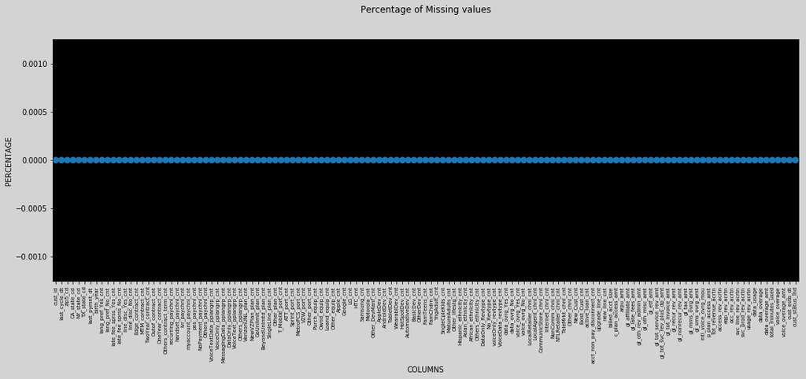

```python
fig = plt.figure(figsize=(18,6))
missing = pd.DataFrame((df.isnull().sum())*100/df.shape[0]).reset_index()
ax = sns.pointplot("index",0,data=missing)
plt.xticks(rotation =90,fontsize =7)
plt.title("Percentage of Missing values\n\n")
plt.ylabel("PERCENTAGE")
plt.xlabel("COLUMNS")
ax.set_facecolor("k")
fig.set_facecolor("lightgrey")
```

We Don't have any null values in the dataset.

## Feature Engineering:

#### We first take a sample of the data and work with it. We then use the same concept and apply feature engineering to the entire dataset.

```python
df['arpu_amt'].describe()
```

```
count    15516241.0
mean            NaN
std             NaN
min        -21280.0
25%            75.0
50%            90.0
75%           150.0
max         21456.0
Name: arpu_amt, dtype: float64
```

```python
df['arpu_class'] = 'MEDIUM'
df.loc[df['arpu_amt'] <= 75.0, 'arpu_class'] = 'LOW'
df.loc[df['arpu_amt'] >= 150.0, 'arpu_class'] = 'HIGH'
```

```python
df.arpu_class.value_counts()
```

```
MEDIUM    7047130
LOW       4266086
HIGH      4203025
Name: arpu_class, dtype: int64
```

```python
df_sample = df.sample(frac=0.1, replace=False, random_state=1)
```

```python
df_sample.head()
```

|  | cust_id | last_cycle_dt | zip5_cd | CA_state_cd | NY_state_cd | TX_state_cd | last_pymnt_dt | birth_year | lang_pref_Yes_cnt | lang_pref_No_cnt | ... | usage_rev_acrtn | data_usage | data_overage | data_overage_amt | total_minutes_used | voice_overage | voice_overage_amt | cust_estb_dt | cust_status_ind | arpu_class |
| --- | --- | --- | --- | --- | --- | --- | --- | --- | --- | --- | --- | --- | --- | --- | --- | --- | --- | --- | --- | --- | --- |
| 695388 | 688921586 | 2018-06-01 | 11693 | 0 | 2 | 0 | 2018-06-08 | 1996 | 0 | 0 | ... | 0.0 | 31.0 | 0.0 | 0.0 | 1012.0 | 0.0 | 0.0 | 2017-02-20 | 1 | HIGH |
| 853958 | 425311157 | 2019-02-01 | 90650 | 3 | 0 | 0 | 2019-02-28 | 1962 | 0 | 0 | ... | 0.0 | 36.0 | 0.0 | 0.0 | 5976.0 | 0.0 | 0.0 | 2017-03-21 | 1 | HIGH |
| 124464 | 825373036 | 2018-03-01 | 93701 | 1 | 0 | 0 | 2018-03-25 | 1988 | 0 | 0 | ... | 0.0 | 8.0 | 0.0 | 0.0 | 310.0 | 0.0 | 0.0 | 2017-07-06 | 0 | MEDIUM |
| 356308 | 625445644 | 2018-03-01 | 91935 | 1 | 0 | 0 | 2018-03-26 | 1912 | 0 | 0 | ... | 10.0 | 2.0 | 1.0 | 10.0 | 0.0 | 0.0 | 0.0 | 2017-11-15 | 1 | LOW |
| 983672 | 573336299 | 2019-03-01 | 90029 | 1 | 0 | 0 | 2019-03-03 | 1977 | 0 | 0 | ... | 0.0 | 7.0 | 0.0 | 0.0 | 176.0 | 0.0 | 0.0 | 2017-05-19 | 1 | MEDIUM |

5 rows × 130 columns

```python
df_sample = df_sample.reset_index()
```

```python
from sklearn.model_selection import train_test_split

X = pd.DataFrame(df_sample.drop(['cust_id','arpu_class','last_cycle_dt','last_pymnt_dt','cust_estb_dt','arpu_amt','lang_pref_No_cnt','late_fee_sprss_No_cnt','line_disc_No_cnt','Others_contract_term_cnt','Others_paychnl_cnt','Others_pplangrp_cnt','Other_plan_cnt','Other_port_cnt','Other_equip_cnt','Other_DevManf_cnt','OtherDev_cnt','Other_lifestg_cnt','Others_ethnicity_cnt','data_ovrg_No_cnt','voice_ovrg_No_cnt','Other_chnl_cnt','gl_tot_invoice_amt','gl_recur_rev_amt','gl_nonrecur_rev_amt','c_plan_access_amt','gl_affiliate_amt','gl_late_fees_amt','gl_oth_rev_admin_amt','gl_oth_misc_amt','gl_etf_amt','gl_tot_service_rev_amt','gl_tot_svc_rev_plus_dp_amt','gl_tax_amt','gl_mms_ovrg_amt','gl_sms_ovrg_amt','intl_voice_ovrg_mou','p_plan_access_amt','tot_revenue_acrtn','access_rev_acrtn','eqp_rev_acrtn','occ_rev_acrtn','svc_line_rev_acrtn','svc_prod_rev_acrtn','usage_rev_acrtn','data_overage_amt','voice_overage_amt','data_usage','data_overage','total_minutes_used','voice_overage'], axis = 'columns'))
y = df_sample['arpu_class']

X_train, X_test, y_train, y_test = train_test_split(X, y, test_size=0.3)
```

```python
X_train.columns
```

```
Index(['index', 'zip5_cd', 'CA_state_cd', 'NY_state_cd', 'TX_state_cd',
       'birth_year', 'lang_pref_Yes_cnt', 'late_fee_sprss_Yes_cnt',
       'line_disc_Yes_cnt', 'Edge_contract_cnt', 'MTM_contract_cnt',
       'TwoYear_contract_cnt', 'Outof_contract_cnt', 'OneYear_contract_cnt',
       'recurring_paychnl_cnt', 'handset_paychnl_cnt', 'ivr_paychnl_cnt',
       'myaccount_paychnl_cnt', 'pos_paychnl_cnt', 'NoPayment_paychnl_cnt',
       'VoiceTextData_pplangrp_cnt', 'VoiceOnly_pplangrp_cnt',
       'MessagingData_pplangrp_cnt', 'DataOnly_pplangrp_cnt',
       'VoiceText_pplangrp_cnt', 'VerizonUNL_plan_cnt', 'NewVZPlan_plan_cnt',
       'GoUnlimit_plan_cnt', 'BeyondUnlmtd_plan_cnt', 'SingleLine_plan_cnt',
       'T_Mobile_port_cnt', 'ATT_port_cnt', 'Sprint_port_cnt',
       'MetroPCS_port_cnt', 'VZW_port_cnt', 'Purch_equip_cnt',
       'Ownd_equip_cnt', 'Loand_equip_cnt', 'Apple_cnt', 'Google_cnt',
       'LG_cnt', 'HTC_cnt', 'Samsung_cnt', 'Motorola_cnt', 'AppleDev_cnt',
       'AndroidDev_cnt', 'TabletDev_cnt', 'WearablDev_cnt', 'HotSpotDev_cnt',
       'AutomativeDev_cnt', 'BasicDev_cnt', 'FamTeens_cnt', 'FamChdrn_cnt',
       'YngAdult_cnt', 'SngleCpleKids_cnt', 'MatureAdults_cnt',
       'Hispanic_ethnicity_cnt', 'Asian_ethnicity_cnt',
       'African_ethnicity_cnt', 'DataOnly_Revtype_cnt', 'No_Revtype_cnt',
       'voiceOnly_revtype_cnt', 'VoiceData_revtype_cnt', 'data_ovrg_Yes_cnt',
       'voice_ovrg_Yes_cnt', 'LocalRetailer_chnl_cnt', 'LocalAgent_chnl_cnt',
       'CommunicStore_chnl_cnt', 'Internet_chnl_cnt', 'NonComm_chnl_cnt',
       'NTLRetailer_chnl_cnt', 'TeleMrkt_chnl_cnt', 'New_Cust_cnt',
       'Exist_Cust_cnt', 'active_loan_cnt', 'acct_non_pay_disconnect_cnt',
       'upgrade_line_cnt', 'new_line_cnt', 'billed_acct_size',
       'cust_status_ind'],
      dtype='object')
```

```python
"""
from sklearn.preprocessing import StandardScaler
scaler = StandardScaler()
X_train = scaler.fit_transform(X_train)
"""
```

```
'\nfrom sklearn.preprocessing import StandardScaler \nscaler = StandardScaler()\nX_train = scaler.fit_transform(X_train)\n'
```

```python
X_train.head()
```

|  | index | zip5_cd | CA_state_cd | NY_state_cd | TX_state_cd | birth_year | lang_pref_Yes_cnt | late_fee_sprss_Yes_cnt | line_disc_Yes_cnt | Edge_contract_cnt | ... | NTLRetailer_chnl_cnt | TeleMrkt_chnl_cnt | New_Cust_cnt | Exist_Cust_cnt | active_loan_cnt | acct_non_pay_disconnect_cnt | upgrade_line_cnt | new_line_cnt | billed_acct_size | cust_status_ind |
| --- | --- | --- | --- | --- | --- | --- | --- | --- | --- | --- | --- | --- | --- | --- | --- | --- | --- | --- | --- | --- | --- |
| 833798 | 703727 | 12485 | 0 | 2 | 0 | 1951 | 0 | 0 | 0 | 0 | ... | 0 | 0 | 0 | 2 | 0 | 0 | 0 | 0 | 4 | 1 |
| 279739 | 311845 | 92386 | 1 | 0 | 0 | 1940 | 0 | 0 | 0 | 1 | ... | 0 | 0 | 0 | 1 | 1 | 0 | 0 | 0 | 1 | 1 |
| 1287721 | 260713 | 58703 | 0 | 1 | 0 | 1997 | 0 | 1 | 1 | 1 | ... | 1 | 0 | 0 | 1 | 1 | 0 | 0 | 0 | 1 | 0 |
| 1361535 | 461534 | 93458 | 1 | 0 | 0 | 1995 | 0 | 0 | 0 | 1 | ... | 0 | 0 | 0 | 1 | 1 | 0 | 0 | 0 | 1 | 1 |
| 648683 | 757537 | 12066 | 0 | 1 | 0 | 1963 | 0 | 0 | 0 | 0 | ... | 0 | 0 | 0 | 1 | 0 | 0 | 0 | 0 | 1 | 1 |

5 rows × 80 columns

```python
X_test.head()
```

|  | index | zip5_cd | CA_state_cd | NY_state_cd | TX_state_cd | birth_year | lang_pref_Yes_cnt | late_fee_sprss_Yes_cnt | line_disc_Yes_cnt | Edge_contract_cnt | ... | NTLRetailer_chnl_cnt | TeleMrkt_chnl_cnt | New_Cust_cnt | Exist_Cust_cnt | active_loan_cnt | acct_non_pay_disconnect_cnt | upgrade_line_cnt | new_line_cnt | billed_acct_size | cust_status_ind |
| --- | --- | --- | --- | --- | --- | --- | --- | --- | --- | --- | --- | --- | --- | --- | --- | --- | --- | --- | --- | --- | --- |
| 1550918 | 25782 | 95945 | 1 | 0 | 0 | 1977 | 0 | 1 | 1 | 0 | ... | 0 | 0 | 1 | 0 | 0 | 0 | 0 | 1 | 1 | 0 |
| 392064 | 777801 | 95117 | 1 | 0 | 0 | 1977 | 0 | 0 | 0 | 1 | ... | 0 | 0 | 0 | 1 | 1 | 0 | 0 | 0 | 1 | 1 |
| 1418891 | 442416 | 75165 | 0 | 0 | 4 | 1957 | 0 | 0 | 0 | 4 | ... | 0 | 0 | 0 | 4 | 16 | 0 | 0 | 0 | 16 | 1 |
| 607532 | 152758 | 13733 | 0 | 1 | 0 | 1942 | 0 | 0 | 0 | 1 | ... | 0 | 0 | 0 | 1 | 1 | 0 | 0 | 0 | 1 | 1 |
| 864814 | 507125 | 11209 | 0 | 1 | 0 | 1993 | 0 | 0 | 0 | 1 | ... | 0 | 0 | 0 | 1 | 1 | 0 | 0 | 0 | 1 | 1 |

5 rows × 80 columns

```python
X_train = X_train.reset_index()
X_test = X_test.reset_index()
```

```python
df.head()
```

|  | cust_id | last_cycle_dt | zip5_cd | CA_state_cd | NY_state_cd | TX_state_cd | last_pymnt_dt | birth_year | lang_pref_Yes_cnt | lang_pref_No_cnt | ... | usage_rev_acrtn | data_usage | data_overage | data_overage_amt | total_minutes_used | voice_overage | voice_overage_amt | cust_estb_dt | cust_status_ind | arpu_class |
| --- | --- | --- | --- | --- | --- | --- | --- | --- | --- | --- | --- | --- | --- | --- | --- | --- | --- | --- | --- | --- | --- |
| 0 | 873284714 | 2017-01-01 | 91204 | 4 | 0 | 0 | 2099-12-31 | 1979 | 0 | 0 | ... | 0.0 | 0.0 | 0.0 | 0.0 | 0.0 | 0.0 | 0.0 | 2017-01-13 | 0 | MEDIUM |
| 1 | 988895414 | 2017-01-01 | 19103 | 0 | 1 | 0 | 2017-01-09 | 1988 | 0 | 0 | ... | 0.0 | 0.0 | 0.0 | 0.0 | 0.0 | 0.0 | 0.0 | 2017-01-07 | 1 | LOW |
| 2 | 625265314 | 2017-01-01 | 75070 | 0 | 0 | 1 | 2099-12-31 | 1984 | 0 | 0 | ... | 0.0 | 0.0 | 0.0 | 0.0 | 0.0 | 0.0 | 0.0 | 2017-01-22 | 1 | MEDIUM |
| 3 | 473291754 | 2017-01-01 | 95219 | 2 | 0 | 0 | 2099-12-31 | 1985 | 0 | 0 | ... | 0.0 | 0.0 | 0.0 | 0.0 | 0.0 | 0.0 | 0.0 | 2017-01-31 | 0 | MEDIUM |
| 4 | 988892955 | 2017-01-01 | 11379 | 0 | 2 | 0 | 2099-12-31 | 1942 | 0 | 0 | ... | 0.0 | 0.0 | 0.0 | 0.0 | 0.0 | 0.0 | 0.0 | 2017-01-03 | 1 | MEDIUM |

5 rows × 130 columns

## We can group our customers into different cohorts and predict the Revenue for each cohort:

```python
df.head()
```

|  | cust_id | last_cycle_dt | zip5_cd | CA_state_cd | NY_state_cd | TX_state_cd | last_pymnt_dt | birth_year | lang_pref_Yes_cnt | lang_pref_No_cnt | ... | usage_rev_acrtn | data_usage | data_overage | data_overage_amt | total_minutes_used | voice_overage | voice_overage_amt | cust_estb_dt | cust_status_ind | arpu_class |
| --- | --- | --- | --- | --- | --- | --- | --- | --- | --- | --- | --- | --- | --- | --- | --- | --- | --- | --- | --- | --- | --- |
| 0 | 873284714 | 2017-01-01 | 91204 | 4 | 0 | 0 | 2099-12-31 | 1979 | 0 | 0 | ... | 0.0 | 0.0 | 0.0 | 0.0 | 0.0 | 0.0 | 0.0 | 2017-01-13 | 0 | MEDIUM |
| 1 | 988895414 | 2017-01-01 | 19103 | 0 | 1 | 0 | 2017-01-09 | 1988 | 0 | 0 | ... | 0.0 | 0.0 | 0.0 | 0.0 | 0.0 | 0.0 | 0.0 | 2017-01-07 | 1 | LOW |
| 2 | 625265314 | 2017-01-01 | 75070 | 0 | 0 | 1 | 2099-12-31 | 1984 | 0 | 0 | ... | 0.0 | 0.0 | 0.0 | 0.0 | 0.0 | 0.0 | 0.0 | 2017-01-22 | 1 | MEDIUM |
| 3 | 473291754 | 2017-01-01 | 95219 | 2 | 0 | 0 | 2099-12-31 | 1985 | 0 | 0 | ... | 0.0 | 0.0 | 0.0 | 0.0 | 0.0 | 0.0 | 0.0 | 2017-01-31 | 0 | MEDIUM |
| 4 | 988892955 | 2017-01-01 | 11379 | 0 | 2 | 0 | 2099-12-31 | 1942 | 0 | 0 | ... | 0.0 | 0.0 | 0.0 | 0.0 | 0.0 | 0.0 | 0.0 | 2017-01-03 | 1 | MEDIUM |

5 rows × 130 columns

```python
len(df)
```

```
15516241
```

```python
NOW = dt.datetime(2019,8,1) #Today's date (We take Aug 1, as we have data only until july 31)
```

```python
df['cust_id'].nunique()
```

```
758197
```

```python
df['cycle_dt'] = df['last_cycle_dt']
```

```python
#Creating the RFM table:
rfmTable = df.groupby('cust_id').agg({'last_cycle_dt': lambda x: (NOW - x.max()).days, # Recency
                                        'cycle_dt': lambda x: x.nunique(),      # Frequency
                                        'gl_tot_invoice_amt': lambda x: x.sum()}) # Monetary Value

rfmTable.rename(columns={'last_cycle_dt': 'recency',
                         'cycle_dt': 'frequency',
                         'gl_tot_invoice_amt': 'monetary_value'
                         }, inplace=True)
```

```python
def RScore(x,p,d):
    if x <= 60:
        return 1
    elif x <= d[p][0.50]:
        return 2
    elif x <= d[p][0.75]:
        return 3
    else:
        return 4

def FMScore(x,p,d):
    if x >= d[p][0.75]:
        return 1
    elif x <= d[p][0.25]:
        return 4
    elif x <= d[p][0.50]:
        return 3
    elif x <= d[p][0.75]:
        return 2
    else:
        return 1
```

```python
quantiles = rfmTable.quantile(q=[0.25,0.5,0.75])
quantiles
```

|  | recency | frequency | monetary_value |
| --- | --- | --- | --- |
| 0.25 | 31.0 | 17.0 | 1665.0 |
| 0.50 | 31.0 | 23.0 | 3080.0 |
| 0.75 | 273.0 | 27.0 | 5000.0 |

```python
rfmTable.head()
```

| cust_id | recency | frequency | monetary_value |
| --- | --- | --- | --- |
| 225250927 | 31 | 31 | 6860.0 |
| 225250931 | 243 | 24 | 3458.0 |
| 225250951 | 31 | 31 | 3216.0 |
| 225250958 | 31 | 31 | 3902.0 |
| 225250961 | 92 | 29 | 3782.0 |

```python
rfmTable['r_quartile'] = rfmTable['recency'].apply(RScore, args=('recency',quantiles,))
rfmTable['f_quartile'] = rfmTable['frequency'].apply(FMScore, args=('frequency',quantiles,))
rfmTable['m_quartile'] = rfmTable['monetary_value'].apply(FMScore, args=('monetary_value',quantiles,))
```

```python
rfmTable['RFMScore'] = rfmTable.r_quartile.map(str) \
                            + rfmTable.f_quartile.map(str) \
                            + rfmTable.m_quartile.map(str)
rfmTable.head()
```

| cust_id | recency | frequency | monetary_value | r_quartile | f_quartile | m_quartile | RFMScore |
| --- | --- | --- | --- | --- | --- | --- | --- |
| 225250927 | 31 | 31 | 6860.0 | 1 | 1 | 1 | 111 |
| 225250931 | 243 | 24 | 3458.0 | 3 | 2 | 2 | 322 |
| 225250951 | 31 | 31 | 3216.0 | 1 | 1 | 2 | 112 |
| 225250958 | 31 | 31 | 3902.0 | 1 | 1 | 2 | 112 |
| 225250961 | 92 | 29 | 3782.0 | 3 | 1 | 2 | 312 |

```python
rfmTable['Customer_Class'] = np.select([rfmTable.RFMScore == '111',  rfmTable.RFMScore == '311', rfmTable.RFMScore == '444', rfmTable.r_quartile == 4, rfmTable.f_quartile == 1, rfmTable.m_quartile == 1],
                        ['Best Customers','Almost Lost','Lost Cheap Customers','Lost Customers', 'Loyal Customers','Big Spenders'],
                        default='Average Customers')
```

```python
rfmTable.head()
```

| cust_id | recency | frequency | monetary_value | r_quartile | f_quartile | m_quartile | RFMScore | Customer_Class |
| --- | --- | --- | --- | --- | --- | --- | --- | --- |
| 225250927 | 31 | 31 | 6860.0 | 1 | 1 | 1 | 111 | Best Customers |
| 225250931 | 243 | 24 | 3458.0 | 3 | 2 | 2 | 322 | Average Customers |
| 225250951 | 31 | 31 | 3216.0 | 1 | 1 | 2 | 112 | Loyal Customers |
| 225250958 | 31 | 31 | 3902.0 | 1 | 1 | 2 | 112 | Loyal Customers |
| 225250961 | 92 | 29 | 3782.0 | 3 | 1 | 2 | 312 | Loyal Customers |

```python
rfmTable['Customer_Class'].value_counts()
```

```
Average Customers       263030
Lost Cheap Customers    148495
Loyal Customers         123193
Big Spenders             98415
Best Customers           87303
Lost Customers           36222
Almost Lost               1539
Name: Customer_Class, dtype: int64
```

#### We now have 7 classes of customers:

```
Average Customers
Lost Cheap Customers
Loyal Customers
Big Spenders
Best Customers
Lost Customers
Almost Lost
```

Let us build a Forecast model to forecast the revenue of each of these classes of Users:  
We shall first create a train and test set!

```python
seg = pd.merge(df, rfmTable, on='cust_id')
```

### Let's create separate dataframes for each of the customer segments:

```python
seg.columns
```

```
Index(['cust_id', 'last_cycle_dt', 'zip5_cd', 'CA_state_cd', 'NY_state_cd',
       'TX_state_cd', 'last_pymnt_dt', 'birth_year', 'lang_pref_Yes_cnt',
       'lang_pref_No_cnt',
       ...
       'arpu_class', 'cycle_dt', 'recency', 'frequency', 'monetary_value',
       'r_quartile', 'f_quartile', 'm_quartile', 'RFMScore', 'Customer_Class'],
      dtype='object', length=139)
```

```python
df_new = seg[['Customer_Class','last_cycle_dt','gl_tot_invoice_amt','arpu_amt']]
```

```python
df_new['Customer_Class'].value_counts()
```

```
Average Customers       5835838
Loyal Customers         3554974
Best Customers          2529036
Big Spenders            2264867
Lost Cheap Customers     803801
Lost Customers           484748
Almost Lost               42977
Name: Customer_Class, dtype: int64
```

## Creating Dataframe for Best Customers:

```python
df_best = df_new[df_new['Customer_Class'] == 'Best Customers']
```

```python
df_best.head()
```

|  | Customer_Class | last_cycle_dt | gl_tot_invoice_amt | arpu_amt |
| --- | --- | --- | --- | --- |
| 33 | Best Customers | 2017-01-01 | 181.125 | 90.0 |
| 34 | Best Customers | 2017-02-01 | 265.750 | 133.0 |
| 35 | Best Customers | 2017-04-01 | 335.750 | 230.0 |
| 36 | Best Customers | 2017-03-01 | 254.500 | 155.0 |
| 37 | Best Customers | 2017-05-01 | 352.000 | 245.0 |

```python
df_best = df_best.drop('Customer_Class', axis = 1)
```

```python
df_best['month_year'] = df_best['last_cycle_dt'].dt.to_period('M')
```

## Creating Dataframes for all the other classes of Users:

```python
df_avg =  df_new[df_new['Customer_Class'] == 'Average Customers']
df_avg = df_avg.drop('Customer_Class', axis = 1)
df_avg['month_year'] = df_avg['last_cycle_dt'].dt.to_period('M')
```

```python
df_loyal =  df_new[df_new['Customer_Class'] == 'Loyal Customers']
df_loyal = df_loyal.drop('Customer_Class', axis = 1)
df_loyal['month_year'] = df_loyal['last_cycle_dt'].dt.to_period('M')
```

```python
df_big =  df_new[df_new['Customer_Class'] == 'Big Spenders']
df_big = df_big.drop('Customer_Class', axis = 1)
df_big['month_year'] = df_big['last_cycle_dt'].dt.to_period('M')
```

```python
df_lost_cheap =  df_new[df_new['Customer_Class'] == 'Lost Cheap Customers']
df_lost_cheap = df_lost_cheap.drop('Customer_Class', axis = 1)
df_lost_cheap['month_year'] = df_lost_cheap['last_cycle_dt'].dt.to_period('M')
```

```python
df_almost_lost =  df_new[df_new['Customer_Class'] == 'Almost Lost']
df_almost_lost = df_almost_lost.drop('Customer_Class', axis = 1)
df_almost_lost['month_year'] = df_almost_lost['last_cycle_dt'].dt.to_period('M')
```

```python
df_lost =  df_new[df_new['Customer_Class'] == 'Lost Customers']
df_lost = df_lost.drop('Customer_Class', axis = 1)
df_lost['month_year'] = df_lost['last_cycle_dt'].dt.to_period('M')
```

```python
df_best['arpu_amt1'] = df_best['arpu_amt']
df_best['arpu_amt2'] = df_best['arpu_amt']
```

```python
df_best['arpu_amt'] = df_best['arpu_amt'].astype(np.float64)
df_best['arpu_amt1'] = df_best['arpu_amt1'].astype(np.float64)
df_best['arpu_amt2'] = df_best['arpu_amt2'].astype(np.float64)
```

```python
df_best = df_best.groupby('month_year').agg({'arpu_amt': lambda x: np.mean(x), # ARPU avg for entire group
                                        'arpu_amt1': lambda x: x.max(),      # High ARPU
                                        'arpu_amt2': lambda x: x.min()}) # Low ARPU

df_best.rename(columns={'arpu_amt': 'Price',
                         'arpu_amt1': 'High',
                         'arpu_amt2': 'Low'
                         }, inplace=True)
```

```python
df_best.head()
```

| month_year | Price | High | Low |
| --- | --- | --- | --- |
| 2017-01 | 111.875826 | 493.0 | -88.0 |
| 2017-02 | 134.200062 | 1285.0 | -503.0 |
| 2017-03 | 138.770586 | 1823.0 | -1080.0 |
| 2017-04 | 142.375122 | 2672.0 | -1985.0 |
| 2017-05 | 145.964600 | 4168.0 | -2444.0 |

```python
df_avg['arpu_amt1'] = df_avg['arpu_amt']
df_avg['arpu_amt2'] = df_avg['arpu_amt']
```

```python
df_avg['arpu_amt'] = df_avg['arpu_amt'].astype(np.float64)
df_avg['arpu_amt1'] = df_avg['arpu_amt1'].astype(np.float64)
df_avg['arpu_amt2'] = df_avg['arpu_amt2'].astype(np.float64)
```

```python
df_avg = df_avg.groupby('month_year').agg({'arpu_amt': lambda x: np.mean(x), # ARPU avg for entire group
                                        'arpu_amt1': lambda x: x.max(),      # High ARPU
                                        'arpu_amt2': lambda x: x.min()}) # Low ARPU

df_avg.rename(columns={'arpu_amt': 'Price',
                         'arpu_amt1': 'High',
                         'arpu_amt2': 'Low'
                         }, inplace=True)
```

```python
df_loyal['arpu_amt1'] = df_loyal['arpu_amt']
df_loyal['arpu_amt2'] = df_loyal['arpu_amt']

df_loyal['arpu_amt'] = df_loyal['arpu_amt'].astype(np.float64)
df_loyal['arpu_amt1'] = df_loyal['arpu_amt1'].astype(np.float64)
df_loyal['arpu_amt2'] = df_loyal['arpu_amt2'].astype(np.float64)

df_loyal = df_loyal.groupby('month_year').agg({'arpu_amt': lambda x: np.mean(x), # ARPU avg for entire group
                                        'arpu_amt1': lambda x: x.max(),      # High ARPU
                                        'arpu_amt2': lambda x: x.min()}) # Low ARPU

df_loyal.rename(columns={'arpu_amt': 'Price',
                         'arpu_amt1': 'High',
                         'arpu_amt2': 'Low'
                         }, inplace=True)
```

```python
df_big['arpu_amt1'] = df_big['arpu_amt']
df_big['arpu_amt2'] = df_big['arpu_amt']

df_big['arpu_amt'] = df_big['arpu_amt'].astype(np.float64)
df_big['arpu_amt1'] = df_big['arpu_amt1'].astype(np.float64)
df_big['arpu_amt2'] = df_big['arpu_amt2'].astype(np.float64)

df_big = df_big.groupby('month_year').agg({'arpu_amt': lambda x: np.mean(x), # ARPU avg for entire group
                                        'arpu_amt1': lambda x: x.max(),      # High ARPU
                                        'arpu_amt2': lambda x: x.min()}) # Low ARPU

df_big.rename(columns={'arpu_amt': 'Price',
                         'arpu_amt1': 'High',
                         'arpu_amt2': 'Low'
                         }, inplace=True)
```

```python
df_lost_cheap['arpu_amt1'] = df_lost_cheap['arpu_amt']
df_lost_cheap['arpu_amt2'] = df_lost_cheap['arpu_amt']

df_lost_cheap['arpu_amt'] = df_lost_cheap['arpu_amt'].astype(np.float64)
df_lost_cheap['arpu_amt1'] = df_lost_cheap['arpu_amt1'].astype(np.float64)
df_lost_cheap['arpu_amt2'] = df_lost_cheap['arpu_amt2'].astype(np.float64)

df_lost_cheap = df_lost_cheap.groupby('month_year').agg({'arpu_amt': lambda x: np.mean(x), # ARPU avg for entire group
                                        'arpu_amt1': lambda x: x.max(),      # High ARPU
                                        'arpu_amt2': lambda x: x.min()}) # Low ARPU

df_lost_cheap.rename(columns={'arpu_amt': 'Price',
                         'arpu_amt1': 'High',
                         'arpu_amt2': 'Low'
                         }, inplace=True)
```

```python
df_lost['arpu_amt1'] = df_lost['arpu_amt']
df_lost['arpu_amt2'] = df_lost['arpu_amt']

df_lost['arpu_amt'] = df_lost['arpu_amt'].astype(np.float64)
df_lost['arpu_amt1'] = df_lost['arpu_amt1'].astype(np.float64)
df_lost['arpu_amt2'] = df_lost['arpu_amt2'].astype(np.float64)

df_lost = df_lost.groupby('month_year').agg({'arpu_amt': lambda x: np.mean(x), # ARPU avg for entire group
                                        'arpu_amt1': lambda x: x.max(),      # High ARPU
                                        'arpu_amt2': lambda x: x.min()}) # Low ARPU

df_lost.rename(columns={'arpu_amt': 'Price',
                         'arpu_amt1': 'High',
                         'arpu_amt2': 'Low'
                         }, inplace=True)
```

```python
df_almost_lost['arpu_amt1'] = df_almost_lost['arpu_amt']
df_almost_lost['arpu_amt2'] = df_almost_lost['arpu_amt']

df_almost_lost['arpu_amt'] = df_almost_lost['arpu_amt'].astype(np.float64)
df_almost_lost['arpu_amt1'] = df_almost_lost['arpu_amt1'].astype(np.float64)
df_almost_lost['arpu_amt2'] = df_almost_lost['arpu_amt2'].astype(np.float64)

df_almost_lost = df_almost_lost.groupby('month_year').agg({'arpu_amt': lambda x: np.mean(x), # ARPU avg for entire group
                                        'arpu_amt1': lambda x: x.max(),      # High ARPU
                                        'arpu_amt2': lambda x: x.min()}) # Low ARPU

df_almost_lost.rename(columns={'arpu_amt': 'Price',
                         'arpu_amt1': 'High',
                         'arpu_amt2': 'Low'
                         }, inplace=True)
```

```python
df_avg.head()
```

| month_year | Price | High | Low |
| --- | --- | --- | --- |
| 2017-01 | 72.526990 | 235.00 | 0.00 |
| 2017-02 | 81.695657 | 451.75 | -80.00 |
| 2017-03 | 79.839722 | 1148.00 | -512.00 |
| 2017-04 | 81.616164 | 615.00 | -165.75 |
| 2017-05 | 82.261888 | 5336.00 | -786.50 |

```python
df_best.head()
```

| month_year | Price | High | Low |
| --- | --- | --- | --- |
| 2017-01 | 111.875826 | 493.0 | -88.0 |
| 2017-02 | 134.200062 | 1285.0 | -503.0 |
| 2017-03 | 138.770586 | 1823.0 | -1080.0 |
| 2017-04 | 142.375122 | 2672.0 | -1985.0 |
| 2017-05 | 145.964600 | 4168.0 | -2444.0 |

```python
df_lost.head()
```

| month_year | Price | High | Low |
| --- | --- | --- | --- |
| 2017-01 | 93.243626 | 460.0 | -165.0 |
| 2017-02 | 118.145424 | 3572.0 | -279.5 |
| 2017-03 | 118.763747 | 3272.0 | -234.0 |
| 2017-04 | 122.296102 | 5648.0 | -840.0 |
| 2017-05 | 126.379267 | 3838.0 | -735.5 |

```python
df_lost_cheap.head()
```

| month_year | Price | High | Low |
| --- | --- | --- | --- |
| 2017-01 | 74.681627 | 760.0 | -84.0 |
| 2017-02 | 79.609748 | 1634.0 | -1858.0 |
| 2017-03 | 72.032927 | 1971.0 | -1066.0 |
| 2017-04 | 70.918895 | 1215.0 | -1753.0 |
| 2017-05 | 72.302761 | 1304.0 | -1095.0 |

```python
df_loyal.head()
```

| month_year | Price | High | Low |
| --- | --- | --- | --- |
| 2017-01 | 69.341225 | 265.0 | -70.00 |
| 2017-02 | 75.231422 | 850.0 | -458.25 |
| 2017-03 | 74.676790 | 975.0 | -481.00 |
| 2017-04 | 75.700776 | 933.0 | -831.00 |
| 2017-05 | 76.308343 | 1276.0 | -688.00 |

```python
df_big.head()
```

| month_year | Price | High | Low |
| --- | --- | --- | --- |
| 2017-01 | 119.311006 | 430.0 | -22.015625 |
| 2017-02 | 144.548767 | 1422.0 | -80.000000 |
| 2017-03 | 148.041186 | 1426.0 | -1062.000000 |
| 2017-04 | 153.032538 | 1542.0 | -142.375000 |
| 2017-05 | 155.254614 | 819.5 | -1176.000000 |

```python
df_almost_lost.head()
```

| month_year | Price | High | Low |
| --- | --- | --- | --- |
| 2017-01 | 111.752105 | 265.0 | -20.000 |
| 2017-02 | 138.514227 | 727.5 | -143.250 |
| 2017-03 | 142.281680 | 1566.0 | -153.625 |
| 2017-04 | 147.926434 | 658.0 | -185.000 |
| 2017-05 | 149.684237 | 583.5 | -240.000 |

## Now we have 7 dataframes with the data indexed with datetime. We can Now start to build a forecast model to predict the revenue of each segment of users.

## Average Customer Behaviour:

```python
df_avg['Change%'] = (df_avg['Price'] - df_avg['Price'].shift(1)) * 100 /df_avg['Price'].shift(1)
```

```python
df_avg = df_avg.sort_index(axis=1, ascending=True)
df_avg = df_avg.iloc[::-1]
```

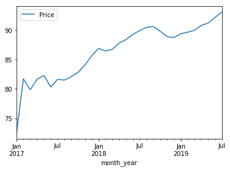

```python
data_avg = df_avg[['Price']]
data_avg.plot(y='Price')
```

## Best Customers Behaviour:

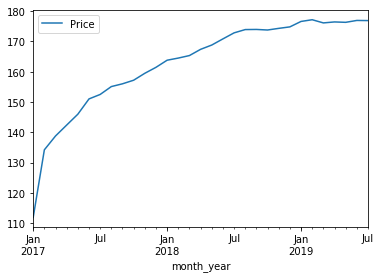

```python
df_best['Change%'] = (df_best['Price'] - df_best['Price'].shift(1)) * 100 /df_best['Price'].shift(1)
df_best = df_best.sort_index(axis=1, ascending=True)
df_best = df_best.iloc[::-1]

data_best = df_best[['Price']]
data_best.plot(y='Price')
```

## Lost Customers Behaviour:

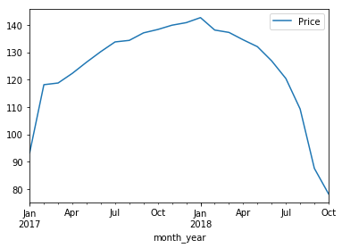

```python
df_lost['Change%'] = (df_lost['Price'] - df_lost['Price'].shift(1)) * 100 /df_lost['Price'].shift(1)
df_lost = df_lost.sort_index(axis=1, ascending=True)
df_lost = df_lost.iloc[::-1]

data_lost = df_lost[['Price']]
data_lost.plot(y='Price')
```

## Loyal Customers Behaviour:

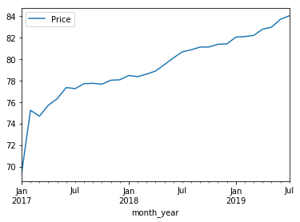

```python
df_loyal['Change%'] = (df_loyal['Price'] - df_loyal['Price'].shift(1)) * 100 /df_loyal['Price'].shift(1)
df_loyal = df_loyal.sort_index(axis=1, ascending=True)
df_loyal = df_loyal.iloc[::-1]

data_loyal = df_loyal[['Price']]
data_loyal.plot(y='Price')
```

## Big Spenders Behaviour:

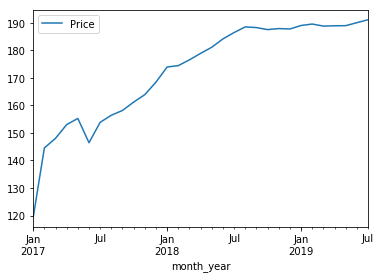

```python
df_big['Change%'] = (df_big['Price'] - df_big['Price'].shift(1)) * 100 /df_big['Price'].shift(1)
df_big = df_big.sort_index(axis=1, ascending=True)
df_big = df_big.iloc[::-1]

data_big = df_big[['Price']]
data_big.plot(y='Price')
```

## Almost Lost Customers Behaviour:

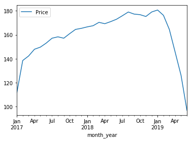

```python
df_almost_lost['Change%'] = (df_almost_lost['Price'] - df_almost_lost['Price'].shift(1)) * 100 /df_almost_lost['Price'].shift(1)
df_almost_lost = df_almost_lost.sort_index(axis=1, ascending=True)
df_almost_lost = df_almost_lost.iloc[::-1]

data_almost_lost = df_almost_lost[['Price']]
data_almost_lost.plot(y='Price')
```

## Lost Cheap Customers Behaviour:

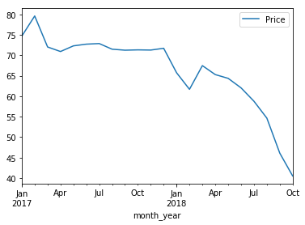

```python
df_lost_cheap['Change%'] = (df_lost_cheap['Price'] - df_lost_cheap['Price'].shift(1)) * 100 /df_lost_cheap['Price'].shift(1)
df_lost_cheap = df_lost_cheap.sort_index(axis=1, ascending=True)
df_lost_cheap = df_lost_cheap.iloc[::-1]

data_lost_cheap = df_lost_cheap[['Price']]
data_lost_cheap.plot(y='Price')
```

### Let us start with the Average Customers dataset and build a model only for that. We Shall fine tune this model to attain better accuracies and then employ that model for the rest of the datasets.

## Create training and testing data:

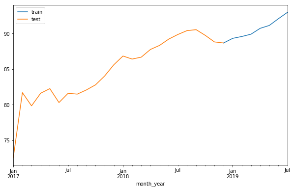

```python
split_date = pd.Timestamp('12-31-2018')

train_avg = data_avg.loc[:split_date]
test_avg = data_avg.loc[split_date:]

ax = train_avg.plot(figsize=(10,6))
test_avg.plot(ax=ax)
plt.legend(['train', 'test'])
plt.show()
```

## Normalize the dataset

```python
from sklearn.preprocessing import MinMaxScaler
sc = MinMaxScaler()
train_avg_sc = sc.fit_transform(train_avg)
test_avg_sc = sc.transform(test_avg)
```

```python
train_avg_sc_df = pd.DataFrame(train_avg_sc, columns=['Y'], index=train_avg.index)
test_avg_sc_df = pd.DataFrame(test_avg_sc, columns=['Y'], index=test_avg.index)

for s in range(1,2):
    train_avg_sc_df['X_{}'.format(s)] = train_avg_sc_df['Y'].shift(s)
    test_avg_sc_df['X_{}'.format(s)] = test_avg_sc_df['Y'].shift(s)

X_train_avg = train_avg_sc_df.dropna().drop('Y', axis=1)
y_train_avg = train_avg_sc_df.dropna().drop('X_1', axis=1)

X_test_avg = test_avg_sc_df.dropna().drop('Y', axis=1)
y_test_avg = test_avg_sc_df.dropna().drop('X_1', axis=1)

X_train_avg = X_train_avg.as_matrix()
y_train_avg = y_train_avg.as_matrix()

X_test_avg = X_test_avg.as_matrix()
y_test_avg = y_test_avg.as_matrix()
```

```python
print('Train size: (%d x %d)'%(X_train_avg.shape[0], X_train_avg.shape[1]))
print('Test size: (%d x %d)'%(X_test_avg.shape[0], X_test_avg.shape[1]))
```

```
Train size: (7 x 1)
Test size: (23 x 1)
```

```python
X_train_avg
```

```
array([[1.        ],
       [0.7908248 ],
       [0.57015432],
       [0.47660242],
       [0.28585489],
       [0.21106682],
       [0.15066203]])
```

## Setup baseline model of SVM Regressor

```python
from sklearn.svm import SVR
regressor = SVR(kernel='rbf')
```

```python
regressor.fit(X_train_avg, y_train_avg)
y_pred_avg = regressor.predict(X_test_avg)
```

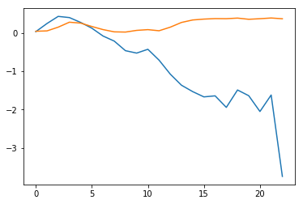

```python
plt.plot(y_test_avg)
plt.plot(y_pred_avg)
```

```python
from sklearn.metrics import r2_score

def adj_r2_score(r2, n, k):
    return 1-((1-r2)*((n-1)/(n-k-1)))

r2_test = r2_score(y_test_avg, y_pred_avg)
print("R-squared is: %f"%r2_test)
```

```
R-squared is: -1.433378
```

## Building a Neural Network

```python
from keras.models import Sequential
from keras.layers import Dense
from keras.optimizers import Adam
import keras.backend as K
```

### 1 hidden layer with 1 neuron

```python
K.clear_session()
model = Sequential()
model.add(Dense(1, input_shape=(X_test_avg.shape[1],), activation='tanh', kernel_initializer='lecun_uniform'))
model.compile(optimizer=Adam(lr=0.001), loss='mean_squared_error')
model.fit(X_train_avg, y_train_avg, batch_size=16, epochs=20, verbose=1)
```

[output not shown]

```
<keras.callbacks.History at 0x23e7fffc0b8>
```

```
R-Squared: 0.464624
```

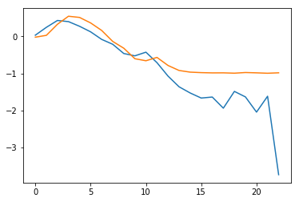

```python
y_pred_avg = model.predict(X_test_avg)
plt.plot(y_test_avg)
plt.plot(y_pred_avg)
print('R-Squared: %f'%(r2_score(y_test_avg, y_pred_avg)))
```

### 2 Hidden Layers with 50 neurons each and ReLU activation function

```python
K.clear_session()
model = Sequential()
model.add(Dense(50, input_shape=(X_test_avg.shape[1],), activation='relu', kernel_initializer='lecun_uniform'))
model.add(Dense(50, input_shape=(X_test_avg.shape[1],), activation='relu'))
model.add(Dense(1))
model.compile(optimizer=Adam(lr=0.001), loss='mean_squared_error')
model.fit(X_train_avg, y_train_avg, batch_size=16, epochs=20, verbose=1)
```

```
<keras.callbacks.History at 0x23e81880400>
```

```
R-Squared: -3.305321
```

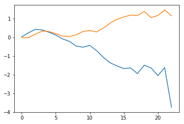

```python
y_pred_avg = model.predict(X_test_avg)
plt.plot(y_test_avg)
plt.plot(y_pred_avg)
print('R-Squared: %f'%(r2_score(y_test_avg, y_pred_avg)))
```

### 3 Hidden Layers with 100 neurons each and ReLU activation function

```python
K.clear_session()
model = Sequential()
model.add(Dense(100, input_shape=(X_test_avg.shape[1],), activation='relu', kernel_initializer='lecun_uniform'))
model.add(Dense(100, input_shape=(X_test_avg.shape[1],), activation='relu'))
model.add(Dense(100, input_shape=(X_test_avg.shape[1],), activation='relu'))
model.add(Dense(1))
model.compile(optimizer=Adam(lr=0.001), loss='mean_squared_error')
model.fit(X_train_avg, y_train_avg, batch_size=16, epochs=20, verbose=1)
```

```
<keras.callbacks.History at 0x23e97051ac8>
```

```
R-Squared: -2.481119
```

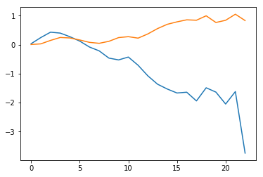

```python
y_pred_avg = model.predict(X_test_avg)
plt.plot(y_test_avg)
plt.plot(y_pred_avg)
print('R-Squared: %f'%(r2_score(y_test_avg, y_pred_avg)))
```

### 4 Hidden Layers with 200 neurons each and ReLU activation function

```python
K.clear_session()
model = Sequential()
model.add(Dense(200, input_shape=(X_test_avg.shape[1],), activation='relu', kernel_initializer='lecun_uniform'))
model.add(Dense(200, input_shape=(X_test_avg.shape[1],), activation='relu'))
model.add(Dense(200, input_shape=(X_test_avg.shape[1],), activation='relu'))
model.add(Dense(200, input_shape=(X_test_avg.shape[1],), activation='relu'))
model.add(Dense(1))
model.compile(optimizer=Adam(lr=0.001), loss='mean_squared_error')
model.fit(X_train_avg, y_train_avg, batch_size=16, epochs=20, verbose=1)
```

```
<keras.callbacks.History at 0x23e97623438>
```

```
R-Squared: -2.480859
```

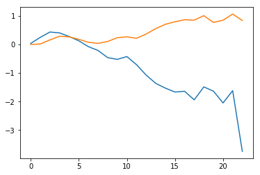

```python
y_pred_avg = model.predict(X_test_avg)
plt.plot(y_test_avg)
plt.plot(y_pred_avg)
print('R-Squared: %f'%(r2_score(y_test_avg, y_pred_avg)))
```

## Buiding an LSTM for Forecasting Revenue:

```python
import keras
from keras.models import Sequential
from keras.layers import Dense
from keras.layers import LSTM
from keras.layers import Dropout
from sklearn.preprocessing import MinMaxScaler
from sklearn.metrics import mean_squared_error
from sklearn.metrics import mean_absolute_error
from keras.callbacks import EarlyStopping
```

```python
df_avg.head()
```

| month_year | Change% | High | Low | Price |
| --- | --- | --- | --- | --- |
| 2019-07 | 0.981070 | 1339.0 | -2070.0 | 93.002112 |
| 2019-06 | 1.045809 | 1161.0 | -3202.0 | 92.098560 |
| 2019-05 | 0.445339 | 3358.0 | -1263.0 | 91.145353 |
| 2019-04 | 0.916344 | 1243.0 | -1009.0 | 90.741247 |
| 2019-03 | 0.360575 | 1592.0 | -5144.0 | 89.917296 |

```python
df_avg = df_avg.reset_index()
```

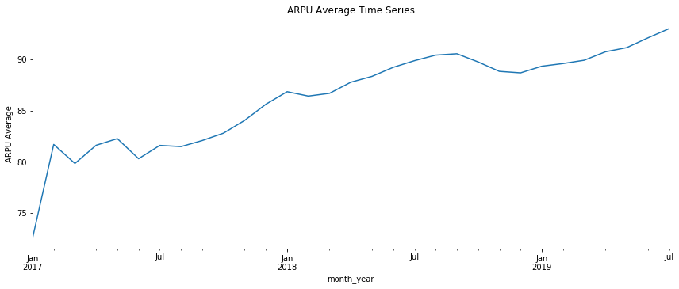

```python
df_avg=df_avg.loc[:,['month_year','Price']]
df_avg.set_index('month_year',inplace=True)
df_avg.plot(figsize=(12,5))
plt.ylabel('ARPU Average')
plt.legend().set_visible(False)
plt.tight_layout()
plt.title('ARPU Average Time Series')
sns.despine(top=True)
plt.show();
```

```python
df_avg
```

| month_year | Price |
| --- | --- |
| 2019-07 | 93.002112 |
| 2019-06 | 92.098560 |
| 2019-05 | 91.145353 |
| 2019-04 | 90.741247 |
| 2019-03 | 89.917296 |
| 2019-02 | 89.594242 |
| 2019-01 | 89.333317 |
| 2018-12 | 88.682519 |
| 2018-11 | 88.830106 |
| 2018-10 | 89.749961 |
| 2018-09 | 90.551838 |
| 2018-08 | 90.417575 |
| 2018-07 | 89.872715 |
| 2018-06 | 89.224752 |
| 2018-05 | 88.341083 |
| 2018-04 | 87.769160 |
| 2018-03 | 86.689108 |
| 2018-02 | 86.417546 |
| 2018-01 | 86.846087 |
| 2017-12 | 85.621138 |
| 2017-11 | 84.048214 |
| 2017-10 | 82.797537 |
| 2017-09 | 82.077817 |
| 2017-08 | 81.484790 |
| 2017-07 | 81.602022 |
| 2017-06 | 80.301434 |
| 2017-05 | 82.261888 |
| 2017-04 | 81.616164 |
| 2017-03 | 79.839722 |
| 2017-02 | 81.695657 |
| 2017-01 | 72.526990 |

```python
dataset = df_avg.Price.values #numpy.ndarray
dataset = dataset.astype('float32')
dataset = np.reshape(dataset, (-1, 1))
scaler = MinMaxScaler(feature_range=(0, 1))
dataset = scaler.fit_transform(dataset)
train_size = int(len(dataset) * 0.80)
test_size = len(dataset) - train_size
train, test = dataset[0:train_size,:], dataset[train_size:len(dataset),:]
```

```python
from pandas import DataFrame
from pandas import Series
from pandas import concat
from pandas import read_csv
from pandas import datetime
from sklearn.metrics import mean_squared_error
from sklearn.preprocessing import MinMaxScaler
from keras.models import Sequential
from keras.layers import Dense
from keras.layers import LSTM
from math import sqrt
from matplotlib import pyplot
import numpy
```

```python
# date-time parsing function for loading the dataset
def parser(x):
	return datetime.strptime(x, '%Y-%m')

# frame a sequence as a supervised learning problem
def timeseries_to_supervised(data, lag=1):
	df = DataFrame(data)
	columns = [df.shift(i) for i in range(1, lag+1)]
	columns.append(df)
	df = concat(columns, axis=1)
	df.fillna(0, inplace=True)
	return df

# create a differenced series
def difference(dataset, interval=1):
	diff = list()
	for i in range(interval, len(dataset)):
		value = dataset[i] - dataset[i - interval]
		diff.append(value)
	return Series(diff)

# invert differenced value
def inverse_difference(history, yhat, interval=1):
	return yhat + history[-interval]

# scale train and test data to [-1, 1]
def scale(train, test):
	# fit scaler
	scaler = MinMaxScaler(feature_range=(-1, 1))
	scaler = scaler.fit(train)
	# transform train
	train = train.reshape(train.shape[0], train.shape[1])
	train_scaled = scaler.transform(train)
	# transform test
	test = test.reshape(test.shape[0], test.shape[1])
	test_scaled = scaler.transform(test)
	return scaler, train_scaled, test_scaled

# inverse scaling for a forecasted value
def invert_scale(scaler, X, value):
	new_row = [x for x in X] + [value]
	array = numpy.array(new_row)
	array = array.reshape(1, len(array))
	inverted = scaler.inverse_transform(array)
	return inverted[0, -1]

# fit an LSTM network to training data
def fit_lstm(train, batch_size, nb_epoch, neurons):
	X, y = train[:, 0:-1], train[:, -1]
	X = X.reshape(X.shape[0], 1, X.shape[1])
	model = Sequential()
	model.add(LSTM(neurons, batch_input_shape=(batch_size, X.shape[1], X.shape[2]), stateful=True))
	model.add(Dense(1))
	model.compile(loss='mean_squared_error', optimizer='adam')
	for i in range(nb_epoch):
		model.fit(X, y, epochs=1, batch_size=batch_size, verbose=0, shuffle=False)
		model.reset_states()
	return model

# make a one-step forecast
def forecast_lstm(model, batch_size, X):
	X = X.reshape(1, 1, len(X))
	yhat = model.predict(X, batch_size=batch_size)
	return yhat[0,0]
```

```python
series = df_avg
```

```python
# transform data to be stationary
raw_values = series.values
diff_values = difference(raw_values, 1)
```

```python
# transform data to be supervised learning
supervised = timeseries_to_supervised(diff_values, 1)
supervised_values = supervised.values
```

```python
print(supervised_values)
```

```
[[0 array([-0.90355177])]
 [array([-0.90355177]) array([-0.95320666])]
 [array([-0.95320666]) array([-0.40410617])]
 [array([-0.40410617]) array([-0.82395173])]
 [array([-0.82395173]) array([-0.32305401])]
 [array([-0.32305401]) array([-0.26092409])]
 [array([-0.26092409]) array([-0.65079869])]
 [array([-0.65079869]) array([0.14758716])]
 [array([0.14758716]) array([0.9198546])]
 [array([0.9198546]) array([0.80187759])]
 [array([0.80187759]) array([-0.13426356])]
 [array([-0.13426356]) array([-0.54485979])]
 [array([-0.54485979]) array([-0.64796324])]
 [array([-0.64796324]) array([-0.88366833])]
 [array([-0.88366833]) array([-0.57192317])]
 [array([-0.57192317]) array([-1.08005192])]
 [array([-1.08005192]) array([-0.27156244])]
 [array([-0.27156244]) array([0.42854102])]
 [array([0.42854102]) array([-1.22494861])]
 [array([-1.22494861]) array([-1.57292369])]
 [array([-1.57292369]) array([-1.25067789])]
 [array([-1.25067789]) array([-0.71971986])]
 [array([-0.71971986]) array([-0.59302644])]
 [array([-0.59302644]) array([0.11723178])]
 [array([0.11723178]) array([-1.30058795])]
 [array([-1.30058795]) array([1.9604535])]
 [array([1.9604535]) array([-0.64572403])]
 [array([-0.64572403]) array([-1.77644183])]
 [array([-1.77644183]) array([1.85593498])]
 [array([1.85593498]) array([-9.16866636])]]
```

```python
supervised_values.shape
```

```
(30, 2)
```

```python
# split data into train and test-sets
train, test = supervised_values[0:-6], supervised_values[-6:]

# transform the scale of the data
scaler, train_scaled, test_scaled = scale(train, test)
```

```python
train_scaled
```

```
array([[ 0.26198443, -0.4629511 ],
       [-0.4629511 , -0.50279009],
       [-0.50279009, -0.06223708],
       [-0.06223708, -0.39908658],
       [-0.39908658,  0.00279249],
       [ 0.00279249,  0.05264042],
       [ 0.05264042, -0.26016284],
       [-0.26016284,  0.38039621],
       [ 0.38039621,  1.        ],
       [ 1.        ,  0.90534496],
       [ 0.90534496,  0.15426241],
       [ 0.15426241, -0.17516619],
       [-0.17516619, -0.25788791],
       [-0.25788791, -0.44699827],
       [-0.44699827, -0.19687962],
       [-0.19687962, -0.60456028],
       [-0.60456028,  0.04410509],
       [ 0.04410509,  0.60581044],
       [ 0.60581044, -0.72081345],
       [-0.72081345, -1.        ],
       [-1.        , -0.74145651],
       [-0.74145651, -0.31545951],
       [-0.31545951, -0.21381115],
       [-0.21381115,  0.35604155]])
```

```python
test_scaled
```

```
array([[ 0.35604155, -0.78150023],
       [-0.78150023,  1.83489086],
       [ 1.83489086, -0.25609135],
       [-0.25609135, -1.16328619],
       [-1.16328619,  1.75103381],
       [ 1.75103381, -7.09419835]])
```

```python
# fit the model
lstm_model = fit_lstm(train_scaled, 1, 1500, 1)
# forecast the entire training dataset to build up state for forecasting
train_reshaped = train_scaled[:, 0].reshape(len(train_scaled), 1, 1)
lstm_model.predict(train_reshaped, batch_size=1)

# walk-forward validation on the test data
predictions = list()
```

```python
for i in range(len(test_scaled)):
    # make one-step forecast
    X, y = test_scaled[i, 0:-1], test_scaled[i, -1]
    yhat = forecast_lstm(lstm_model, 1, X)
    # invert scaling
    yhat = invert_scale(scaler, X, yhat)
    # invert differencing
    yhat = inverse_difference(raw_values, yhat, len(test_scaled)+1-i)
    # store forecast
    predictions.append(yhat)
    expected = raw_values[len(train) + i + 1]
    print('Month=%d, Predicted=%f, Expected=%f' % (i+1, yhat, expected))
```

```
Month=1, Predicted=81.464764, Expected=80.301434
Month=2, Predicted=79.556658, Expected=82.261888
Month=3, Predicted=82.260781, Expected=81.616164
Month=4, Predicted=80.916455, Expected=79.839722
Month=5, Predicted=79.101220, Expected=81.695657
Month=6, Predicted=81.620091, Expected=72.526990
```

```python
# report performance
rmse = sqrt(mean_squared_error(raw_values[-6:], predictions))
print('Test RMSE: %.3f' % rmse)
```

```
Test RMSE: 4.076
```

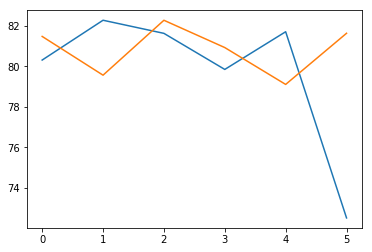

```python
# line plot of observed vs predicted
pyplot.plot(raw_values[-6:])
pyplot.plot(predictions)
pyplot.show()
```

```python
len(test_scaled)
```

```
6
```

```python
for i in range(len(test_scaled)):
    # make one-step forecast
    X, y = test_scaled[i, 0:-1], test_scaled[i, -1]
    yhat = forecast_lstm(lstm_model, 10, X)
    # invert scaling
    yhat = invert_scale(scaler, X, yhat)
    # invert differencing
    yhat = inverse_difference(raw_values, yhat, len(test_scaled)+1-i)
    # store forecast
    predictions.append(yhat)
    expected = raw_values[len(train) + i + 1]
    print('Month=%d, Predicted=%f, Expected=%f' % (i+1, yhat, expected))
```

```
Month=1, Predicted=80.980913, Expected=80.301434
Month=2, Predicted=79.572027, Expected=82.261888
Month=3, Predicted=82.233319, Expected=81.616164
Month=4, Predicted=80.862817, Expected=79.839722
Month=5, Predicted=79.130730, Expected=81.695657
Month=6, Predicted=81.643905, Expected=72.526990
```

We see that the LSTM model performs better than the Neural Network. Hence, we can use this model for forecasting revenue for each cohort.

## To obtain highly accurate revenues for each individual user, we have to build a BG-NBD (Beta Geometric Negative Binomial Distribution) model followed by a Gamma-Gamma model.

```python
df.head()
```

|  | cust_id | last_cycle_dt | zip5_cd | CA_state_cd | NY_state_cd | TX_state_cd | last_pymnt_dt | birth_year | lang_pref_Yes_cnt | lang_pref_No_cnt | ... | data_usage | data_overage | data_overage_amt | total_minutes_used | voice_overage | voice_overage_amt | cust_estb_dt | cust_status_ind | arpu_class | cycle_dt |
| --- | --- | --- | --- | --- | --- | --- | --- | --- | --- | --- | --- | --- | --- | --- | --- | --- | --- | --- | --- | --- | --- |
| 0 | 873284714 | 2017-01-01 | 91204 | 4 | 0 | 0 | 2099-12-31 | 1979 | 0 | 0 | ... | 0.0 | 0.0 | 0.0 | 0.0 | 0.0 | 0.0 | 2017-01-13 | 0 | MEDIUM | 2017-01-01 |
| 1 | 988895414 | 2017-01-01 | 19103 | 0 | 1 | 0 | 2017-01-09 | 1988 | 0 | 0 | ... | 0.0 | 0.0 | 0.0 | 0.0 | 0.0 | 0.0 | 2017-01-07 | 1 | LOW | 2017-01-01 |
| 2 | 625265314 | 2017-01-01 | 75070 | 0 | 0 | 1 | 2099-12-31 | 1984 | 0 | 0 | ... | 0.0 | 0.0 | 0.0 | 0.0 | 0.0 | 0.0 | 2017-01-22 | 1 | MEDIUM | 2017-01-01 |
| 3 | 473291754 | 2017-01-01 | 95219 | 2 | 0 | 0 | 2099-12-31 | 1985 | 0 | 0 | ... | 0.0 | 0.0 | 0.0 | 0.0 | 0.0 | 0.0 | 2017-01-31 | 0 | MEDIUM | 2017-01-01 |
| 4 | 988892955 | 2017-01-01 | 11379 | 0 | 2 | 0 | 2099-12-31 | 1942 | 0 | 0 | ... | 0.0 | 0.0 | 0.0 | 0.0 | 0.0 | 0.0 | 2017-01-03 | 1 | MEDIUM | 2017-01-01 |

5 rows × 131 columns

```python
len(df)
```

```
15516241
```

```python
df_new = df[['cust_id','last_cycle_dt','gl_tot_invoice_amt']]
```

```python
df_new = df_new.rename(columns={"cust_id": "CustomerID", "last_cycle_dt": "InvoiceDate", "gl_tot_invoice_amt": "Sales"})
```

```python
df_new.head()
```

|  | CustomerID | InvoiceDate | Sales |
| --- | --- | --- | --- |
| 0 | 873284714 | 2017-01-01 | 408.75000 |
| 1 | 988895414 | 2017-01-01 | 55.15625 |
| 2 | 625265314 | 2017-01-01 | 181.12500 |
| 3 | 473291754 | 2017-01-01 | 265.50000 |
| 4 | 988892955 | 2017-01-01 | 167.87500 |

```python
df_new = df_new.sort_values(by=['CustomerID', 'InvoiceDate'])
```

```python
df_new = df_new.reset_index()
```

```python
df_new = df_new.drop('index', axis = 1)
```

```python
df_new.head(10)
```

|  | CustomerID | InvoiceDate | Sales |
| --- | --- | --- | --- |
| 0 | 225250927 | 2017-01-01 | 101.3125 |
| 1 | 225250927 | 2017-02-01 | 246.5000 |
| 2 | 225250927 | 2017-03-01 | 164.3750 |
| 3 | 225250927 | 2017-04-01 | 324.0000 |
| 4 | 225250927 | 2017-05-01 | 214.6250 |
| 5 | 225250927 | 2017-06-01 | 213.7500 |
| 6 | 225250927 | 2017-07-01 | 266.5000 |
| 7 | 225250927 | 2017-08-01 | 208.8750 |
| 8 | 225250927 | 2017-09-01 | 222.3750 |
| 9 | 225250927 | 2017-10-01 | 223.5000 |

```python
from lifetimes.plotting import *
from lifetimes.utils import *

data = summary_data_from_transaction_data(df_new, 'CustomerID', 'InvoiceDate', monetary_value_col='Sales', observation_period_end='2018-12-31')
data.head()
```

| CustomerID | frequency | recency | T | monetary_value |
| --- | --- | --- | --- | --- |
| 225250927 | 23.0 | 699.0 | 729.0 | 235.2500 |
| 225250931 | 23.0 | 699.0 | 729.0 | 144.0000 |
| 225250951 | 23.0 | 699.0 | 729.0 | 104.6875 |
| 225250958 | 23.0 | 699.0 | 729.0 | 118.6875 |
| 225250961 | 23.0 | 699.0 | 729.0 | 132.7500 |

```python
data_new = pd.read_csv("Final_table.csv", sep = ',')
```

```python
data_new.head()
```

|  | cust_id | cust_estb_dt | cust_status_ind | recency | frequency | monetary | NewVZPlan_plan_cnt | VerizonUNL_plan_cnt | billed_acct_size | VoiceTextData_pplangrp_cnt | ... | gl_recur_rev_amt | gl_nonrecur_rev_amt | pplan_access_acrtn | tot_revenue_acrtn | access_rev_acrtn | eqp_rev_acrtn | usage_rev_acrtn | data_overage_amt | voice_overage_amt | Customer_Cluster |
| --- | --- | --- | --- | --- | --- | --- | --- | --- | --- | --- | --- | --- | --- | --- | --- | --- | --- | --- | --- | --- | --- |
| 0 | 925381920 | 17/07/22 | 1 | 51 | 25 | 8012.49 | 5 | 0 | 5 | 5 | ... | 3723.20 | 211.53 | 0.0 | -7.20 | 6.04 | -10.14 | 0.00 | 0.0 | 0.0 | Platinum |
| 1 | 825437339 | 17/11/01 | 1 | 51 | 21 | 5977.00 | 0 | 0 | 3 | 3 | ... | 2882.41 | 283.97 | 0.0 | -12.15 | 0.00 | -4.30 | 0.00 | 0.0 | 0.0 | Gold |
| 2 | 689017953 | 17/10/14 | 1 | 51 | 22 | 5842.94 | 0 | 0 | 4 | 4 | ... | 3042.00 | 9.38 | 0.0 | -12.80 | 0.00 | -1.02 | 0.00 | 0.0 | 0.0 | Gold |
| 3 | 373396651 | 17/11/27 | 1 | 51 | 21 | 6018.78 | 0 | 0 | 2 | 2 | ... | 3570.00 | 0.00 | 0.0 | -3.36 | 0.00 | -0.61 | 0.00 | 0.0 | 0.0 | Gold |
| 4 | 588971563 | 17/06/19 | 1 | 51 | 26 | 7135.08 | 4 | 0 | 4 | 4 | ... | 4000.00 | 102.56 | 0.0 | 2.40 | -1.92 | -0.34 | 0.15 | 0.0 | 0.0 | Platinum |

5 rows × 55 columns

```python
data_new.columns
```

```
Index(['cust_id', 'cust_estb_dt', 'cust_status_ind', 'recency', 'frequency',
       'monetary', 'NewVZPlan_plan_cnt', 'VerizonUNL_plan_cnt',
       'billed_acct_size', 'VoiceTextData_pplangrp_cnt',
       'VoiceData_revtype_cnt', 'active_loan_cnt', 'birth_year', 'zip5_cd',
       'Loand_equip_cnt', 'BeyondUnlmtd_plan_cnt', 'GoUnlimit_plan_cnt',
       'IphoneDev_cnt', 'recurring_paychnl_cnt', 'CA_state_cd',
       'Hispanic_ethnicity_cnt', 'data_ovrg_Yes_cnt', 'Edge_contract_cnt',
       'CommunicStore_chnl_cnt', 'AndroidDev_cnt', 'WearablDev_cnt',
       'SingleLine_plan_cnt', 'TX_state_cd', 'ATT_port_cnt',
       'DataOnly_Revtype_cnt', 'MatureAdults_cnt', 'handset_paychnl_cnt',
       'VoiceOnly_pplangrp_cnt', 'SngleCpleKids_cnt', 'FamTeens_cnt',
       'Purch_equip_cnt', 'MTM_contract_cnt', 'T_Mobile_port_cnt',
       'Sprint_port_cnt', 'LocalRetailer_chnl_cnt', 'TwoYear_contract_cnt',
       'BasicDev_cnt', 'arpu_amt', 'gl_late_fees_amt',
       'gl_tot_service_rev_amt', 'gl_recur_rev_amt', 'gl_nonrecur_rev_amt',
       'pplan_access_acrtn', 'tot_revenue_acrtn', 'access_rev_acrtn',
       'eqp_rev_acrtn', 'usage_rev_acrtn', 'data_overage_amt',
       'voice_overage_amt', 'Customer_Cluster'],
      dtype='object')
```

```python
data_new = data_new[['cust_id','recency','frequency','monetary']]
```

```python
data_new = data_new[data_new['frequency'] < 32]
```

```python
data_new['T'] = (data_new['frequency'] * 29) + data_new['recency']
```

```python
data_new.head()
```

[output not shown]

```python
data_new['recency'] = data_new['recency'] - 30
```

```
count    735697.000000
mean         20.259784
std           8.754636
min           1.000000
25%          16.000000
50%          23.000000
75%          27.000000
max          31.000000
Name: frequency, dtype: float64
0.0
```

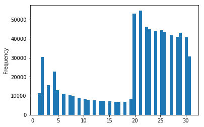

```python
data_new['frequency'].plot(kind='hist', bins=50)
print(data_new['frequency'].describe())
print(sum(data_new['frequency'] == 0)/float(len(data_new)))
```

```python
from lifetimes import BetaGeoFitter

# similar API to scikit-learn and lifelines.
bgf = BetaGeoFitter(penalizer_coef=0.01)
bgf.fit(data_new['frequency'], data_new['recency'], data_new['T'])
print(bgf)
```

```
<lifetimes.BetaGeoFitter: fitted with 735697 subjects, a: 0.49, alpha: 0.72, b: 3.72, r: 0.59>
```

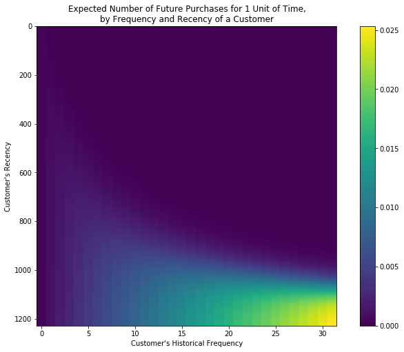

```python
from lifetimes.plotting import plot_frequency_recency_matrix
import matplotlib.pyplot as plt
fig = plt.figure(figsize=(12,8))
plot_frequency_recency_matrix(bgf)
```

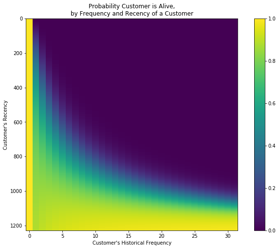

```python
from lifetimes.plotting import plot_probability_alive_matrix
fig = plt.figure(figsize=(12,8))
plot_probability_alive_matrix(bgf)
```

```python
t = 31
data_new['predicted_purchases'] = bgf.conditional_expected_number_of_purchases_up_to_time(t, data_new['frequency'], data_new['recency'], data_new['T'])
data_new.sort_values(by='predicted_purchases').tail(5)
```

|  | cust_id | recency | frequency | monetary | T | predicted_purchases |
| --- | --- | --- | --- | --- | --- | --- |
| 484241 | 388940070 | 21 | 1 | 228.84 | 80 | 0.283979 |
| 45838 | 725364706 | 21 | 1 | 503.72 | 80 | 0.283979 |
| 134903 | 925342331 | 21 | 1 | 243.17 | 80 | 0.283979 |
| 176684 | 825463037 | 21 | 1 | 122.65 | 80 | 0.283979 |
| 687319 | 325451889 | 21 | 1 | 57.88 | 80 | 0.283979 |

```python
data_new['predicted_purchases'].min()
```

```
1.0130573978616478e-50
```

```python
t = 10 #predict purchases in 10 periods
individual = data_new.loc[484241]
# The below function is an alias to `bfg.conditional_expected_number_of_purchases_up_to_time`
bgf.predict(t, individual['frequency'], individual['recency'], individual['T'])
```

```python
df.head()
```

|  | cust_id | last_cycle_dt | zip5_cd | CA_state_cd | NY_state_cd | TX_state_cd | last_pymnt_dt | birth_year | lang_pref_Yes_cnt | lang_pref_No_cnt | ... | data_usage | data_overage | data_overage_amt | total_minutes_used | voice_overage | voice_overage_amt | cust_estb_dt | cust_status_ind | arpu_class | cycle_dt |
| --- | --- | --- | --- | --- | --- | --- | --- | --- | --- | --- | --- | --- | --- | --- | --- | --- | --- | --- | --- | --- | --- |
| 0 | 873284714 | 2017-01-01 | 91204 | 4 | 0 | 0 | 2099-12-31 | 1979 | 0 | 0 | ... | 0.0 | 0.0 | 0.0 | 0.0 | 0.0 | 0.0 | 2017-01-13 | 0 | MEDIUM | 2017-01-01 |
| 1 | 988895414 | 2017-01-01 | 19103 | 0 | 1 | 0 | 2017-01-09 | 1988 | 0 | 0 | ... | 0.0 | 0.0 | 0.0 | 0.0 | 0.0 | 0.0 | 2017-01-07 | 1 | LOW | 2017-01-01 |
| 2 | 625265314 | 2017-01-01 | 75070 | 0 | 0 | 1 | 2099-12-31 | 1984 | 0 | 0 | ... | 0.0 | 0.0 | 0.0 | 0.0 | 0.0 | 0.0 | 2017-01-22 | 1 | MEDIUM | 2017-01-01 |
| 3 | 473291754 | 2017-01-01 | 95219 | 2 | 0 | 0 | 2099-12-31 | 1985 | 0 | 0 | ... | 0.0 | 0.0 | 0.0 | 0.0 | 0.0 | 0.0 | 2017-01-31 | 0 | MEDIUM | 2017-01-01 |
| 4 | 988892955 | 2017-01-01 | 11379 | 0 | 2 | 0 | 2099-12-31 | 1942 | 0 | 0 | ... | 0.0 | 0.0 | 0.0 | 0.0 | 0.0 | 0.0 | 2017-01-03 | 1 | MEDIUM | 2017-01-01 |

5 rows × 131 columns

```python
df_new.head()
```

|  | CustomerID | InvoiceDate | Sales |
| --- | --- | --- | --- |
| 0 | 225250927 | 2017-01-01 | 101.3125 |
| 1 | 225250927 | 2017-02-01 | 246.5000 |
| 2 | 225250927 | 2017-03-01 | 164.3750 |
| 3 | 225250927 | 2017-04-01 | 324.0000 |
| 4 | 225250927 | 2017-05-01 | 214.6250 |

```python
df_new['InvoiceDate1'] = df_new['InvoiceDate']
```

```python
df_new['InvoiceDate2'] = df_new['InvoiceDate']
```

```python
NOW = dt.datetime(2019,8,1)
```

```python
rfmTable = df_new.groupby('CustomerID').agg({'InvoiceDate': lambda x: (NOW - x.max()).days, 'InvoiceDate1': lambda x: len(x), 'Sales': lambda x: x.sum(), 'InvoiceDate2': lambda x: (NOW - x.min()).days})
rfmTable['InvoiceDate'] = rfmTable['InvoiceDate'].astype(int)
rfmTable.rename(columns={'InvoiceDate': 'recency',
                         'InvoiceDate1': 'frequency',
                         'TotalPrice': 'monetary_value',
                        'InvoiceDate2': 'T'}, inplace=True)
```

```python
rfmTable.head()
```

| CustomerID | recency | frequency | Sales | T |
| --- | --- | --- | --- | --- |
| 225250927 | 31 | 31 | 6860.0 | 942 |
| 225250931 | 243 | 24 | 3458.0 | 942 |
| 225250951 | 31 | 31 | 3216.0 | 942 |
| 225250958 | 31 | 31 | 3902.0 | 942 |
| 225250961 | 92 | 29 | 3782.0 | 942 |

```python
len(rfmTable[rfmTable['recency'] > rfmTable['T']])
```

```
0
```

```python
rfmTable = rfmTable[rfmTable['recency'] < rfmTable['T']]
```

```python
rfmTable.head()
```

[output not shown]

```python
from lifetimes import BetaGeoFitter

# similar API to scikit-learn and lifelines.
bgf = BetaGeoFitter(penalizer_coef=0.01)
bgf.fit(rfmTable['frequency'], rfmTable['recency'], rfmTable['T'])
print(bgf)
```

```
<lifetimes.BetaGeoFitter: fitted with 758197 subjects, a: 0.48, alpha: 1.18, b: 3.73, r: 0.67>
```

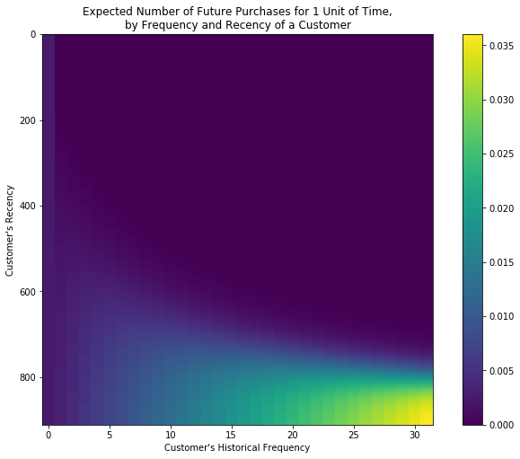

```python
from lifetimes.plotting import plot_frequency_recency_matrix
import matplotlib.pyplot as plt
fig = plt.figure(figsize=(12,8))
plot_frequency_recency_matrix(bgf)
```

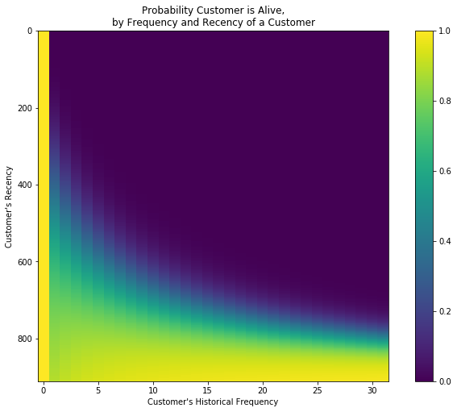

```python
from lifetimes.plotting import plot_probability_alive_matrix
fig = plt.figure(figsize=(12,8))
plot_probability_alive_matrix(bgf)
```

```python
t = 30
rfmTable['predicted_purchases'] = bgf.conditional_expected_number_of_purchases_up_to_time(t, rfmTable['frequency'], rfmTable['recency'], rfmTable['T'])
rfmTable.sort_values(by='predicted_purchases').tail(5)
```

| CustomerID | recency | frequency | Sales | T | predicted_purchases |
| --- | --- | --- | --- | --- | --- |
| 625286630 | 31 | 1 | 218.8750 | 31 | 1.248965 |
| 873313122 | 31 | 1 | 230.7500 | 31 | 1.248965 |
| 225301654 | 31 | 1 | 262.7500 | 31 | 1.248965 |
| 925346363 | 31 | 1 | 67.4375 | 31 | 1.248965 |
| 225466659 | 31 | 1 | 176.6250 | 31 | 1.248965 |

```python
rfmTable.head()
```

| CustomerID | recency | frequency | Sales | T | predicted_purchases |
| --- | --- | --- | --- | --- | --- |
| 225250927 | 31 | 31 | 6860.0 | 942 | 2.442782e-45 |
| 225250931 | 243 | 24 | 3458.0 | 942 | 1.440365e-13 |
| 225250951 | 31 | 31 | 3216.0 | 942 | 2.442782e-45 |
| 225250958 | 31 | 31 | 3902.0 | 942 | 2.442782e-45 |
| 225250961 | 92 | 29 | 3782.0 | 942 | 9.252556e-29 |

The BG-NBD model does not make good predictions. We can thus conclude that it is not the right fit for subscription based service.

## We thus have LSTM model that performs the best when compared to ANN, SVM and BG-NBD models.

```python
df.head()
```

| cust_id | last_cycle_dt | zip5_cd | CA_state_cd | NY_state_cd | TX_state_cd | last_pymnt_dt | birth_year | lang_pref_Yes_cnt | lang_pref_No_cnt | late_fee_sprss_Yes_cnt | ... | data_usage | data_overage | data_overage_amt | total_minutes_used | voice_overage | voice_overage_amt | cust_estb_dt | cust_status_ind | arpu_class | cycle_dt |
| --- | --- | --- | --- | --- | --- | --- | --- | --- | --- | --- | --- | --- | --- | --- | --- | --- | --- | --- | --- | --- | --- |
| 873284714 | 2017-01-01 | 91204 | 4 | 0 | 0 | 2099-12-31 | 1979 | 0 | 0 | 4 | ... | 0.0 | 0.0 | 0.0 | 0.0 | 0.0 | 0.0 | 2017-01-13 | 0 | MEDIUM | 2017-01-01 |
| 988895414 | 2017-01-01 | 19103 | 0 | 1 | 0 | 2017-01-09 | 1988 | 0 | 0 | 0 | ... | 0.0 | 0.0 | 0.0 | 0.0 | 0.0 | 0.0 | 2017-01-07 | 1 | LOW | 2017-01-01 |
| 625265314 | 2017-01-01 | 75070 | 0 | 0 | 1 | 2099-12-31 | 1984 | 0 | 0 | 0 | ... | 0.0 | 0.0 | 0.0 | 0.0 | 0.0 | 0.0 | 2017-01-22 | 1 | MEDIUM | 2017-01-01 |
| 473291754 | 2017-01-01 | 95219 | 2 | 0 | 0 | 2099-12-31 | 1985 | 0 | 0 | 2 | ... | 0.0 | 0.0 | 0.0 | 0.0 | 0.0 | 0.0 | 2017-01-31 | 0 | MEDIUM | 2017-01-01 |
| 988892955 | 2017-01-01 | 11379 | 0 | 2 | 0 | 2099-12-31 | 1942 | 0 | 0 | 0 | ... | 0.0 | 0.0 | 0.0 | 0.0 | 0.0 | 0.0 | 2017-01-03 | 1 | MEDIUM | 2017-01-01 |

5 rows × 130 columns

```python
ts=df[['last_cycle_dt','gl_tot_invoice_amt']]
```

```python
ts.head()
```

[output not shown]

```python
ts=ts.reset_index()
```

```python
ts['gl_tot_invoice_amt'] = ts['gl_tot_invoice_amt'].astype(np.float64)
```

```python
ts.head()
```

[output not shown]

```python
ts=ts.groupby(["last_cycle_dt"])["gl_tot_invoice_amt"].sum()
```

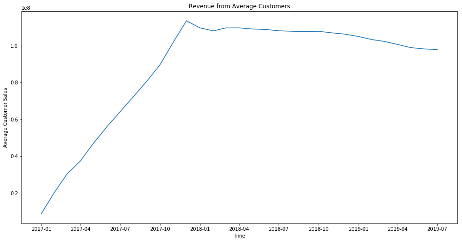

```python
ts.astype('float')
plt.figure(figsize=(16,8))
plt.title('Revenue from Average Customers')
plt.xlabel('Time')
plt.ylabel('Average Customer Sales')
plt.plot(ts);
```

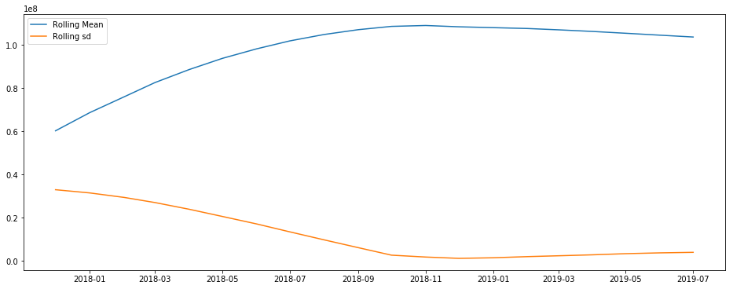

```python
plt.figure(figsize=(16,6))
plt.plot(ts.rolling(window=12,center=False).mean(),label='Rolling Mean');
plt.plot(ts.rolling(window=12,center=False).std(),label='Rolling sd');
plt.legend();
```

Let's check that with a quick decomposition into Trend, seasonality and residual

### Multiplicative model

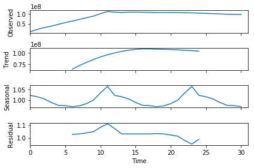

```python
import statsmodels.api as sm
# multiplicative
res = sm.tsa.seasonal_decompose(ts.values,freq=12,model="multiplicative")
#plt.figure(figsize=(16,12))
fig = res.plot()
#fig.show()
```

### Additive model

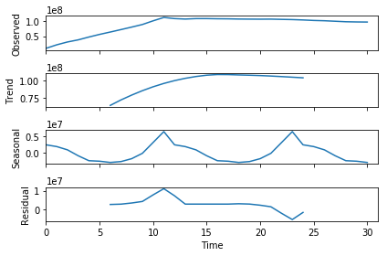

```python
res = sm.tsa.seasonal_decompose(ts.values,freq=12,model="additive")
#plt.figure(figsize=(16,12))
fig = res.plot()
#fig.show()
```

we assume an additive model, then we can write

yt=St+Tt+Et

where:-

yt is the data at period t,  
St is the seasonal component at period t,  
Tt is the trend-cycle component at period tt and  
Et is the remainder (or irregular or error) component at period t

Similarly for Multiplicative model, yt=St x Tt x Et

```python
from statsmodels.tsa.stattools import adfuller, acf, pacf,arma_order_select_ic
import statsmodels.formula.api as smf
import statsmodels.tsa.api as smt
import statsmodels.api as sm
import scipy.stats as scs

# Stationarity tests
def test_stationarity(timeseries):

    #Perform Dickey-Fuller test:
    print('Results of Dickey-Fuller Test:')
    dftest = adfuller(timeseries, autolag='AIC')
    dfoutput = pd.Series(dftest[0:4], index=['Test Statistic','p-value','#Lags Used','Number of Observations Used'])
    for key,value in dftest[4].items():
        dfoutput['Critical Value (%s)'%key] = value
    print (dfoutput)

test_stationarity(ts)
```

```
Results of Dickey-Fuller Test:
Test Statistic                 -2.821560
p-value                         0.055259
#Lags Used                      3.000000
Number of Observations Used    27.000000
Critical Value (1%)            -3.699608
Critical Value (5%)            -2.976430
Critical Value (10%)           -2.627601
dtype: float64
```

```python
# to remove trend
from pandas import Series as Series
# create a differenced series
def difference(dataset, interval=1):
    diff = list()
    for i in range(interval, len(dataset)):
        value = dataset[i] - dataset[i - interval]
        diff.append(value)
    return Series(diff)

# invert differenced forecast
def inverse_difference(last_ob, value):
    return value + last_ob
```

[output not shown]

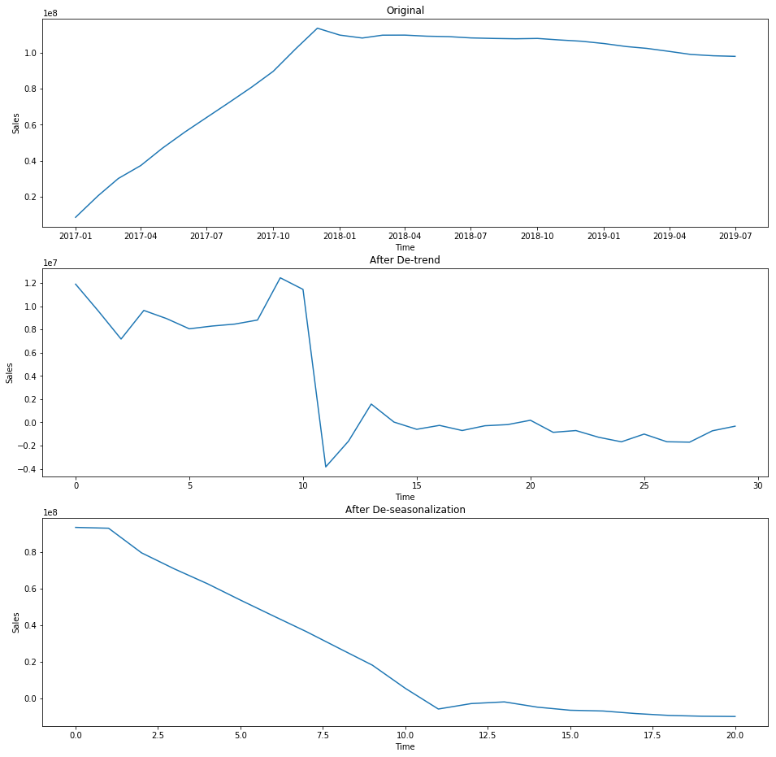

```python
ts=df[['last_cycle_dt','gl_tot_invoice_amt']]
ts = ts.reset_index()
ts['gl_tot_invoice_amt'] = ts['gl_tot_invoice_amt'].astype(np.float64)
ts=ts.groupby(["last_cycle_dt"])["gl_tot_invoice_amt"].sum()

ts.astype('float')
plt.figure(figsize=(16,16))
plt.subplot(311)
plt.title('Original')
plt.xlabel('Time')
plt.ylabel('Sales')
plt.plot(ts)
plt.subplot(312)
plt.title('After De-trend')
plt.xlabel('Time')
plt.ylabel('Sales')
new_ts=difference(ts)
plt.plot(new_ts)
plt.plot()

plt.subplot(313)
plt.title('After De-seasonalization')
plt.xlabel('Time')
plt.ylabel('Sales')
new_ts=difference(ts,10)       # assuming the seasonality is 12 months long
plt.plot(new_ts)
plt.plot()
```

```python
# now testing the stationarity again after de-seasonality
test_stationarity(new_ts)
```

```
Results of Dickey-Fuller Test:
Test Statistic                 -0.000000
p-value                         0.958532
#Lags Used                      9.000000
Number of Observations Used    11.000000
Critical Value (1%)            -4.223238
Critical Value (5%)            -3.189369
Critical Value (10%)           -2.729839
dtype: float64
```

## AR, MA and ARMA models:

```python
def tsplot(y, lags=None, figsize=(10, 8), style='bmh',title=''):
    if not isinstance(y, pd.Series):
        y = pd.Series(y)
    with plt.style.context(style):
        fig = plt.figure(figsize=figsize)
        #mpl.rcParams['font.family'] = 'Ubuntu Mono'
        layout = (3, 2)
        ts_ax = plt.subplot2grid(layout, (0, 0), colspan=2)
        acf_ax = plt.subplot2grid(layout, (1, 0))
        pacf_ax = plt.subplot2grid(layout, (1, 1))
        qq_ax = plt.subplot2grid(layout, (2, 0))
        pp_ax = plt.subplot2grid(layout, (2, 1))

        y.plot(ax=ts_ax)
        ts_ax.set_title(title)
        smt.graphics.plot_acf(y, lags=lags, ax=acf_ax, alpha=0.5)
        smt.graphics.plot_pacf(y, lags=lags, ax=pacf_ax, alpha=0.5)
        sm.qqplot(y, line='s', ax=qq_ax)
        qq_ax.set_title('QQ Plot')
        scs.probplot(y, sparams=(y.mean(), y.std()), plot=pp_ax)

        plt.tight_layout()
    return
```

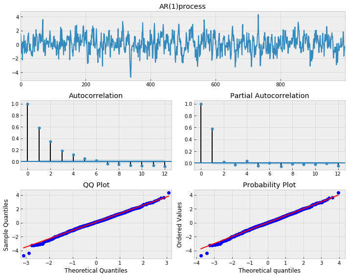

```python
# Simulate an AR(1) process with alpha = 0.6
np.random.seed(1)
n_samples = int(1000)
a = 0.6
x = w = np.random.normal(size=n_samples)

for t in range(n_samples):
    x[t] = a*x[t-1] + w[t]
limit=12
_ = tsplot(x, lags=limit,title="AR(1)process")
```

### AR(1) process -- has ACF tailing out and PACF cutting off at lag=1

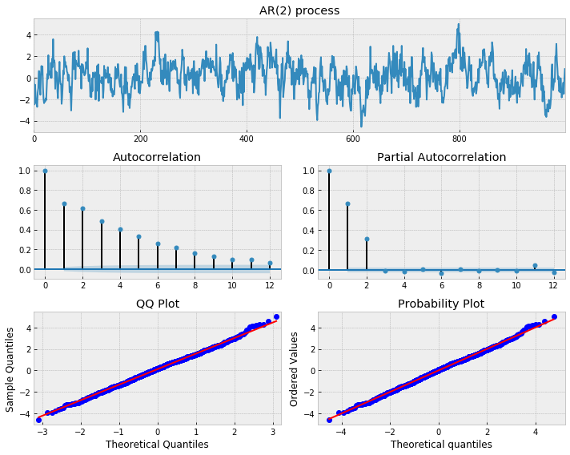

```python
# Simulate an AR(2) process

n = int(1000)
alphas = np.array([.444, .333])
betas = np.array([0.])

# Python requires us to specify the zero-lag value which is 1
# Also note that the alphas for the AR model must be negated
# We also set the betas for the MA equal to 0 for an AR(p) model
# For more information see the examples at statsmodels.org
ar = np.r_[1, -alphas]
ma = np.r_[1, betas]

ar2 = smt.arma_generate_sample(ar=ar, ma=ma, nsample=n)
_ = tsplot(ar2, lags=12,title="AR(2) process")
```

### AR(2) process -- has ACF tailing out and PACF cutting off at lag=2

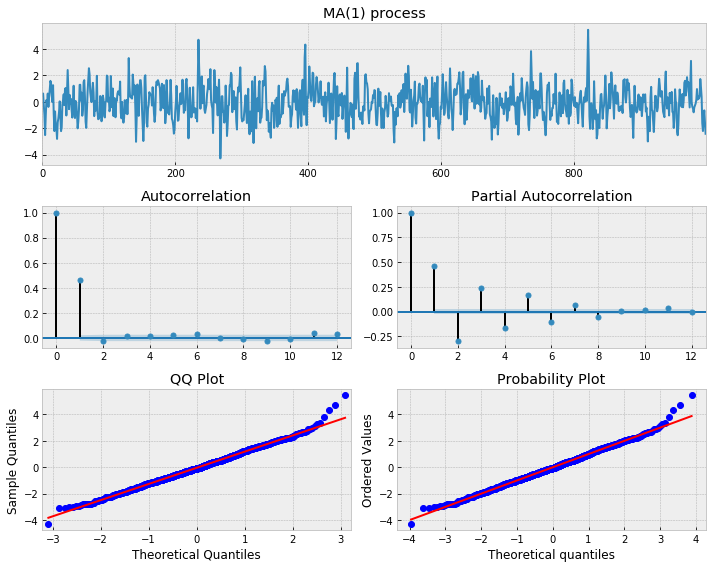

```python
# Simulate an MA(1) process
n = int(1000)
# set the AR(p) alphas equal to 0
alphas = np.array([0.])
betas = np.array([0.8])
# add zero-lag and negate alphas
ar = np.r_[1, -alphas]
ma = np.r_[1, betas]
ma1 = smt.arma_generate_sample(ar=ar, ma=ma, nsample=n)
limit=12
_ = tsplot(ma1, lags=limit,title="MA(1) process")
```

### MA(1) process -- has ACF cut off at lag=1

```python
#
# pick best order by aic
# smallest aic value wins
best_aic = np.inf
best_order = None
best_mdl = None

rng = range(5)
for i in rng:
    for j in rng:
        try:
            tmp_mdl = smt.ARMA(new_ts.values, order=(i, j)).fit(method='mle', trend='nc')
            tmp_aic = tmp_mdl.aic
            if tmp_aic < best_aic:
                best_aic = tmp_aic
                best_order = (i, j)
                best_mdl = tmp_mdl
        except: continue


print('aic: {:6.5f} | order: {}'.format(best_aic, best_order))
```

```
aic: 713.52469 | order: (2, 0)
```

```python
# adding the dates to the Time-series as index
ts=df[['last_cycle_dt','gl_tot_invoice_amt']]
ts = ts.reset_index()
ts['gl_tot_invoice_amt'] = ts['gl_tot_invoice_amt'].astype(np.float64)
ts=ts.groupby(["last_cycle_dt"])["gl_tot_invoice_amt"].sum()

ts.index=pd.date_range(start = '2017-01-01',end='2019-07-30', freq = 'MS')
ts=ts.reset_index()
ts.head()
```

|  | index | gl_tot_invoice_amt |
| --- | --- | --- |
| 0 | 2017-01-01 | 8.645744e+06 |
| 1 | 2017-02-01 | 2.055926e+07 |
| 2 | 2017-03-01 | 3.015727e+07 |
| 3 | 2017-04-01 | 3.734144e+07 |
| 4 | 2017-05-01 | 4.699182e+07 |

## Prophet:

Recently open-sourced by Facebook research. It's a very promising tool, that is often a very handy and quick solution

```python
from fbprophet import Prophet
#prophet reqiures a pandas df at the below config
# ( date column named as DS and the value column as Y)
ts.columns=['ds','y']
model = Prophet( yearly_seasonality=True) #instantiate Prophet with only yearly seasonality as our data is monthly
model.fit(ts) #fit the model with your dataframe
```

```
INFO:fbprophet:Disabling weekly seasonality. Run prophet with weekly_seasonality=True to override this.
INFO:fbprophet:Disabling daily seasonality. Run prophet with daily_seasonality=True to override this.
INFO:fbprophet:n_changepoints greater than number of observations.Using 23.
```

```
<fbprophet.forecaster.Prophet at 0x23ebe59d630>
```

```python
# predict for five months in the furure and MS - month start is the frequency
future = model.make_future_dataframe(periods = 12, freq = 'MS')
# now lets make the forecasts
forecast_avg = model.predict(future)
forecast_avg[['ds', 'yhat', 'yhat_lower', 'yhat_upper']].tail(12)
```

|  | ds | yhat | yhat_lower | yhat_upper |
| --- | --- | --- | --- | --- |
| 31 | 2019-08-01 | 1.586008e+08 | 1.373299e+08 | 1.793721e+08 |
| 32 | 2019-09-01 | 1.563837e+08 | 1.351459e+08 | 1.774130e+08 |
| 33 | 2019-10-01 | 1.486289e+08 | 1.269283e+08 | 1.708788e+08 |
| 34 | 2019-11-01 | 1.302784e+08 | 1.092191e+08 | 1.509628e+08 |
| 35 | 2019-12-01 | 1.101071e+08 | 8.901064e+07 | 1.322557e+08 |
| 36 | 2020-01-01 | 1.697557e+08 | 1.487673e+08 | 1.907435e+08 |
| 37 | 2020-02-01 | 1.531456e+08 | 1.314350e+08 | 1.737391e+08 |
| 38 | 2020-03-01 | 1.324356e+08 | 1.122300e+08 | 1.529156e+08 |
| 39 | 2020-04-01 | 1.418875e+08 | 1.196610e+08 | 1.628194e+08 |
| 40 | 2020-05-01 | 1.531429e+08 | 1.339328e+08 | 1.727757e+08 |
| 41 | 2020-06-01 | 1.618883e+08 | 1.400541e+08 | 1.812340e+08 |
| 42 | 2020-07-01 | 1.694870e+08 | 1.480849e+08 | 1.893883e+08 |

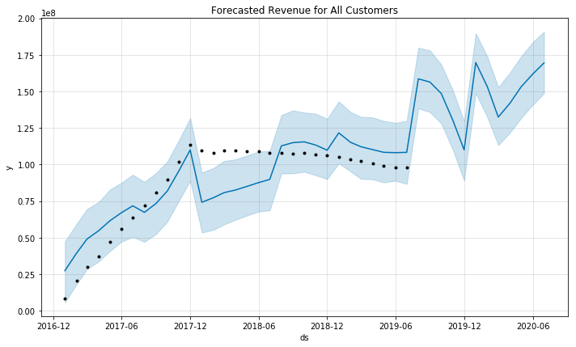

```python
model.plot(forecast)
plt.title("Forecasted Revenue for All Customers")
```

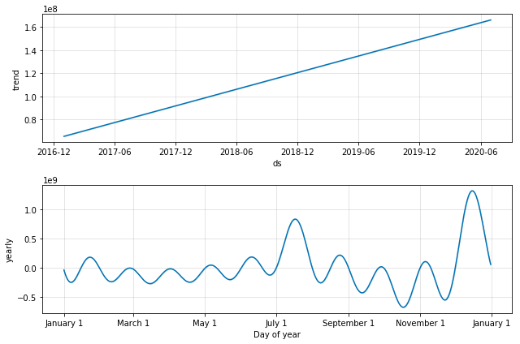

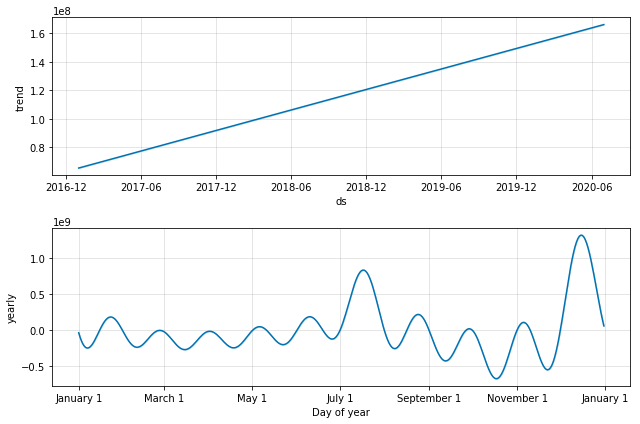

```python
model.plot_components(forecast)
```